# From Recipes Found, Borrowed, Stolen or Developed by Annette Gall ; )

by Annette Rashid Gall

*Compiled by Megan on May 24, 2019*

*See end notes for full list of recipes.*

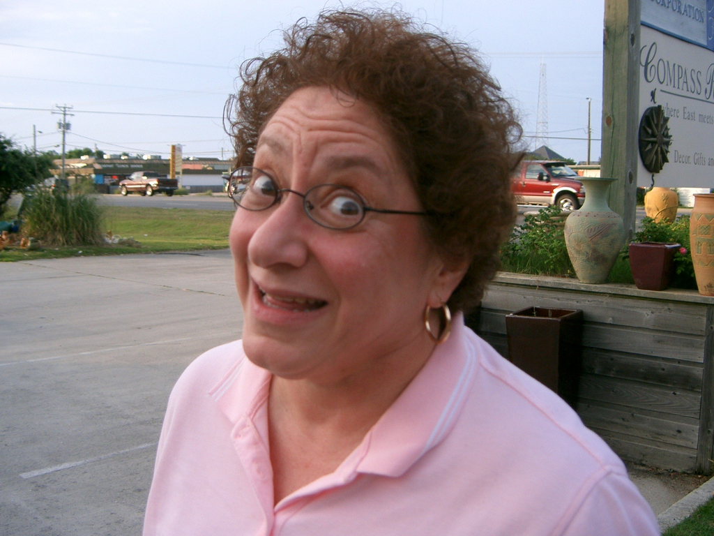

# Almonds, glazed

```
 2 cups whole almonds
 1 cup sugar
 4 tablespoon butter
```

- combine and melt over low heat, stirring constantly til almonds are coated and sugar is golden brown, about 15 minutes. stir in 1/2 teaspoon vanilla. spread nuts on foil. cool and break into clusters.

# appetizer- antipasta sandwich

from the files of recipes developed or otherwise stolen by annette r. gall

```
 1 loaf unsliced good bread
 pesto
 calamata olives
 sun dried tomatoes in oil
 provolone cheese
 roasted peppers
 artichokes
 gardinare
```

- cut top off bread and hollow out. layer ingredients chopping as necessary. place top on bread and let stand. cut and serve.

# appetizer- Artichoke dip

```
 1 can (14 oz.) artichoke hearts drained, chopped
 1 cup mayonaise
 1 cup parmesan cheese
 1 can (4 oz.) chopped green chilis, drained
 1 garlic clove, minced
```

# appetizer- artichoke dip michele from olive garden

Spinach Artichoke Dip from the recipes either stolen or developed by Annette R. Gall

```
 1 cup chopped artichoke hearts
 1/2 cup frozen chopped spinach, thawed and squeezed
 8 ounces cream cheese
 1/2 cup grated parmesan cheese
 1/2 teaspoon crushed red pepper flakes
 1 small garlic clove, crushed
 ground pepper
```

- combine ingredients and heat. serve with crackers, chips or toasted bread.

ok, ok, i left out tedious directions and changed garlic salt to fresh garlic.

# appetizer- caviar torte

this is compiled from several recipes from lenore. we used it at chilton house a lot.

```
 cream cheese layer-
 8 oz. cream cheese
 1/4      cup sour cream
 1 1/2 teaspoon fresh dill
 3 Tablespoons green onion
 3 Tablespoon ground nuts, toasted


 egg layer-
 2 Tablespoons mayonaise
 2 Tablespoons sour cream
 1 1/2 teaspoon dijon mustard
 1/8 teaspoon ground red pepper
 5 hard cooked eggs
 2 Tablespoons green onion
 2 oz. red caviar, drained
```

- mix cream cheese layer reserving green onion. spread 6 inches round and 1 inch tall on serving plate. sprinkle with green onions and nuts.
- seive egg yolks and reserve.
- chop egg whites and stir into mayonaise, sour cream, dijon, and red pepper. spoon over green onion layer, cover and refrigerate until serving time.
- before serving, arrange green onions in center, egg yolks around it, and caviar on outside ring. it looks like a pretty target.

lenore serves it in a wedge on lettuce or grape leaves. my wedges never came out that neat!

# appetizer- cheese, pimento lenore

cheese, pimento lenore

```
 1/2 pound cheddar cheese or longhorn
 1/2 pound aged charp cheddar
 7 oz can pimentos(roasted red peppers)
 1 cup scallions
 1/2 cup mayonaise
 2 Tablespoons lemon juice
 1 teaspoon garlic
 2 Tablespoons worchestershire
 6 dashes tabasco
 1 teaspoon pepper
```

- grind cheese. add 1/2 the juice from pimentos. add rest of ingredients and blend. serve with crackers or vegetables.

i make this all in the cuisinart. put cheeses and garlic in first and process. add rest of ingredients except pimentos and process to mix. add pimentos last so they do not break down completely.

# appetizer- cheeseball, islander

```
 16 oz crean cheese
 8 oz. crushed pineapple, drained
 2 Tablespoon chopped green onions
 1/2 green pepper
 2 Tablespoons seasoned salt
 2 cups pecans, toasted
```

- mix all ingredients except 1 1/2 cups of the pecans. roll ball in remaining pecans. serve with crackers.

# appetizer- crabmeat mold

```
 8 oz can crabmeat
 1 package (1 Tablespoon) gelatin
 10-1/2 can undilluted cream of mushroom soup
 6 oz. cream cheese
 1 cup finely chopped celery
 1 cup finely chopped green or red onion
 1 cup mayonaise
 2 Tablespoons fresh lemon juice
```

- drain and pick crab, reserving juice. measure juice and add water to make 3 tablespoons liquid. dissolve gelatin in this liquid. heat the undiluted soup. add the cream cheese. remove from heat and stir until cheese ismelted. beat until smooth. add celery, onion, crabmeat, and lemon juice. stir to blend. pour into a ring mold (about 4 cup size) and refrigerate until firm.
- unmold and serve with crackers.
- this may be frozen and served as a dip. stir to blend.

# appetizer- Cured garlic

```
 6 large heads garlic
 1/2 cup dark soy sauce
 1/2 cup sweet sherry or red wine
 1/2 cider vinegar
 1/4 cup sugar
```

- separate cloves but do not remove the peel.
- measure rest of ingredience into a small pot and stir to dissolve sugar, add garlic cloves and slowly bring to a boil, stirring occassionaly. let simmer vigorously 1 minutes, then pour into a loarge jar. cool , cover and let marinade at room temperature for 2 days. then chill for about 20 before eating. the garlice keeps indefinitely and the flavor improves as time goes on.
- eat whole or mince and mix with own sauce as seasoning dip for meat. sauce may be used over and over, adding sauce ingredients or garlic as needed.

# appetizer- dip, cauliflower Claudette

```
 1 cup mayonaise
 1 teapspoon tarragon vinegar
 1 small grated onion or 4-6 chopped green onions
 1 teaspoon horseradish
 1/2 teaspoon curry powder
```

# appetizer- dip, hot beef iris

```
 1/4 cup green onions
 1 tablespoon butter
 8-12 oz cream cheese
 1 + cup milk
 4 oz mushrooms
 2 1/2 oz. smoked beef (dried beef), chopped
 1/4 cup parmesan cheese
 2 tablespoons parsley
 1 tabeslpoon horseradish
```

- saute mushrooms in butter. add cream cheese and milk. stir over low heat until cheese in melted. stir in remaining ingredients, heat thoroughly. serve hot with corn chips.

# appetizer- hummus

```
    16 ounces tahini
    1 1/2 cup lemon juice
    1 cup hot water
    1 tablespoon salt
    3 cloves garlic
    3 tablespoons hot sauce (tobasco) or less to taste
    3 cans garbanza beans, drained ( total ounces around 50)
```

- in processor, mix well tahini, lemon juice and water. add rest of ingredients and process until smooth.

you may need to add water after the hummus sits for awhile.

# appetizer- marinated feta cheese with lemon and shallot

from the recipe files deveolped or otherwise stolen by annette

```
 1 1/4 cup olive oil
1 medium shallot
 1 tablespoon minced fresh oregano
 1 teaspoon grated lemon zest from 1 lemon
 1/4 red pepper flakes
 8 oz. feta cheese, cut into 1/2 inch cubes
```

- makes 2 1/2 cups- serve with wedges of warm pita or slices of baggete. even after feta has been eatenm the remaining oil is great for dipping.
- cook 1 cup oil, shallot, lemon zest, and pepper flakes in small saucepan over low hear until shallots are softened, about 18 minutes.
- remove pan from heat and stir in feta. cover and let sit until mixture reaches room temp, about 1 1/2 hours.
- stir in remaining 1/4 cup oil and serve. (mixture can be tranferred to an airtight container and refrigerated for up to 1 week. before, serving, let sit at room temp util oil melts, about 1 hour.

note- yummy. i only used 1/4 cup oil. using the entire amount of oil called for would be great for dipping at dinner but a lot for a few people.

# appetizer- mushroom filing for appetizer sized toasts or something

```
 1 large onioon
 1/2 pound mushrooms, minced
 3 Tablespoons butter
 1/2 teaspoon salt
 1/4 teaspoon thyme
 2 Tablespoons flour
 1/4 cup sour cream
```

- saute` onion and mushrooms in butter. add remainning ingredients except sour cream, and cook until thickened. stir in sour cream.

this is wonderful as a sstuffing in filet mignon. use the whole filet. slice halfway through longwise, fill with mushrooms, tie into round again. oil the outside of filet with olive oil and any herbs you want. cokk at 500 degrees for 18 minutes for rare. let set 115 minutes befoore cutting for better slices.

# appetizer- mushrooms, becky goodwin’s

```
 1 quart burgundy wine
 1 pound butter
 4 pounds mushrooms, whole
 dill
 accent
```

- combine and cook 4 hours covered and 2 hours uncovered. serve hot.

# appetizer- olive garden hot artichoke dip, michele

```
 1 cup chopped artichole hearts (canned of frozen)
 1/2 cup frozen chopped spinach, thawed
 8 oz. cream cheese (can use reduced fat)
 1/2 cup grated parmesan cheese
 1/2 tsp. crushed red pepper flakes
 1/4 teaspoon salt
small garlic clove, cushed
 dash ground pepper
```

- boil spinach and heart. (i would not do this, just press out excess moisture)
- warm cream cheese.
- add spinach and actichoke hearts and stir well.
- add remaining ingredients to the cream cheese and combine.
- serve hot 0with crackers, chips or toasted bread for dipping.

# appetizer- red wine biscotti

```
 2 1/2 cups flour
 1/3 cup sugar
 1 tsp. salt
 1 1/2 teaspoons freshly ground pepper
 1 1/2 tsp. baking powder
 1/2 cup red wine
 1/2 cup oil
```

- in mixing bowl, combine flour, salt, pepper and baking powder. add wine and oil and mix until it just forms a dough. place on ungreased sheet by teaspoonsful and bake 20-30 minutes at 325- or until bottoms are golden.

makes 25 pieces.

# appetizer- tgi fridays 9 layer dip

```
 2/3 cup sour cream
 1/8 teaspoon cumin
 1/8 teaspoon cayenne pepper
 1/8 teaspoon paprika
 dash salt
 16 oz. canned refried beans
 1 cup cheddar cheese
 1/2 cup guacamole
 1/4 cup sliced black olives
 2 green onions. 1/4 cup
 1 medium tomato, chopped
 1 teasppon fresh cilantro
```

- combine sour ream with spices and set aside.
- heat refried beans and spread over the cneter of a serving platter or in a shallow dish.
- sprinkle half the cheese over the beans.
- spread guacamole over cheese.
- then sliced olives.
- then sour cream.
- then green onions and tomatoes and reamining cheese- clilantro is desired.
- serve with tortillas chips and a side of salsa.

# appetizers- liver pate. Mae’s grandmothers, french country

```
1 pound chicken livers
 white wine
 onion
 1/2 pound butter
 1/2 ham
 herbs
```

- simmer livers and onions in white wine just until pink is almost gone from the middle of the livers. drain off wine and most of the onion. process with ham, butter and herbs. keep refrigerated. does not freeze well.

if this is going to be left out in the air, i cover with a wine gelaten to keep it from turning dark.

# appetizers- mushrooms, stuffed

```
    18 medium mushrooms
    3 oz cream cheese
    1/4 cup parmesan cheese
    1 green onion, minced
    sliced almonds
```

- beat softened cream cheese with parmesan and onion. fill mushroom caaps with cheese mixture. top each with sliced almond. bake at 350 degrees for 15 minutes or until the tops are lightly browned. serve immediately.

# appetizers- Oysters Rockefeller

House favorite at Chilton House Restaurant

```
 spinach topping
 1/2 cup butter
 2 pounds spinach
 1 large garlic clove
 1 teaspoon fennel
 1 teaspoon kosher or sea salt
 1 teaspoon freshly ground black pepper

 bacon

 oysters
```

- Wash spinach and wilt in pan or microwave. Process with other ingredients until smooth. can be frozen at this point/
- Place oysters on spinach mixture in a casserole or on individual shells. Top with small piece of bacon. (Can be frozen at this point but i like the oysters better not frozen. Thaw before continuing.)
- At serving time, place under broiler until bacon is crisp. Top with hollandaise sauce and garnish with lemon wedges.

# appetizers- sausage cheese balls

```
 1 pound sausage
 1 pound sharp cheddar cheese, shredded
 3 cups Bisauick
```

- mix ingredients.
- roll into balls the size of large marbels.
- bake at 350 degrees for 15 minutes or until golden.

100 balls - freeze well after baking.

# asparagus- newspaper

```
 1 pound pencil- thin asparagus
 2 Tablespoons butter
 salt and pepper
```

- preheat oven to 450.
- rinse, pat dry and break off tough ends of asparagus.
- arrange in a 13X9 inch glass or ceramic baking dish- 1 or 2 layers.
- melt butter and drizzle over asparagus. season wtih salt and pepper
- cover dish snuggly and bake until crisp tender, about 15 minutes. serve at once.

recipe doubles or triples. just be sure asparagus is no more than a layer or tow thick or it will not cook evenly. use a second pan if necessary.

# Asparagus, baked

great for do ahead

```
 1 1/2 pounds fresh asparagus
 3 Tabespoons butter, melted
 1 Tablespoon fresh lemon juice
 1/4 teaspoon freshly ground pepper
 1/2 cup parmesan cheese
```

- wash asparagus and break off tough ends.
- steam asparagus for 3 minutes after water returns to boil. drain and run under cold water.
- brush oven proof dish with 1 Tablesoon butter. lay asparagus in dish.
- top with remaining butter, lemon juice and parmesan cheese. refrigerate until time to use.
- at serving time, bring casserole to room temperature if possible. preheat oven to 400 degrees. and bake uncovered for 5-10 minutes until bubbling and hot.

# asparagus, spicey seseme

```
 1 pound asparagus
 1 teaspoon seseme seeds
 2 tablespoons olive oil
 4 cloves garlic, minced
 1 tablespoon lemon juice
 1/2 teaspoon red pepper flakes
 1/4 teaspoon salt
```

- clean and snap off tough ends of asparagus.
- heat a dry skillet over medium heat and toast seseme seeds until fragrant, about 5 minutes.
- heat oil in skillet over medium heat. add asparagus and saute’ until crisp-tender, 3-5 minutes. add garlic, lemon juice, red pepper, salt and seseme seeds. saute’ for 30 seconds. serve immediately. serves 4

# baba ganoush by richie

```
 1 lemon per eggplant
 3 tablespoons tahini
 garlic spread- 1 heaping tsp for 3 eggplants
 salt
```

- garlic spread- 1/1 oil to garlic? plus 1 lemon and salt

# bath salts

3 cups epsom salts 1 tablespoon glycerin essential oils or perfume

combine and stir well. some add food coloring (yech!).

# bean soup- 15 bean soup

```
 1 pound ham, ham hocks or smoked sausage
 1 cup onion chopped
 15 oz diced tomatoes
 1 tsp. chili powder
 juice of one lemon
 1-2 cloves garlic
```

- saok beans overnight in 2 quarts water. add meat and bring to boil. reduce heat and simmer uncovered for 2 1/2 hours.
- add rest of ingredients and simmer 1/2 hour more.
- yeild 3 quarts, 14-16 servings???

from bag-o-beans.

# beef burgundy

```
 2 pounds beef cubes for soup or stew
 1 package onion soup mix
 1 can cream of mushroom soup
 3/4 cup dry burgundy wine
 mushrooms
 onions
```

- cook covered for 5 hours. add mushrooms and onions for last hour.
- when making large quantities, the sauce need not be increased as much as the meat.

# beer- with lime

```
2 coronas

1/2 cup limaide concentrate

1 cup + tequilla

ice
```

# biscotti, cranberry

```
2 1/2 cups flour
1 teaspoon baking powder
1/2 teaspoon salt
1 1/2 cups sugar
3 large eggs
1 Tablespoon vegetable oil
1/2 teaspoon almond extract ( i used vanilla)
1 1/2 cups dried cranberries
1 egg white
12 oz white chocolate
```

- preheat oven 350 degrees/ line baking pan with parchment papaer.
- combone flour, baking powder, salt, sugar in bow.. whisk to blend
- in separate bowl beat the eggs with a fork until fofamy. add the oil and almond extract.
- combine the egg mixture with the flour mixture, mixing by hand until all ingredients are moisened. add cranberries. stir to combine.
- divid dough in half. using floured hands, shape each halot into 2 1/2 inches wide and 9 inch long, i inch high logs. transfer to prepared baking sheet and brush egg white on top and sides,.
- bake logs until golden brown. about 35 minutes. cool completely
- using serrated knife, cut logs diagonally into 1/2 inch slices.. arrange slices on bakin gshee. bake 10 minutes, turn biscotti over. bake another 5 nminutes. turn oven off, open door slightly and let biscotti sit for an hour. transfer to rack to cool.
- melt whit echocolate. dip one side of each biscotti into chocolate. lay chocolate side down on wax paper and let sit.

# biscotti, red wine

```
5 cups flour
2/3 cups sugar
2 tablespoons salt
1 tablespoon black pepper
1 tablespoon baking powder
1 red wine
1 cup oil
```

- in mixing bowl, mix flour, sugar, salt, pepper and baking powder. add wine and oil and mix until it just forms a dough. this should make 50 pieces. place on ungreased sheet and bake 20-30 minutes at 325 degrees or until bottoms are golden.

# biscuits, cream cheese

```
1/4 pound butter
1 cup flour
8 oz cream cheese
1/2 teaspoon salt
```

- mix all ingredients and pat out on floured board. cut in bite sized pieces and place on cookie sheet.
- bake at 450 degrees about 12 minutes. makes about 60.

# bread- corn bread

Top Secret Recipes version of Chevys® Sweet Corn Tomalito by Todd Wilbur

```
4 cups frozen corn, thawed
1/3 cup butter, softened
1/2 cup granulated sugar
```

3/4 cup milk 1/2 cup masa harina 1/2 cup corn meal 1/2 teaspoon baking powder 1/2 teaspoon salt

1. Preheat oven to 325 degrees.
2. Cream softened butter together with sugar in a large bowl with an electric mixer until smooth. Add milk and masa and mix well.
3. Use a blender or food processor to puree 2 cups of corn until smooth. Add pureed corn to butter/masa mixture and mix well. Add corn meal, baking powder, salt and remaining corn and mix until combined.
4. Pour mixture into an ungreased 8x8-inch baking pan. Cover with foil and place it into a 9x13-inch baking pan. Add hot water to the larger baking pan until it’s about 1/3 full. Bake for 1 1/2 to 2 hours or until corn cake is firm in the center. Let it sit covered for 10 minutes before serving. To serve, scoop out about a 1/2 cup portion with a large spoon.

Makes 8 servings.

Other Mexican food chains such as Chi-Chi’s and El Torito call it “Sweet Corn Cake.” But at Chevy’s, the corn-filled, pudding-like stuff that’s served with most entrees is known as “Tomalito.” That masa harina in there (corn flour) is what’s used to make tamales, and it can be found in your supermarket either with the corn meal and flour, or wherever the other Mexican/Spanish items are stocked. Everything else here is basic stuff. While other recipes for corn cake may require canned corn or canned cream-style corn, Chevys’ “no cans in the kitchen” commandment requires that we use frozen corn for a proper clone. Of course, you may also use corn that’s been cut fresh from the cob, if you’re up for it.

# bread- corn cakes-cheesecake factory

Top Secret Recipes version of The Cheesecake Factory® Sweet Corn Tamale Cakes® by Todd Wilbur

```
Salsa Verde
2 tomatillos, chopped (remove papery skin)
1 4-ounce can mild green chilies
1 green onion
2 tablespoons fresh cilantro
1 1/4 teaspoons granulated sugar
1/4 teaspoon ground cumin
1/4 teaspoon salt
1/8 teaspoon ground black pepper

Southwestern Sauce
1/2 cup mayonnaise
1 teaspoon white vinegar
1 teaspoon water
3/4 teaspoon granulated sugar
1/2 teaspoon chili powder
1/4 teaspoon paprika
1/8 teaspoon cayenne pepper
1/8 teaspoon onion powder
dash salt
dash garlic powder

Tomato Salsa
1 medium tomato
1 tablespoon minced Spanish onion
1 tablespoon fresh cilantro, mince
1/4 teaspoon lime juice
1/2 small fresh jalapeno, minced
dash salt
dash ground black pepper

Cakes
1 1/2 cups frozen sweet corn
1/2 cup (1 stick) butter, softened
3 tablespoons granulated sugar
1/8 teaspoon salt
1/2 cup corn masa (corn flour)
2 tablespoons all-purpose flour

Garnish
1/4 cup sour cream
1/2 avocado, chopped
2 tablespoons fresh cilantro, coarsely chopped
1. Prepare salsa verde by combining all ingredients (tomatillos, green chilies, green onion, cilantro, sugar, cumin, salt, and pepper) in a food processor on high speed. Cover and chill.
2. Prepare tomato salsa by combining all ingredients (diced tomato, onion, cilantro, lime juice, jalapeno, salt, and pepper) in a small bowl. Cover and chill.
3. Prepare southwestern sauce by combining all ingredients (mayonnaise, vinegar, water, sugar, chili powder, paprika, cayenne, onion powder, salt, and garlic powder) in a small bowl. Cover and chill.
```

4. Preheat oven to 400 degrees. 5. Prepare the tamale cakes by chopping 1 cup of the frozen corn in a food processor until it’s coarsely pureed. Combine pureed corn with softened butter, sugar, and salt. Blend well with electric mixer until smooth. 6. Add masa and flour and blend well. Mix in the remaining 1/2 cup of frozen corn kernels by hand. 7. Measure 1/2 cup portions of the mixture and form it into 3-inch wide patties with your hands. arrange the patties on a baking sheet and bake for 25 to 30 minutes or until the cakes are browned on the bottom. Carefully flip all cakes with a spatula and bake for an additional 5 to 7 minutes or until other side is browned. 8. While the cakes are baking, spoon a portion of the salsa verde onto a plate or platter (you may want to heat up your plate in the oven for a bit to help warm the sauce). You’ll need to use enough salsa verde to coat the entire plate – it should be about 1/4-inch deep. Arrange the tamale cakes side-by-side on the salsa verde. Spoon a dollop of sour cream onto each tamale cake. Drizzle the southwestern sauce over the cakes in a criss-cross patter (use a squirt bottle if you’ve got one – see “Tidbits”). Spoon some tomato salsa over the cakes, followed by the chopped avocado. Finish off the plate by sprinkling the coarsely chopped cilantro leaves over the top.
- Tidbits
- Save your empty plastic mustard or ketchup bottles to use in recipes such as this one. Use the squirt bottle to drizzle the southwestern sauce over your dish to give it that slick professional look. And if you want to cut out some of the fat in the sauce, you can easily substitute light mayo for the regular stuff.
- You’ll find tomatillos in the produce section, usually near the tomatoes or peppers. Be sure to remove the papery skin before using them.
- As for corn masa, or corn flour; you’ll find that in the baking aisle by the other flours or where the Mexican foods are stocked.

Serves 4.

# bread- cracked wheat bread

```
2 teaspooons yeast
3 1/3 cup whole wheat four
2/3 cracked wheat
2 cups water
4 tablespoons gluten
1/2 salt
2 tablespoons oil
3 tablespoon honey
```

- bake on whole wheat setting.

# bread- Focaccia

```
4 1/2 teaspoons dry yeast (2 packages)
2 cups warm water
1 tablespoon sugar
1/2 cup olive oil
*5 1/2 cups unbleached flour (i use bread flour)
2 teaspoons salt
olive oil for brushing
optional toppings
```

- Combine yeast, water and sugar.
- let stand 10 minutes until foamy.
- add olive oil.
- in separate bowl, mix flour and salt.
- add to yeast mixture with any optional ingredients.
- knead by hand or machine for 8 minutes.
- cover and let rise 1 hour until double in bulk.
- press dough out and let rise for 30 minutes.
- preheat oven to 500 degrees. dimple surface of dough and brush with oil.
- add any toppings.
- place in oven and turn temperature down to 375.  
  b+ ake 20-25 minutes until golden. cool on wire rack.

*i substitute 1 1/2 cups whole wheat flour for 1 1/2 cups white flour,

# bread machine additions

```
to regular recipe, add
1/4 cup dried tomatoes
1 teaspoon worchestershir sauce
1 small garlic clove, smashed
1 teaspoon dired basil or pesto
2 green onions
1 tablespoon parmesan cheese
```

# bread machine, cracked wheat bread

```
2 teaspoons yeast
3 1/3 cup wheat flour
2/3 cup cracked wheat
2 cups water
4 tablespoon gluten
1/2 teaspoon salt
2 tablespoon oil
3 tablespoon honey
```

# bread machine, potato bread

```
1 package yeast
3 cups bread flour
1 tablespoon sugar
1 1/2 teaspoons salt
2 1/2 teaspoons butter
2 tablespoons instant mashed potato flakes
1-1 1/2 cups warm milk
```

# bread maching, seed bread

```
1 package yeast -2 1/2 teaspoons
1 tablespoon sugar
1 1/2 cups bread flour
1 1/2 cups whole wheat flour
2/3 cups rye flour
1/2 cup cornmeal
1/2 cup unprocessed bran
1 teaspoon salt
1/3 cup golden raisins
1/3 cup chopped walnuts or pecans
1/3 cup sunflower seeds
1/3 cup poppy seeds
2 tablespoons caraway seeds
1 cup warm water
1/3 cup warm milk
1 tablespoon oil
4 tablespoon honey
1 egg
```

# bread- mom’s syrian

```
12 cups flour
1 1/2 tablespoons salt
3 1/2 tablespoons sugar
1 cup dry milk
1/2 stick butter
1 cup warm water
1 yeast
1 quart warm water
```

- mix dry ingredients. disolve yeast in 1 cup warm water. melt butter. add butter and yeast water to quart of warm water. knead butter/water into flour. let rest until double in size. punch down dough and pinch into blass and let rest a little while. roll balls into thin circles. bake at high heat.

# bread- oatmeal scones

```
1/4 cup granulated sugar plus 2 Tablespoons
1 1/2 cups whole wheat flour
1 1/2 cups rolled oats
! Tablespoon baking powder
1/2 teaspoon baking soda
1/2 teaspoon salt
3 Tablespoons butter
1 cup raisins, cranberries or other dried fruit
1 1/4 cup buttermilk
pumpkin seeds, sunflower seeds, flax seeds, etc optional
```

- preheat oven to 425 degrees. in a bowl, combine the whole wheat flour, rolled oats, 1/4 cup sugar, baking powder, soda and salt. rub in the margarines until the mixture is crumbly. stir in the fruit and the buttermilk.
- on a lightly floured surface, knead the dough about 10 times. divide into 3 pieces and pat each piece into a round about 3/4 inch thick. transfer to a baking sheet then cut with a knife to divide each round into fourths/ sprinkle with reserved sugar. bake for 15-20 minutes or until ightly browned. serve hot.

# bread- sweet rolls, easter

```
2 1/8 cups bread flour
1 1/8 cup all purpose flour
```

3/8 cup sugar 1/4 cup dry milk 1 1/2 teaspoons salt 1/2 cup butter 1 1/8 cup water and 1 egg 2 teaspoons yeast 1 (10-12 oz.) can poppy seed filling

- make dough in bread machine or by hand.
- after letting it rest, roll out to 12x18 inch rectangle. optional- you can add some pats of butter to the dough if you want a richer roll.
- spread filling over dough and roll up tightly into a log. cut log into 12 equal pieces. place in greased cake pan, cut side up. place small pat of butter on each roll. proof rolls for 30 mintes. drizzle around each roll with cream or evaporated milk, about a 1/2 cup. sprinkle top with 2 tablespoons sugar. bake at 375 degrees for 20-30 miniutes until golden and cooked in the center.
- pull the dough as you roll it up to get thin layers.
- tips from somewhere:
- use honey in place of sugar, water instead of milk, whole eggs and yolks rather than whole eggs, and butter rather than oil.
- drizzle top with evaporated milk before baking. amy weber
- brush the stretched dough with corn syrup so that the brown sugar/cinnamon mixture will adhere and creat a sticky bun bottom during baking.

# bread, broccoli

```
1 loaf frozen bread dough, thawed or homemade
1/2 box frozen chopped broccoli
```

pepperoni 3 slices provolone 4 oz shredded mozerella 4 oz shredded cheddar 1/4 cup parmesan cheese

- roll dough into 14 inch circle. layer provolone, pepperoni, mozerella, broccoli, cheddar, parmesan.
- bring sides and ends of dough up to the top and pinch to seal. bake 25 minutes at 350 degrees.
- let stand 10 minutes.

# bread, dilly

```
1 paackage dry yeasst
1/4 cup warm water
1 cup creamed cottage cheese
2 tablespoons sugar or honey
1 tablespoon instant minced onion
2 teaspoons dill seed
1 teaspoon salt
1/4 teaspoon soda
1 egg
2 1/4-2 1/2 cups bread flour
```

- bread machine it. cottage cheese that is “turning”bad is good to use.

# bread, lemon larue combs

```
grated peel from 2 lemons (use juice in glaze)
2 cups sugar
1/2 pound butter
4 eggs
1 cup milk
1 teaspoon salt
3 cups flour
1 teaspoon baking powder
```

- cream butter and sugar. add eggs and milk and mix. in another bowl mix dry dingredients. add to egg mixture and beat well. pour into greased and floured pans and bake until golden brown, about 1 hour. meanwhile, mix juice from 2 lemons with 1/2 sup sugar. pour glaze over loaves when they are done.

# bread, zucchini bea’s

```
1/2 teaspoon baking powder
1/2 teaspoon salt
2 Tablespoons cinnamon
6 cups flour
6 eggs
4 cups sugar
2 cups oil
4 cups zucchini, grated
6 Tablespoons vanilla
1/2 cups orange juice (sometimes i use 1/2 cup concentrate)
optional-2 cups raisins and 2 cups nuts
```

- mix first 4 ingredients. in mixing bowl, mix together the eggs, sugar, oil, zucchini, vanilla, and orange juice. add dry ingredients and mix. pour into greased and floured (or sprayed) loaf pans. bake 300 degrees for about 1 hour.

# brisket-

Brisket (LeNore and Nina) Serves 8

- Sprinkle brisket liberally with garlic salt, onion salt, and celery salt.
- Sprinkle with liquid smoke, Cover with foil and marinate overnight.
- Pepper (and salt, if desired). Sprinkle with Worcestershire sauce. Turn fat side up, cover, and put in 250-degree oven for 4-6 hours. Cover with sauce and bake 1 more hour.

  Sauce: ½ cup catsup 1 tbsp. mustard 1 tbsp. Worcestershire 3 shakes Tabasco sauce

From Nina: I don’t think it is possible to overcook this brisket.So just adjust it to your schedule. I have found that it is best to cook this the day before you serve it. It is easier to slice when cold, the fat will solidify, and you can remove it from the juice. Enjoy!

# broccoli

```
broccoli
2 tablespoons fermented black beans, rinsed and mashed
2 cloves garlic, mashed
2 teaspoons finely chopped ginger root
1 tablespoon dark sesame oil
2 tablespoons dark soy sauce
2 teaspoons sugar
1 teaspoon red pepper falkes
1 chopped green onion
1/4 cup red wine
```

- put all ingredients in pan. bring to boil, cover and steam for 5 minutes. remove cover and boil off most of liquid.

dr. weil’s recipe

# brunch- Grits, Sausage

Sausage Grits From Southern Living

```
1 pound bulk pork sausage
3 cups hot cooked grits
2-1/2 cups (10 oz) shredded Cheddar cheese
3 tablespoons butter or margarine
3 eggs, beaten
1-1/2 cups milk
Pimiento strips (optional)
Parsley (optional)
```

- Cook sausage until browned in a heavy skillet; drain well. Spoon into a lightly greased 13 x 9 x 2 inch baking dish.
- Combine hot grits, cheese, and butter. Stir until cheese andbutter melt.
- Combine eggs and milk; stir into grits. Pour into casserole over sausage. Bake at 350 degrees for 1 hour. Garnish with pimiento strips and parsley, if desired.

Yield: about 15 servings.

Note: This casserole can be made the night before, refrigerated, andbaked the next day.

# brunch- Grits, sausage, and egg caserole

```
4 cups water
1 tsp. salt
1 cup quick cooking grits
4 eggs
1 lb. sausage, browned
1 1/2 cups cheedar cheese
1/2 cup milk
1/4 cup butter

boil water and add grits and salt.
reduce heat and cook 5 minutes.
add rest of ingredients setting 1/2 cup cheese aside for topping.
pour into greased 13x9x2 dish.
sprinkle with cheese.
bake 350 detgrees for 50-55 minutes or until top begins to brown.  serves 10-12.
```

# brunch, cheese puffs

```
12 puff pastry patty shells
8 ounces sour cream
1 egg beaten
1/4  cup chopped green onions
dash worchestershire sauce
1/2 pound bacon, cooked drained and cumbled
6 ounces swiss cheese, shredded
1/4 cup white wine
small garlic clove
paprika for garnish
```

- bake patty shell according to directions. carefully remove pastry caps and set aside. discard any unbaked dough from centers. arrange shells on baking sheet.
- preheat oven to 250 degrees. combine remaining ingredients except paprika and mix thoroughly. fill shells evenly with cheese filling, packing tightly. dust with paprika. bake until filling is hot and bubbly about 45 minuites. top with pastry caps and serve.

# buttermilk cinnamon coffee cake

```
2 1/4 cups flour
1/2 tsp. salt
2 tsp cinnamon - divided
1/4 tsp. ginger
1 cup brown sugar
3/4 cup white sugar
3/4 cup corn oil
1 cup chopped walnuts or pecans
1 tsp. baking soda
1 tsp baking powder
1 egg, beaten
1 cup buttermilk
```

- mix in a large bowl flour, salt, 1 tsp cinnamon, ginger, both sugars and corn oil. remove 3/4 cup of mixture and to it add the nuts and remaining teaspoon of cinnamon. mix well and set aside to use as topping. to the remaining batter, add baking soda, baking powder, egg and buttermilk. mix all ingredients. small lumps are ok.
- pour the batter into a well greased 13x9 inch pan. sprinkle the topping mixture evely over the sruface. bake at 350 for 40-45 minutes, 12 servings.

# butternut squash casserole, tv

```
1 butternut squash
8 oz. pesto
1/2 cup plus parmesan
butter
salt and pepper
```

- cook squash and discard skin and seeds. puree.
- nutter 9 inch square baking dish. add 1/2 the pureed squash. top with layer of pesto and half the cheese. repeat layers of squash, pesto and cheese. bake 350 for 40 minutes.

# caesar dressing, martha

```
2 cloves garlic
2 fillets anchovies
1 teaspoon salt (optional)
1 teaspoon pepper
1 tablespoon lemon juice
1/2 teaspoon dijon mustard
1 teaspoon worchestershire sauce
1 coddled egg (optional)
1 cup parmesan cheese
```

# cake- carrot cake rose

```
2 cups sugar
1 cup oil
2 1/2 cups grated carrots
2 cups flour
4 eggs
1 cup walnuts
2 teaspoon baking soda
2 teaspoons baking powder
2 teaspoon cinnamon
1/2   cup crushed pineapple
mix and bake at 350 for 30 minutes.
```

frosting 1 stick butter 8 oz cream cheese 1 1/2 pound powdered sugar 2 Tablespoon vanilla

# cake- italian cream

```
1/4 pound butter
1/2 cup veg. shortening
2 cups sugar
5 eggs, separated
2 cups cake flour or all purpose
1 teapoon baking soda
1 cup buttermilk
1 teaspoon vanilla
1 can coconut
1 cup chopped nuts
```

- beat egg whites until stiff. in another bowl, cream margarine and shortening. add sugar and beat until smooth. add egg yolks one at a time beating well after each addition. stir in vanilla. sift togeter flour and soda. add alternatedly with buttermilk, beating well each time. stir in cocnut and nuts. fold in egg whites. pout into 3 lightly greased layer pans. bake 350 degrees for 23? minutes or until done. cool thoroughly. spread icing between layers and on top and sides.

  frosting 8 ounces cream chesse softened at room temp. 1/4 pound butter 1 pound powdered sugar 1 teaspoon vanilla chopped nuts
- cream together cream cheese and butter, add sugar and vanila beating until smooth. pronkle nuts on top of cake. keep refrigerated.

# cake- lemon bread or pound cake

```
    grated peel from 4 lemons
    4 cups sugar
    1 pound butter
    8 eggs
    2 cups milk
    2 teapoons salt
    6 cups flour
    4 teaspoon baking powder
    1 cups chopped nuts
    juice of the 4 lemons for the glaze
```

- preheat oven to 350 degrees.
- cream butter and sugar. add eggs and milk and mix.
- in another bowl mix dry ingredients. add to egg mixture and beat well.
- pour into greased and floured pans and bake until golden brown, about 1 hour.
- meanwhile, mix the juice from the 4 lemons with 1 cup sugar. pour glaze over loaves when they are done.

i love this for a wedding cake with rasrberry filling and butter cream icing.

# cake- pound cake- benne

```
    1 cup softened butter
    1 cup sugar
    4 eggs
    1/2 cup milk
    1 teaspoon vanilla
    1 teaspoon lemon zest (peel)- optional
    1/3 cup seseme seeds- divided
    2 cups flour
    1 teaspoon baking powder
    1/2 teaspoon salt
```

- cream butter and sugar. beat in eggs one at a time.
- combine milk, vanilla and lemon zest.
- reserve one tablespoon of sesems seeds. combine rest of seeds with flour, baking powder and salt.
- add dry ingredients to creamed mixture alternately with milk mixture;m mix well.
- pour into a greased and floured 9 x 5 inch loaf pan. sprinkle with reserved seeds.
- bake at 325 degrees for 60-70 minutes; remove to wire rack to cool completely. serve with fruit if desired.

# cake, bea’s apple

```
 2 cups sugar
 3 cups flour
 1/2 teaspoon salt
 1 cup milk
 2 teaspoons soda
 1 cup shortening
 4 cups chopped apples

 topping
 1 cup brown sugar
 4 tablespoons butter
 4 tablespoons flour
 4 teaspoons cinnamon
 1 cup nuts

 + sprinkle topping on batter and bake at 350 degrees.
```

# cake, carrot rose

```
 2 cups sugar
 1 cup oil
 2 1/2 cups grated carrots
 2 cups flour
 4 eggs
 1 cup walnuts
 2 teaspoons baking soda
 2 teaspoons baking powder
 2 teaspoons cinnamon
 1/2 cup pineapple, crushed

 + mix and bake at 350 degress for 30 minutes.


 frosting
 1 stick butter
 8 oz. cream cheese
 1 1/2 pounds powdered sugar
 2 tablespoons vanilla
```

# cake, chocolate by gladys

```
 1 cup unsweetened cocoa
 2 cups boiling water
 2 3/4 cups all-purpose flour
 2 teaspoons baking soda
 1/2 teaspoon salt
 1/2 teaspoon baking powder
 1 cup butter
 2 1/2 cups granulated sugar
4 eggs
1 1/2 teaspoon vanilla extract

frosting
6 oz semisweet chocolate pieces
1/2 cup light cream
1 cup butter
2 1/2 cups powdered sugar

filling
1 cup heavy cream, chilled
1/4 cup powdered sugar
1 teaspoon vanilla extract
```

- combine cocoa with boiling water whisking until smooth. cool completely. mix flour, soda, salt and baking powder. preheat oven to 350. grease well and flour three 9 inch layer pans
- in large mixer bowl, at high speed , beat butter, sugar, eggs and vanilla, scraping occasionally, about 5 minutes. at low speed, beat in flour mixture alternating with cocoa mixture. do nto overbeat. divide evenly into pans. bake 25-30 minutes until surface springs back when lightly touched. coll inpans 10 minutes. loosen sides and remove. cool on racks.
- for icing, in medium saucepan, melt chocolate pieces, cream, butter over medium heat stirring until smooth. remove from heat. whisk in 2 1/2 cups powdered sugar. set bowl over ice and beat until it holds shape.
- whip cream with sugar and vanilla. refrigerate.
- place one layer of cake on plate, top side down. spread with half cream mixture. repeat for second layer. top with third layer with top sode up this time. frost using spatuala. refrigerate at least one hour before serving. serves 10-12.

# cake, coffe, starbucks

```
 1 cup flour
 1 cup light brown sugar
 1/2 cup butter
 1 teaspoon cinnamon
 1/2 cup chopped pecans

 1 cup butter softened
 3/4 cup brown sugar
 1/2 cup ganulated sugar
 2 eggs
 1 1/2 teaspoons vanilla
 2 cups flour
 1 teaspoon baking powder
 1/4 teaspoon salt
 1/3 cup milk
```

- preheat oven to 325 degrees.
- make topping- mix ingredients to look like moist sand. set aside.
- cream together 1 cup butter, 3/4 cup brown sugar, 1/2 cup granulated sugar til smooth and fluffy. add eggs and vanilla and mix well.
- in separate bowl, combine flour baking powder and salt. add this dry mixture to mosit ingredients a little bit at a time. add milk and mix well.
- sppon batter into a 9X13 inch baking pan that has been buttered and dusted with a light coating of flour.
- sprinkle crumb mixture over batter. be sure topping covers the batter.
- bake for 50 minutes or until the edges just begin to turn light brown. cool and slice into 8 pieces.

# cake, cream cheese pound

```
 3 cups flour
 1/4 teaspoon salt
 8 oz cream cheese
 1 1/2 cup butter
 3 cups sugar
 6 large eggs
 1 1/2 teaspoon vanilla
```

- do not preheat over.
- grease and flour 12 cup tube pan (i used 2 loaf pans)
- sift together flour and salt
- cream butter, cream cheese and sugar on low speed for 10 minutes or until light and fluffy.
- beat in eggs alternately with dry ingredients, mixing well afgter each addition. add vanilla
- pour batter into prepared pan(s). set the oven temp to 325 degrees and bake for 1 1/2 hours or until a toothpick is clean.
- around $5.

  frsot if desired 8 oz crean cheese 1/2 cup butter 1 teasp vanmilla 1 pound xxx sugar

# cake, italian apple

```
 3 cups flour
 1 tablespoon baking powder
 1 1/2 cup sugar
 4 eggs
 1 cup oil
 1/3 cup orange juice concentrate or fresh
 1 1/2 teaspoon vanilla
 3 medium apples, peeled and thinly sliced
 1/2 cup sugar and 2 teaspoon cinnamon (mix and set aside)
```

- sift dry ingredients into large mixer bowl. add oil, orange juice, eggs, and vanilla. beat until smooth and think, at least 4 minutes. do not underbeat.
- brease and flour a 9-10 inchtube pan. pour 1/3 of batter into pan. place 1/2 apple slices over batter and sprinkle with part of the sugar and cinnamon. continue until all is gone ending with appels and sugar. bake for 1 hour and 15 minutes. cool 15 minutes then remove from pan. cool completely before cutting. serves 16

# cake, italian cream

```
 1/2 cup butter
 1/2 cup oil
 2 cups sugar
 5 egg yolks
 2 cups flour
 1 cup buttermilk
 1 teaspoon vanilla
 1 cup coconut
 1 cup chopped pecans
 5 egg whites, beaten stiff
```

- blend butter and oil. add sugar, and then yolks one at a time until creamy. alternately add flour with buttermilk ti egg mixture. add vanilla, coconut, and pecans. slowly fold in egg whites. bake in greased and floured 9x13 pan at 350 degrees 30-35 minutes or until cake is done.

  1/4 cup butter 8 oz cream cheese 1 pound xxx sugar 1 teaspoon vanilla
- cream butter and cream cheese. add powdered sugar and vanilla. frost cake. refrigerate.

# cake, mexican chocolate from lenore

```
 1/2 cup butter
 1/2 cup oil
 2 oz. unsweetened chocolate
 1 cup water
 2 cups flour
 1 teaspoon baking soda
 2 cups sugar
 1/2 cup sour milk (1 1/2 teaspoon vinegar)
 2 eggs, beaten
 1 teaspoon cinnamon
 1 teaspoon vanilla
```

- preheat oven 350 degrees. combine butter, oil, chocolate and water in saucepan and heat until chocolate is melted. combine rest in mixing bowl and add mixture. use a 12x18 or 15x11 1/2 jelly roll pan. bale 20-25 minutes.

  5 minutes before cake is done… 1 stick butter 2 oz. unsweetened chocolate 6 tablespoon milk 1 pound xxx sugar 1 teaspoon vanilla chopped pecans
- combine butter and chocolate and milk and heat until bubbles form around edge. remove from heat. add sugar, vanilla, pecans. beat. ice cake while warm.

# cake, polenta almond

```
 1/2 cup sliced almonds, toasted
 1/2 cup whole blanched almonds- i just toast them, no blanching
 1/2 cup finely ground polenta
 1/2 cup flour
 1 1/2 tablespoon corn starch
 1 teaspoon baking powder
 1 teaspoon salt
 3/4 cup butter (1 1/2 sticks), room temp, plus 2 tablespoon for pan
 1 cup sugar plus 2 tablespoons for pan
 3 large eggs
 2 tablespoons orange juice- i used lemon but it needs to be diluted
 1/2 teaspoon vanilla
```

- preheat oven 325 degrees. grind whole almonds in food processor until finely ground. mix with polenta, flour, cornstarch, baking powder, salt.
- cream butter and sugar until light and fluffy. add eggs one at a time beating after each addition. beat in orange juice. add dry ingredients and mix until just combined.
- pour batter into 8 inch round pan coated with 2 tablespoons of melted butter and 2 tablespoons of sugar. bake until tester inserted into center comes out clean, about 45 minutes.
- transfer to wire rack to cool for 15 minutes before inverting cake. let cool before serving.

# cake, polynesion larue combs

```
 1 cup oil
 2 cups flour
 3 eggs
 2 cups sugar
 2 teaspoon soda
 2 teaspoon cinnamon
 2 teaspoon vanilla
 2 jars jr. baby carrots (canned carrots mushed)
 1 cup chopped nuts
 1 small can crushed pineapple
 1 small can coconut
```

- combine and mix with spoon. bake in greased and floured 9x13 pan 350 degrees for 50 minutes.

cook over low heat and stir until thick 5 tablespoons flour 1 cup milk

cream … 1/2 cup butter 1/2 cup crisco 1 cup xxx sugar 2 teaspoon vanilla

- add cold mixture a little at a time and beat til smooth.

# cake, white chocolate

```
    1/2 pound white chocolate
    1 cup butter
    2 cups sugar
    4 eggs, separated
    2 1/2 cups flour
    1 teaspoon baking powder
    1/2 teaspoon salt
    1 cup buttermilk
    1 cup chopped pecans
    1 cup coconut
    1 teaspoon vanilla
```

- melt chocolate. cream butter and sugar. add egg yolks, beat. add chocolate to creamed mixture. sift flour, baking powder, and salt together. add alternately with buttermilk to creamed mixture. add pecans, coconut, and vanilla. beat egg whites until stiff and fold into batter. pour into ungreased tube pan. bake at 350 degrees one hour and ten minutes.

# cake: White Chocolate Raspberry Torte

White Chocolate Raspberry Torte

From Pillsbury Best Of The Bakeoff Cookbook Cindy Kohlhoff, Houston, Texas Bake-offâ Contest 35, 1992 Prize Winner

White baking bar chocolate is a high quality bar form of white chocolate. In most recipes as in this one, vanilla milk chips can be substituted for the white baking bar.

Torte

```
 16 oz. coarsely chopped white baking bars or 2-1/2 cups vanilla milk chips
 1/2 cup butter or margarine
 4 eggs
 3/4 cup sugar
 1-1/2 cups all-purpose flour
 1/8 teaspoon salt
 1/4 teaspoon almond extract
 1 cup fresh raspberries or frozen raspberries without syrup, thawed, drained on paper towels
 2/3 cup coarsely chopped sliced almonds
```

Glaze

```
 1/2 cup semi-sweet chocolate chips
 1 teaspoon powdered sugar, if desired
```

- Heat oven to 350°F. Lightly grease and flour bottom and sides of 9 or 10 inch springform pan. In medium saucepan over very low heat, melt 8 oz of the white baking bars and butter, stirring constantly until smooth. Cool slightly.
  - In large bowl, beat eggs on high speed until light lemon colored, about 3 minutes. Gradually add sugar, beating until thickened and very light yellow. By hand, fold in flour, salt, almond extract, melted white chocolate and remaining 8 oz of chopped white baking bars. Fold in raspberries. Spread in greased and floured pan. Sprinkle with almonds; press lightly.
  - Bake at 350°F for 55 to 65 minutes or until top is golden brown and springs back when touched lightly in center. Cool 30 minutes. Removed sides of pan; cool completely.
  - Melt chocolate chips in small saucepan over low heat, stirring constantly, until smooth. Using wire whisk, beat in powdered sugar until smooth. Drizzle glaze over top of torte; allow to set. Serve at room temperature. Store in refrigerator.

Yield: 16 servings.

High Altitude: above 3,500 feet: decrease sugar to 1/2 cup; increase flour to 1-3./4 cups. Bake as directed above.

Nutrition Per Serving: Calories 360; Protein 7g; Carbohydrate 41g; Fat 20g; Sodium 125mg.

# candy- caramel corn

```
 1 cup butter
 2 cups brown sugar
 1/2 cup corn syrup
 1 teaspoon salt
 1/2 baking soda
 1 teaspoon vanilla
 6 quarts popped corn
```

- melt butter, stir in brown sugar, corn syrup and salt. bring to boil stirring constantly. then boil without stirring for 5 minutes. remove from heat, stir in baking soda and vanilla. gradually pour over popped corn in large roasting pan. stir to mix. bake at 250 degrees for 1 hour. stir every 15 minutes. remove from oven. cool completely and break apart. store in tightly covered container or sealed bag.

# candy- chocolae candy- joni

```
1 large bag milk or semi sweet chips (or anything else for that matter)
1 stick buttah (no substitutes)
Noogies of your choice.
```

- My fav is nuts of any sort (cashews) and raisins! Any kind of TOASTED nut or coconut toasted or untoasted. Actually plain nuts are ok too and that’s what I have put in the cashew raisin one; you can use pecans or walnuts. Dry roasted peanuts are good. I’m sure you could use toffee pieces : ) too, white chocolate, etc.
- All you do is melt the chips and buttah together and add the noogies. No magic. Then spoon them out on wax paper before it sets up in your pan. Fridge it to set it or not. Just get a spoon and enjoy!

# candy=peanut brittle

```
 2 cups sugar
 1 cup light corn syrup
 1/3 cup hot water
 16 oz. shelled raw peanuts
 1 teasp. salt
 1 teasp. butter
 1 Tablespoon baking soda
```

- butter 2 baking sheets, 15x12, and keep warm.
- cook sugar, syrup and water in 3 qt. saucepan onver medium heat, stirring occassionally to 240 on candythermometer. stir in peanuts and salt. cook stirring constantly 10 310. remove from heat and stir in butter and baking soda.
- place half of the candy onto each sheet, quickly spread evenly to about 1/4 inch thickness. cool. break candy into pieces.

# capachino, annette’s fake

```
 3 pints half and half
 3 pints strong espresso
 8 Tablespoons cocoa
 8 Tablespoons sugar
 1/2-3/4 cup cream de cocoa
 1/2 cup brandy
 cinnamon sticks
```

# cauliflower and cheese

```
 1 medium head cauliflower, or 1 pound froqne cauliflower thawed
 1 cup sour cream or yogurt
 1 cup shredded sharp cheddar cheese
 1/4 cup red pepper (optional)
 1/4 cup green pepper (optional)
 1/4 cup green onions (optional)
 1/4 cup parmesan cheese
```

- place fresh cauliflower and a small amount of water in a saucepan- cover and cook 5 minutes or until crisp tender. drain. (or use thawed frozen cauliflower and start here). stir to mix rest of ingredients except parmesan. toss in cauliflower and combine. transfer to greased 2 qt. baking dish, sprinkle with parmesan. bake uncovered at 325 degrees for 30-35 minutes. 6-7 servings

# cheese blintz- ihop

```
 crepes
 1 1/2 cups all purpose flour
 2 cups milk
 3 tablespoon butter, melted
 2 tablespoons granulated sugar
 2 eggs 1/2 teaspoon vanilla
 1.2 teaspoon baking powder
 1/2 teaspoon salt
```

- blend until smooth. batter will be thin.
- preheat a 10 inch frying pan over medium heat. when pan is hot add 1/2 teaspoon butter.
- pour 1/3 cup batter into pan. swirl batter so that it evenly coats the bottom of the pan. cook 1 1/2 - 2 minutes or until golden brown on one side. flip crepe over and cook for another 1 1/2 minutes then slide out of pan. repeat to use all batter.

  filling 1 cup cottage cheese 1 cup soft farmer cheese, softened cream cheese or thick yogurt 1/4 cup powdered sugar 1/4 teaspon vanilla combine and mix by hand.
- to serve- heat cheese filling gently in microwave. place each crepe on a plate. pour 2-3 tablespoons cheese filling across the center of the crepe. fold sides in and turn the entire blintz over.
- serve 2-3 blintzes on a plate with a dollop of sour cream and 2 dollops of strawberry preserves carefuly arranged on the plate next to the blintzes. sprinkle with powdered sugar.

makes 10-12 blintzes

# cheesecake, pumpkin- prize winner- from newspaper

```
 1/2 cup sifted cake flour
 1 teaspoon baking powder
 pinch salt
 3 extra large eggs, separated
 1/3 cup plus 2 tablespoon sugar
 1 teaspoon vanilla
 3 drops lemon extract
 3 tablespoon butter, melted
 1/4 teasponn cream of tartar

 fillling
 4- 8 oz. cream cheese, room temp.
 1 2/3 cups sugar divided
 1/4 cup cornstarch
 1 tablespoon vanilla
 15 oz. can pumpkin
 3/4 teaspoon cinnamon
 2 extra large eggs
 3/4 cup heavy whipping cream
```

- for sponge cake, sift flour, baking powder and salt into bowl. set aside.
- beat egg yolks on high for 3 minutes. with mixer running, gradually add sugar and beat until thick, light yellow ribbon forms, about 5 minutes. beat in vanilla and lemon extracts. sift flour mixture over batter adn stir by hand until no white flecks remain. blend butter into mixture.
- in clean bowl with clean beaters, beat egg whites and cream of tartar of high until foamy. gradully add remaining 2 tablespoons sugar, beating to stiff peaks. fold whites into batter and spread in greased 9 inch springform pan. bake at 350 degrees about 15 mniutes until center springs back when touched. cool in pan.
- for filling, beat 1 package cream cheese, 1/3 cup sugar and cornstarch on low until creamy. beat in remaining cream cheese. on high, beat remaining 1 1/3 cups sugar and vanilla. blend in pumpkin, cinnamon and eggs one at a time, beating after each addition. add heavy cream.
- spoon cheese sfilling over spnge cake. place pringform pan in large shallow pan containt hot water that comes 1 inch up the said of the springform pan. bake about 1 hour 15 minutes. or until cheesecake center barely jiggles when shaking the pan. cool on rack 1 hour. cover and refrigerate 4 hours to overnight. remove pan sides. place cake on serving plate. 12 servings.

# chicken adobo

serves 4-6

```
 1/2 cup unseasoned rice or sugar cane vinegar
 1/4 cup soy sauce
 1 cup coconut milk
 12 cloves garlic
 3 bay leaves
 1/2 tablespoon whole black peppercorns, crushed
 3- 1/2 pounds chicken cut into serving
```

- steamed jasmine rice
- fresh red or green bird’s eye chilis- optional- or 1/2 tsp red pepper flakes
- in medium bowl, combine vinegar, soy sauce, coconut milk, garlic, bay leaves, chiles and peppercorns. add chicken and marinate. covered, in the refrigerator for at least 2 hours.
- arrange chicken in a clay pot or dutch oven. pour marinade over chicken and bring to a boil. reduce heat. simmer covered, until tender 20-25 minutes.
- preheat broiler. remove chicken from pot and place on a baking sheet or broiler pan. place under broiler unti browned 5-10 minutes. meanwhile, continue to cook the remaining liquid in the pot until it reaches a creamy consistency. transfer chicken to platter and top with reduced sauce. serve with mustard greens and rice.

# chicken adobo

```
 1 1/2 cup white wine vinegar
 3 garlic cloves
 2 bay leaves
 1/2 Tablespoons black peppercorns
 1 cup water

 simmer 20 minutes, covered.


 3/4 cup low sodium soy
```

- simmer covered 20 minutes
- brown chicken.
- reduce sauce.
- combine chicken and sauce. serve over rice noodles angel hair.

# chicken and onions- lenore

```
 3 pounds chicken
 1 teaspoon salt
 1/2 teaspoon pepper
 1/4 teaspoon cinnamon
 clarified butter
 5 cups water
 6 large onions
 1/2 cup lemon juice
```

- rub chicken with spices and lightly fry in butter. place in serving dish.
- add water and cook.
- sautee onions in butter until they are golden. add onions and lemon juice to chicken. continue cooking until chciken is done. serve with rice or whole wheat pilaf.

# chicken pizza thai- calif kitchens

```
 peanut sauce
 1/4 cup peanut butter
 2 tablespoons teriyaki sauce
 2 talbespoons hoisin
 1 clove garlic, minced
 1/2 teaspoon crushed red pepper flakes1 tablespoon sugar
 1 tablespoon brwon sugar
 2 tablespoons water
 2 teaspoon seseme oil
 1 teaspoon soy sauce
 1 1/2 teaspoons minced onion
 1 teaspoon minced ginger

 toppings
 boneless skinless chicken breast, sliced
 1 1/2 teaspoons oplive oil
 1 1/4 cups mozerella
 2 green onion
 1/2 cup bean sprouts
 1/2 carrot julienned or grated
 2 teaspoons minced cilantro
 1` tablespoon chopped peanuts
```

- put all ingredients for peanut sauce in processor. pour into pan aover medium heat and bring to boil. cook for 1 minute. don’t overcook or it will become lumpy.
- marinate chicken in 1/2 peanut sauce for at least 2 hours.
- heat 1 teaspoon oil until and add marinated chicken for 3-4 minutes.
- preheat oven to 425.
- spread remaining peanut sauce on pizza crust. you may have sauce left over.
- sprinkle 1 cup of cheese over sauce.
- spread onion over cheese. then chicken, then sprouts and carrot.
- sprinkle remaining cheese over center of crust. then cilantro and nuts.
- bake 1-12 minutes or until crust turns light brown.

# chicken salad lenore

```
 3 colors of peppers
 gorganzola
 red onions
 olive oil
 light balsamic vinegar
 salt/pepper
 chicken

 toss together and serve over greens.
```

# chicken with blackberry vinegar

```
 1 -6 oz. skinless chicken breast or tenderloins
 1 tablespoon rendered butter
 1/4 cup blackberry vinegar
 1/2 teaspoon chicken base (boullion) or to taste
 1/2 cup whipping cream
 green onion garnish
```

- heat butter in skillet. flour chicken and saute until golden brown. deglaze pan with vinegar. add chcken base and simmer until meat is done and sauce is reduced. add cream and reduce sauce again.

# chicken, poached dijon

borrowed or stolen recipes from the files of annette rashid gall

```
 8 chicken breast halves
 1/4 teaspoon salt
 1/4 teaspoon seafood seasoning
 1 1/2 teaspoons dijon mustard
 1/4 teaspoon rosemary
 1/3 cup black olives
 1/3 cup mushrooms
 1/4 cup chopped green onion
 1 cup white wine
```

- lightly brown floured chicken in butter. add rest of ingredients. cover and cook medium high heat 30 minutes. remove coever and cook 15 minutes to reduce sauce.

orrr, use chicken tenders, don’t bother flouring and browning and just poach all together. these small pieces won’t take as long to cook.

# chicken, roasted indian style (dot, not feather)

ROAST CHICKEN, INDIAN STYLE

An intriguing blend of spices, herbs and yogurt gives the chicken its rich golden color and delicious pungent flavor.

```
 1/8 teaspoon powdered saffron
 1 teaspoon hot water
 1 container (8ozs) plain yogurt
 3 tablespoons lime juice
 11/2 teaspoons salt
 2 cloves garlic, minced
 1 teaspoon curry powder
 1/2 teaspoon ground cumin
 1/4 teaspoon ground cardamom
 1/4 teaspoon ground ginger
 1 oven roaster chicken (6 pounds)
 3 tablespoons vegetable oil
 3 medium size onions
 11/4 cups chicken broth
 2 tablespoons flour
```

- Roast at 350 degrees for about 2 1/2 hours or 20 minutes per pound.
- Makes 8 servings.

Hot couscous or rice

- Soak saffron in hot water in small bowl:stir in 4 tablespoons of the yogurt,lime juice,salt,garlic, curry powder,cumin,cardamom and ginger.
- Rub about 2 tablespoons of the yogurt mixture inside the chicken; rub remaining over skin to coat completely. and evenly. Tie legs together. Leave to marinate, at least 1 hour at room temperature, or several hrs refrigerated. Place breast side up, in shallow roasting pan. Brush with oil.
- Roast in moderate oven (350 degrees) for 1 hour; brush with pan juices. Cut each onion nto 6 wedges; arrange around chicken. Continue roasting and basting 1 to 1 1/2 hours longer or until drumstick moves easily at joint. Arrange chicken and onions on heated platter with hot couscous or rice, Keep warm.
- Add chicken broth to roasting pan, set pan over a burner and heat while stiring to dissolve browned bits. Strain pan juices into a 2 cup measure:
- skim fat, and measure 2 tablespoons fat into a small sauce pan. Stir in flour; cook and stir over aedium heat 1 minute. Stir in skimmed pan juices; continue cooking and stirring until sauce thickens and boils 2 minutes. Stir in remaining yogurt. Taste; add more salt and lime juice if needed. Sauce will look slightly curdled. Serve with chicken. Garnish platter with parsley, lime wedges and kumquats, if you wish.

# chili for hot dogs- delmar and gourmet

```
 1 pound ground beef
 1 medium onion
 1 small can tomato paste
 3 cans water
 1/2 cup catsup
 1 tsp vinegar
 1 tsp salt
 1 1/2 tbs. chili powder
```

- combine beef, onion and tom paste in saucepan. add water 1 can at a time. stir after each addition.cook slowly over low heat for 1- 1/2 hours.

  18-20 servings

  2 garlic cloves minced 1/2 cup chopped onion 2 t. oil 1 pound ground beef 1 tsp salt 1/2 tsp black pepper 1 T yellow mustard 1 T. vinegar 1 tsp worchestershire sauce `/2 teaspoon tabasco 1/4 cup catsup 1/2- 1 cup tomato juice

# chocolate sauce- lenore and gladys

Chocolate sauce (LeNore)

```
 1 tall can evaporated milk
 2 cups sugar
 3 squares unsweetened chocolate
 ½ tsp. vanilla
```

- In sauce pan on medium fire, melt chocolate with sugar and milk. When it starts to boil, stir vigorously while cooking 5 minutes on medium fire. Add vanilla and beat 1 minute with mixer (off heat).

# coffee cake- lenore

```
 1 1/3 cup sugar
 3 1/2 T butter
 7 T margarine!!!
 2 eggs
 3/4 t. vanilla
 1/4 t. brandy flavoring
 7 T sour cream
 1 1/3 cups flour
 1/2 t. baking posder
 brown sugar topping
```

- Cream sugar,butter and margarine!!! thoroughly.gradually beat in eggs.
- add vanilla and brandy.
- sitr in sour cream.
- then add flour and baking powder and mix.
- turn into greased deep 8 inch round cake pan.
- distribute brown sugar topping evenly over batter. bake at 325 for 1 hour 15 minutes. 8 servvings

  brown sugar topping 2/3 cup brown sugar 1 T plus 2 1/4 t. butter 3 1/2 T flour 1/3 teaspoon cinnamon 1/4 cup chopped walnuts
- cream sugar and butter. add flour and cinnamon. blend with hands to form small crumbles. add walnuts.

# coffeecake- cocoa- lenore

```
 1 cup brown sugar
 1 T plus 1 t. ground cinnamon
 1 T plus 1 t finely ground instant coffee powder
 2 T plus 2 t cocoa powder
 1/2 cup chopped dried apricots
 1 1/3 cup walnuts, chopped
 2 3/4 cups flour
 1 1/2 t baking powder
 1 1/2 t baking soda
 1/2 t salt
 3/4 cup butter
 1 1/2 cup sugar
 2 t vanilla
 3 eggs
 2 cups sour cream
```

- mix brown sugar, cinnamon, coffee powder, cocoa, apricots, and walnuts. set aside
- sift together flour, baking powder, baking soda and salt.
- beat butter in in large bowl of electric mixer. add granulated sugar and vanilla and beat 2-3 minutes until light. add eggs amd beat scraping bowl accasionally. mixture should be very light.
- add flour mixture in 3 parts alternately with sour cream. beating after each addition until smooth.
- spread a thin layer of butter in the pan to cover bottom. spread a thin layer of batter in pan to cover bottom. sprinkle 1/2 filling over batter. add another thin layer over this trying not to disturb filling. again, add filling. add rest of batter over this.
- bake 375 45-50 minutes.

# cole slaw= kfc

```
 8 cups finely chopped cabbage- 1 head
 1/4 cup shredded carrot- i medium
 2 Tablespoons minced onions
 1/3 cup sugar
 1/2 teaspoon salt
 1/8 teaspoon pepper
 1/4 cup milk
 1/2 cup mayo
 1/4 cup buttermilk
 1 1/2 Tablespoons white vinegar
 2 1/2 Tablrspoons lemon juice
```

- mix vegetables. mix rest of ingredients and stir in veg. serves 8.

# collard and mustard breens, braised- newspaper

```
 1/4 cup smoked bacon, diced
 1/4 cup yellow onion, diced
 2 cups collard greens, cleaned and blanched
 1 cup mustard greens, cleaned and blanched
 1 cup chicken stock
 1/4 cup cider vinegar
 1 tsp. hot sauce
```

- cook bacon til golden. add onions and cook until translucent.
- add stock and blacnhed greens and cook 15 minutes.
- add vinegar and season to taste with salt and pepper and hot sauce. pull from heat and hold til serving time.

# coofee cake- buttermilk cinnamon- lenore

```
 2 1/4 cups flour
 1 cup brown sugar
 3/4 cup sugar
 2 t cinnamon
 1/2 t salt
 1/4 t ground ginger
 3/4 cup corn oil
 1 cup sliced almonds
 1 t baking powder
 1 teaspoon baking soda
 1 egg
 1 cup buttermilk
```

- mis flour, brown sugar, sugar, 1 t. cinnamon, salt, and ginger. blend in oil until smooth.
- remove 3/4 cup mixture and combine with almonds and reamining 1 t cinnamon.
- to reamaining flour mixture add baking powder, baking soda, egg, and buttermilk. blend until smooth.
- pour into buttered 13x9 inch baking pan. sprinkle reserved nut mixture evenly over surface of batter. bake at 350 degrees 35-40 minutes. place on wire rack to cool. cut into squares to serve. 8-12 servings

# cookies- almond cookies

```
    1/2 cup brown sugar
    1/2 cup kayro light or dark syrup
    2/3 cup butter
    1 egg
    1 teaspoon vanilla
```

- mix above ingredients. stir in 2 cups flour and 1/4 teaspoon salt.
- spread in greased jelly roll pan (15 x 10 1/2). bake at 350 degrees until golden, 18-20 minutes. cut 48 triangles from a 2 1/2 inch square.

  topping 1/2 cup brown sugar 1/4 cup butter 1 teaspoon vanilla 1/3 cup kayro 1/4 cup cream  
  1 1/4 cup slivered almonds
- cook brown sugar and kayro syrup over low heat until sugar dissolves. stir in butter and cream. heat to boiling. remove from heat,. add almonds. pour over hot crust. spread. bake until light brown and set, 15-20 minutes. cool and cut.

# cookies- apricot bars- gladys

```
 crust
    1/2 cup butter
    1/4 cup sugar
    1     cup flour

filling
    1/3 cups flour
    1/2 teaspoon baking powder
    1/4 teaspoon salt
    1     cup light brown sugar
    2    eggs
    1/2 teaspoon vanilla
    1/2 cups nuts
    1/2 cups apricots (27)
```

- powdered sugar to dust cooked bars
- snip aprocaots and steam with a little water in a pan until soft, not soggy. mix crust ingedients until crumbly and pack in a greased 8 inch square pan. bake 350 for 25 minutes. beat eggs, add sugar and remaining dry ingredients and mix well. stir in vanilla, nuts and apricots. spread over cooked screst and bake 30 minutes, cut into small bars and roll in powdered sugar.

# cookies- apricot layered bars- lenore

```
  crust
 1 cup sifted flour
 1/3 cup sugar
 1/2 cup butter

  filling
 3/4 cups apricots
 2 eggs
 1 cup brown sugar
 1/3 cup flour
 1/2 teaspoon baking powder
 1/4 teaspoon salt
 14 teaspoon almond extract, yuck
 1/4 teaspoon vanilla
 1/2 cup chopped walnuts
```

- mix crust ingreadients until crumbly. press into 8 inch pan and bake at 350 for 30 minutes or until browned .
- cover apricots with water and simmer 15 minutes. drain, cool and snip into 1/4 inch pieces. beat eggs gradually add sugar and beat until light. sift flour with baking soda and salt and add to butter. add flavoring. fold in apricots and nuts. spread over bottom layer and bake 350 for 30-35 minutes. while hot sift confectioners sugar on top.

# cookies- benne seed wafers

benne is believed to bring good luck to those who grow the palnt and to those who eat the seeds. do not make in rainy or humid weather.

```
  1 1/4 cup flour
  1/4 teaspoon baking powder
  3/4 cup butter, room temp.
  1 1/2 cup light brown sugar
  2 large eggs
  1/2 cup seseme seeds
  1 tsp. vanilla
```

- preheat oven 350 degrees. grease cookie sheets well or use pammed parchment paper. sift flour baking posder together.
- cream butter and brown sugar til fluffy about 5 minutes. add eggs one a time, beating well after each addition. stir in dry ingedients. stir in seeds and vanilla.
- drop dough by 1/2 teaspoonful one to greased sheet. bake 8-10m minutes or until edges are browned. allow to cool on racks.

### lenore’s recipe from family circle 2/77

```
 3/4 cup benne seed
 1/2 (1 stick) butter
 1 cup brown sugar
 1 egg
 1 cup flour
 1/4 t salt
 1 t vanilla
```

- toast seseme seeds.
- beat butter, sugar, and egg in mixer until light and fluffy. stir in flour, salt, vanilla, seseme seeds until well mixed.
- drop dough from slightly rounded half-teaspoonfuls onto greased cookie sheets spacing 2 1/2-3 inches apart and they spread.
- bake in moderate oven (350) about 110 minutes or until cookies are a rich caramel color. romove cookies from oven- let cool on rack about 1 mionute. loosen carefully from sheet with pancake turner (cute!). if cookies are too hot, they will crinkle- if too cool they may shatter. spread cookies out one layer deep on brown paper to cool thoroughly. store in air tight container.

# cookies- black and white

### from gourmet

```
  1 cups all-purpose flour

 1/2 teaspoon baking soda

 1/2 teaspoon salt

 1/3 cup well-shaken buttermilk

 1/2 teaspoon vanilla

 7 tablespoons unsalted butter, softened

 1/2 cup granulated sugar

 1 large egg

 For icings

 2 3/4 cups confectioners sugar

 2 tablespoons light corn syrup

 2 teaspoons fresh lemon juice

 1/2 teaspoon vanilla

 4 to 6 tablespoons water

 1/4 cup unsweetened Dutch-process cocoa powder Special equipment: a small offset spatula
```

- Make cookies: Put oven racks in upper and lower thirds of oven and preheat oven to 350°F. Butter two large baking sheets. Whisk together flour, baking soda, and salt in a bowl. Stir together buttermilk and vanilla in a cup.
- Beat together butter and sugar in a large bowl with an electric mixer at medium-high until pale and fluffy – about three minutes. Then add egg; beating until combined well. Reduce speed to low and add flour mixture and buttermilk mixture alternately in batches, beginning and ending with flour mixture, and mixing just until smooth.
- Drop rounded teaspoons of batter one inch apart onto baking sheets. Bake, switching position of sheets halfway through baking, until tops are puffed, edges are pale golden, and cookies spring back when touched: six to eight minutes total. Transfer to a rack to cool.
- Make icings while cookies cool: Stir together confectioners sugar, corn syrup, lemon juice, vanilla, and two tablespoons water in a small bowl until smooth. If icing is not easily spreadable, add more water, a teaspoon at a time. Transfer half of icing to another bowl and stir in cocoa, adding more water, a teaspoon at a time, to thin to same consistency as vanilla icing. Cover surface with a dampened paper towel, then cover bowl with plastic wrap.
- Ice cookies: With offset spatula, spread white icing over half of flat side of each cookie. Starting with cookies you iced first, spread chocolate icing over other half.
- Cook’s note: Once icing is dry, cookies keep layered between sheets of wax paper or parchment in an airtight container at room temperature for four days.

### Zabar’s Black and White Cookies

```
 Cookies
 1 3/4  cups granulated sugar
 1/2    lb unsalted butter, softened (2 sticks)
 4  large eggs
 1  cup milk
 1/2    teaspoon vanilla extract
 1/4    teaspoon lemon extract
 2 1/2  cups cake flour
 2 1/2  cups all-purpose flour
 1  teaspoon baking powder
 1/2    teaspoon salt
 Frosting
 4  cups confectioners' sugar
 1/3-1/2    cup boiling water
 1  ounce bittersweet chocolate
```

- Preheat the oven to 375.
- Butter two baking sheets and set aside.
- To make the cookies: In a large mixing bowl, combine the sugar and butter.
- Mix with mixer or hand until fluffy.
- Add the eggs, milk, and vanilla and lemon extracts and mix until smooth.
- In a medium bowl, combine the flours, baking powder, and salt and stir until mixed.
- Add the dry ingredients to the wet in batches, stirring well to combine.
- Using a soup spoon or ice cream scoop, drop spoonfuls of the dough 2 inches apart onto the prepared baking sheets.
- Bake until the edges begin to brown, 20 to 30 minutes.
- Allow to cool completely.
- To make the frosting: Place the confectioners’ sugar in a large bowl.
- Gradually add enough of the boiling water to the sugar, stirring constantly, until mixture is thick and spreadable.
- Remove half of the frosting to the top half of a double boiler set over simmering water and add the chocolate.
- Warm the mixture, stirring, until the chocolate is melted and the frosting is smooth.
- Remove from the heat.
- With a brush, coat half the cookie with chocolate frosting and the other half with white frosting.
- ice on flat side.

notes from postings- I had to add more chocolate and adding more powdered sugar was not a fix. The next time, I’m adding milk instead of boiling water to get a harder and higher gloss finish. The cookie alone was great.

A way to keep the icing shiny is to add about a teaspoon of oil ( not olive oil) to the icing and it will be shiny. I do this when I make the lemon drop cookies. I’m from Syracuse, NY and I love these black and white cookies. We call them half-moons in Syracuse.. I live in Georgia now and Publix grocery stores make them. I use to work there in the bakery, and they are delicious.

# cookies- brownies peppermint layer

```
 1 cup powdered sugar
 1 tablespoon milk
 2 tablespoons butter
 1/2 teaspoon peppermint
```

# cookies- brownies, fudge delmer

```
     for 1 sheet pan or 2 half pans (12x17)
    2 cups sugar 6 cups sugar
    2 sticks butter 6 sticks butter
    4 egg yolks, slightly beaten 12 yolks, slightly beaten
    4 squares baking chocolate 12 squares baking chocolate (or 2 1/2 cup
 (or 3/4 cup cocoa plus 4 tablespoons butter) cocoa +1 1/2 stick butter)
    1 cup sifted flour 3 cups flour
    1 teaspoon vanilla 1 Tablesoon vanilla
    1/2 cup chopped pecans 1 1/2 cups nuts
    4 egg whites, beaten until stiff        12 egg whites, beaten until stiff
```

- melt butter and chocolate over low heat.
- blend util smooth. add to sugar and mix well.
- add beaten egg yolks, mix well.
- add flour and vanilla, mix well.
- stir in pecans.
- fold in beaten egg whites.
- bake in 11x13 or 10x15 greased and floured pan, 20-25 minutes at 325.

1 stick butter | 3 sticks butter 2 squares baking chocolate | 6 squares baking chocolate (or 1 cup + (or 6 tablespoons cocoa plus 2 tablespoons butter) 2T cocoa + 6T. butter) 1 pound powdered sugar | 3 pounds powdered sugar 1 teaspoon vanilla | 1 Tablespoon vanilla 5 tablespoons milk | 15 Tablespoon milk (about 1 cup)

melt butter and chocolate over low heat, stirring until smooth. heat milk until hot and add to sugar and chocolate. (i put the butter, chocolate and milk in a saucepan and heat them together.) add vanilla and sugar. beat until smooth. spread over brownies. sprinkle with pecans.

use a pan at least this large and check carefully to make sure cookies are done.

amy said to try a spoon a peanut butter in icing like her mom did.

i add a little more sugar to icing to make it stiffer if i am carrying them somewhere.

# cookies- brownies, fudgy lynn roberts

```
 3/4 cup flour
 1 cup sugar
 1 teaspoon vanilla
 2 eggs
 2 oz unsweetened chocolate (or 6 T. cocoa plus 2 T. butter)
 1 stick butter
```

### Melt butter and chocolate in saucepan. remove from heat. add sugar. add eggs one at a time. add flour, nuts, vanilla. place in 8x8 greased pan and bake 30 minutes at 350 degrees.

```
 another fudgy brownie
 6 oz. unsweetend chocolate
 2 sticks butter
 6 eggs
 2 1/2 cups sugar
 2 teaspoons vanilla
 1 3/4 cups all purpose flour
 1/2 teaspoon salt
 2 cups nuts
```

- preheat oven to 325. butter a 10x15 inch baking sheet (jelly-roll pan). dust with flour.
- melt chocolate and 1 cup butter in small saucepan over very low heat. set aside to cool slightly.
- beat the egss, sugar and vanilla with electric mixer until thick and fluffly.
- stir chocolate into eggs. add flour and salt. mix until just combined. - don’t overmix. stir in nuts- optional. bake incenter of oven 25039 minutes or until center is just set allow to cool completely before cutting.

# cookies- choco macadamia- best ever untried

```
 2 cup flour plus 3 tablespoons
 3/4 teaspoon baking soda
 3/4 teaspoon salt
 3/4 cup (1 1/2 sticks) butter, softened
 3/4 cup packed brown sugar
 1 lg. egg
 3/4 teaspoon vanilla
 7 oz. roasted macadamia nuts
 8 oz. milk choclate, melted and slightly cooled
```

- heat oven to 350 degrees. coat a 13x9x2 inch baking pan wtih nonstick spray.
- in large bowl, whisk together 2 cups flour, baking soda and salt.
- beat butter and sugar until smooth and fluffy about 2 minutes. beat in egg and vanilla. on low, beat in flour mixture just until combined. fold in 1 cup nuts.
- reserved 1/2 cup dough. with floured fingers, press remaining dough over bottom of prepared pan. spread melted chocolate over dough. with hands, mix remaining nuts and the 3 tablespoons flour into the reserved 1/2 cup dough. crumble nut mixture evenly over chocolate.
- bake at 350 degrees for 20 minutes or until golden. let cool before cutting.

# cookies- chocolate pecan bars

```
 crust
 1 1/2 cups flour
 1 stick butter
 1/4 cup brown sugar

 filling
 3 large eggs
 3/4 cup dark corn syrup
 3/4 cup sugar
 2 tablespoons butter
 1 teaspoon vanilla
 1 3/4 cups (11.5 oz.) semi-sweet chocolate chunks
 1 1/2 cups chopped pecans
```

- preheat oven to 350 degrees. grease 13 x 9 baking pan.
- beat flour, butter and brown sugar in a small mixing bowl until crumbly. press into pan until lightly browned. remove from oven and let cool.
- prepare filling- beat eggs, corn syrup, sugar, butter and vanilla in a medium bottle with a wire whisk. stir in chocolate and nuts. pour evenly over crust.
- bake 25-30 minutes or un til set. cool and completely and cut into bars.

double the recipe fits in a half pan.

# cookies- cranberry bliss bar- starbucks

```
 1 cup (2 sticks) butter
 1 1/4 cup light brown sugar
 3 eggs
 1/1/2 teaspoon vanilla
 1 teaspoon ginger
 1/4 teaspoon salt
 1 1/2 cups flour
 3/4 cups dried cranberries, diced
 6 oz. white chocolate chunks


 frosting
 4 oz. cream cheese
 3 cups powdered sugar
 4 teaspoons lemon juice
 1/2 teaspoon vanilla extract

 topping
 /4 cup dried cranberries

 drozz;ed icing
 1/2 cup powdered sugar
 1 Tablespoon milk
 2 teaspoon vegetable shortening
```

- preheat oven yo 350 degrees.
- for cake- beat brown sugar and butter together until smooth. add eggs, vanilla, ginger and salt and beat well. mix in flour until smooth. mix 3/4 cup diced cranberries amd white chocolate into batter by hand. pour batter into a greased 9x13 pan. bake for 35-40 minutes or until cake is light brown on the edges. cool
- make frosting by combining softened cream cheese, 3 cups powdered sugar, lemon juice and vanilla with a mizer until smooth. spread over cooled cake.
- sprinkle with 1/2 cup cranberries.
- whisk together1/2 cup powdered sugar, 1 Tabelspoon milk, and shortening until smooth. drizzle over the cranberries.
- allow cake to sit for several hours then slice lengthwise once through themiddle. slice cake across the width 3 times making 8 rectangles. slice each of the 8 slices diagonally for 16 puieces.

# cookies- fruit medley bars

```
 1/2 cup dired fruit, mixed or just apricots
 1/2 cups butter
 1/4 cup sugar
 1 cup flour
 1/3 cup flour
 1/2 teaspoon baking powder
 1/4 teaspoon salt
 1 cup light brown sugar
 2 eggs
 1/2 teaspoon vanilla
 1/2 cups nuts
```

- place dried fruit into a saucepan with a small amount of water. steam for a short time until fruit softens. mix butter, sugar, 1 cup flour until mixture is crumbly. oack into greased 8 inch square pan and bake at 350 degress for 25 minutes. beat brown sugar with eggs. add remaining dry ingredients and mix well. blend uin vanilla, nuts and fruit. pread this mixture over baked layer. bake again at 350 degrees for 30 minutes. remove from oven and let cool. cut into small bars, dipping knofe in ice water as you do so. rol bars in powdered sugar. these freeze well.

# cookies- graeba, annette’s

```
 1 pound butter
 1 cup granulated sugar
 1/2 teaspoon salt
 4 cups flour
 4 cups pecans or walnuts
 1 1/3 cup powdered sugar
 rose water???
```

- cream butter and sugar. stir in salt, flour, and nuts. if it is very hot, refrigerate for 1 hour. shape 3/4 inch balls into “S” shape. place 1 inch apart on ungreased sheet.
- bake at 325 degrees ntil set, not brown, about 25 minutes.
- as soon as cookies come out of oven, sift powdered sugar generously over entire pan. when, cool, remove and store.
- stores well for 2 weeks, or 3 months in freezer.
- different flavorings can be added, although michele and i can’t remember if mom used rose water or orange blossom water or not.

1 tablespoon of instant coffe is especially good in these.

# cookies- gurajiheh (farina cookies) Quin, ellie’s sister

```
 1 large box farina (1 lb. 14 oz.)
 2 cup flour
 1 1/2 cup sugar
 2 teaspoons baking powder
 1 1/2 cup warm milk, approximately
 3/4 pound butter, melted
 3/4 cup walnuts, chopped
 1 Tablespoon sugar
```

- mix farina, flour, sugar, and baking powder. add melted butter and rub between fingers. add milk a little at a time until mixture is soft, but not watery. let stand for 15 minutes. if it is hard, add a little more milk. divide mixture in half and pat first layer into 9x13 pan, working in with milk. mix walnuts with remaining 1 tablespoon of sugar and sprinkle over bottom layer. add top layer, formingmixture into small flat patties and work in with milk. spread evenly with palm of hand. cut into diamond shapes and top each with an almond half. bake at 350 degrees until golden brown, about 1 hour. pour baklawa syrup over hot cookies.
- when she talked about making this at michael’s graduation, she said use rendered butter. the only problem is in adding the nilk to the consistency of, say, kiba. hmmm? it was really good.

# cookies- lemon pecan bars

```
 1/2 cup butter
 1/4 cup sugar
 1 egg
 1/2 teaspoon vanilla
 1 1/4 cup flour
 1/8 teaspoon salt
```

- cream butter and sugar. beat in egg and vanilla. combine flour and salt and blend into butter mixture. pat into a greased 9x12 inch pan. bake about 15 minutes.

  2 beaten eggs 1 1/2 cup brown sugar 1/2 cup flaked coconut 1 cup pecans, chopped 2 tablespoon flour 1/2 teaspoon baking powder 1/2 teaspoon salt 1 teaspoon vanilla
- mix together and spead on crust. bake about 25 minutes.
- when cool, ice with
- 1/1/2 cup confectioners sugar thinned with lemon juice.

# cookies- macaroons

Macaroons must be baked on parchment paper. They will stick to an ungreased sheet and spread on a greased one. You need a slightly less stiff dough if piping the macaroons, so add water, as needed, to make a pipeable paste.

```
 INGREDIENTS
 14 ounces flaked, sweetened coconut
 1 1/2 cups granulated sugar
 1/3 cup large egg whites , plus 1 tablespoon, from about 3 large eggs
 1/2 teaspoon almond extract
```

- Set racks in upper-middle and lower-middle levels of oven and heat oven to 325 degrees. Line two large cookie sheets with parchment paper.
- Turn coconut into food processor fitted with the metal chopping blade; process 1 minute. Add sugar, process 15 seconds longer. Add egg whites and extract; process 1 full minute until the paste resembles slushy snow. Scrape sides and corners of workbowl with spatula; process until stiff but cohesive, malleable paste (similar in consistency to marzipan or pasta dough) forms, about 5 seconds longer. If mixture is crumbly or dry, turn machine back on and add water by drops through feeder tube until proper consistency is reached.
- Allowing scant 2 tablespoons of paste for each macaroon, form a dozen cookies upon each paper-lined sheet, spacing the cookies 1 1/2 inches apart. You can drop the paste from a spoon or for a neater look, roll it into 1-inch balls between your palms . (Rinse and dry your hands if they become too sticky.) To make fancy macaroons, pipe the paste using a large pastry bag fitted with a 3/4-inch open star tip.
- Bake macaroons, switching cookie sheet positions midway through baking, until golden brown, 20 to 25 minutes. If overbaked, macaroons will dry out rather quickly when stored. Leave macaroons on papers until completely cooled or else they may tear. (Can be stored in an airtight container for at least 4 days or frozen up to 1 month.)

fOR PINE NUT-CRUSTED ALMOND MACAROONS:

- Dip each ball into beaten egg white, then roll the balls in pine nuts, lightly pressing with your fingertips to adhere the nuts.
- Transfer the nut-covered balls to the baking sheet and flatten them slightly with your fingers, making inch-wide buttons.

# cookies- mahmool, lenore’s

```
 2 cups rendered butter
 2 cups flour
 1/2 cup xxxx sugar
```

# cookies- peanut blossoms

```
 1 3/4 cups flour
 1/2 cup sugar
 1/2 cup brown sugar
 1 teaspoon baking soda
 1/2 teaspoon salt
 1/2 cup shortening or butter
 1/2 cup peanut butter
 2 tablespoons milk
 1 teaspoon vanilla
 1 egg
 sugar
 48 milk chocolate candy kisses, unwrapped
```

- combine flour, sugars, soda, salt, shortening, peanut butter, milk, vanilla and egg. mix on low speed until stiff dough forms.
- roll into 1 inch balls and roll in sugar.
- place 2 inches apart on ungreased cookie sheets. bake at 375 degrees 10-13 minutes or until golden brown.
- immediately top each cookie with 1 candy kiss, pressing down firmly so cookie cracks around the edges. remove from cookie sheets.

makes 4 dozen

100 calories, 5 grams fat, 65 milligrams sodium, 12 grams carbs.

# cookies- rugelah, annette’s

```
    1/2 pound butter
    1/2 pound cream cheese
    2 eggs
    1/2 teaspoon salt
    2 1/2- 3 cups flour
```

- combine butter and cream cheese in mixer and beat until creamy. add eggs one at a time. beat in salt. add flour and mix, kneading ntil the dough can be rolled out. only use enough flour to make the dough workable. chill overnight or for 2 hours.

  ```
  1/2 pound light raisins
  1/4 pounds walnuts
  1 1/4 cups granulated sugar
  1 1/2 teaspoon cinnamon
  1/2 cup melted butter
  ```

- preheat oven to 375. chop raisins and nuts and combine in bowl. add sugar cinnamon and butter.
- devide dough into 6 portions. sprinkle 1/6 of sugar mix on work surface. -lace dough on sugar and rol out into 9-10 inch circle. cut into 16 wedges. roll each triangle up from the ouside edge to point and then bend into crescent. transfer to baking sheet. brush each with more melted butter. bake 15-20 minutes until nicely browned and cooked through.

its quicker to make them jelly roll fashion and cut into rounds. i don’t know if i am breaking an ancient tradition or not.

# cookies- swedish icebox cookies

```
 3 1/2 cup flour
 1 teaspoon baking powder
 1/4 teaspoon salt
 1     Tablespoon xxx ginger
 1/4 teaspoon nutmeg
 2 teaspoon xxx cloves
 2 teaspoons cinnamon
 1/2 pound butter
 1 cup sugar
 1/2 cup molasses
 1 cup whole blanched almonds
```

- sift together flour, soda, salt, ginger, nutmeg, cloves and cinnamon. in large mixing bowl cream butter, add sugar, beating well. add molasses stirring to blend. stir in sifted dry ingredients. knead slightly until smooth. + add almonds and knead unjtil evenly distributed. divide in half and shape each halg into oblong, 3x10 inches about an inch think.
- preheat oven to 325. working with 1 bar at a time, with sharp knofe cut into clices less than 1/4 inch thick, the thinner the better. bake until slighly colored, 10-12 minutes. do not overbake.

# cookies- white chocolate butterscotch cookies

```
 2 1/2 cups flour
 1 t baking soda
 1/4 t salt
 1 cup (2 sticks) butter, at room temp
 1 1/2 cups dark brown sugar
 2 large eggs
 1 cup toasted chopped pecans
 3/4 cup butterscotch pieces
 3/4 cup white chocolate pieces
 1 T light molasses
 2 t vanilla
 1 t scotch whiskey
```

- preheat oven to 300.
- mix together flour, baking soda and salt.
- beat together butter and brown sugar until smooth and creamy. add eggs, molasses, vanilla and whiskey and beat well, about 1 minute,
- stir in pecans and butterscotch and white pieces.
- drop dough by rounded T, 2 inches apart, on ungreased cookie sheets.
- bake for 18-20 minutes or until set. transfer cookies to rack to cool.

from family circle/mrs fields

# cookies, apple-cran-cherry oatmeal

```
 1 cup butter
 1 1/2 teaspoons ground cinnamon
 1/4 teaspoon ground cardamom
 1 1/2 baking soda
 2 cups packed dark brown sugar
 2 cups applesauce, or peach butter...
 2 cups all-purpose flour
 6 cups rolled oats
 1 1/2 cups dried cherries
 1 1/2 cup dried cranberries
```

- cream butter, cinnamon, cardamom, baking soda and brown sugar. mix in applesauce. gradually blend in flour and then oats. stir in dried fruit. let dough sit for 1 hour.
- drop by teaspoonful onto ungreased baking sheet.
- bake at 350 degrees for 10-12 minutes or until edges are slightly brown. cool on wire rack.

# cookies, apricot or mixed fruit

```
 1 cup dried apricots or mixed fruit
 1 cup butter
 1/2 cup sugar
 2 cups flour
 2/3 cups flour
 1 teaspoon baking powder
 1/2 teaspoon salt
 2 cups light brown sugar
 4 eggs, beaten
 1 teaspoon vanilla
 1 cup nuts
 confectioners sugar
```

- cut fruit into small pieces and place in saucepan with small amount of water. steam for a short time until fruit softens. mix butter, sugar, 2 cups flour until crumbly. pack into a greased 9x13 pan and bake at 350 degrees for 25 minutes. beat brown sugar with eggs. add remaining dry ingredients and mix well. blend in vanilla, fruit and nuts. + spread over crust and bake again at 350 degress for 30 minutes. remove from oven and let cool. cut into small bars dipping knife in ice water as you cut. roll bars in xxx sugar. freeze well.

# cookies, chocolate butter sweets norma hammonds

```
 1/2 cup butter
 1/2 powdered sugar
 1/4 teaspoon salt
 1 teaspoon vanilla
 1-1 1/4 cup flour
```

- cream butter and sugar. add rest of ingredients. cream well. use hands to mix in flour.
- use a teaspoon at a time and shape into balls. place of ungreased sheet. press hole into top. bake 350 degrees for 12-15 minutes. fill while hot.
- softn 3 oz. cream cheese. blend in 1 cup powdered sugar, 2 tablespoons flour, 1 teaspoon vanilla. cream well. stir in 1/2 cup nuts and 1/2 cup coconut.
- melt 1/2 cup semi-sweet chocolate ships with 2 tablespoons butter, 2 tablespoons water and 1/2 cup powdered sugar. beat until smooth.

# cookies, imperial mom’s from davenport girls

```
 1 pound butter
 1 teaspoon soda
 1 teaspoon vanilla
 1 1/2 cups sugar
 1 teaspoon vinegar

 beat 15 minutes.
 stir in

 3 cups flour
 1 cup nuts (optional)
```

- drop by teaspoon. bake 20 minutes at 300 degrees.

# cookies, macaroons

```
 14 oz. flaked, sweetened cocnut
 1 1/2 cups sugar
 1/3 cup large egg whites, plus 1 tablespoon, from about 3 large eggs
 1/2 teaspoons almond extract
```

- set racks in upper middle levels of oven and heat to 325 degrees. line 2 cookie sheets with aprchment paper.
- turn coconut into food processor firred with the metal shoing blade- process 1 minute. add sugar adnd prrocess 15 seconds. add egg whites and extract; process 1 full minute until the paste resembles slushy snow. scrape sides and corners of workbowl with spatula; process until stiff but cohesive, maleable paste (similiar in consistency to marzipan or pasta dough). forms, about 5 seconds longer. if mixture is dry or crumbly turn machine on and add water by drops through feeder tube until proper conseistency is reached.
- allowing scant 2 tablespoons of paste for each macaroon, form a dozen cookies upon each paper lined sheet, spacing the cookies 1 1/2 apart. you can drop the paste from a spoon or for a neater look, roll it into 1 inch balls between your palms. (rinse hands is they become too sticky). to make fancy cookies, pipe the paste using a large pastry bag filled with 3/4 inch open star tuip.
- bake cookies, switching cookie sheet positions midwat through baking until golden brown, 20-25 minutes. if overbaked, macaroons will dry out rather quickly when stored. leave macaroons on papers until completely cool3d or else they may tear. (can be stored in an airtight container for at least 4 days or frozen up to one month.)

# cookies, mrs. field’s

```
 1 cup butter
 1 cup sugar
 1 cup brown sugar
 2 eggs
 1 teaspoon vanilla
 2 cups flour
 2 1/2 cups oatmeal (powdered in processor)
 1/2 teaspoon salt
 1 teaspoon baking powder
 1 teaspoon baking soda
 12 oz chocolate chips
 4 oz hershey chocolate bar, grated
 1 1/2 cups chopped nuts
```

- cream together butter, sugar, and brown sugar. add eggs and vanilla. mix together flour, oatmeal, salt, baking powder and baking soda. mix with creamed mixture. add chocolate chips, chocolate bar and nuts. bake on ungreased sheet, 2 inches apart, golf ball size, at 375 degrees for 6 minutes. 56 cookies.

# cookies, oatmeal

```
 2 cups packed dark brown sugar
 1/2 pound butter
 2 teaspoons vanilla
 2 eggs
 2cups flour
 1 1/2 teaspoon baking soda
 1 teaspoon salt
 3 cups oats( not quick or instant)
 1/2 cup sugar
```

- cream brown sugar and butter. add vanilla and eggs. combine dry ingredients, except white sugar. stir dry mixture into batter and beat well.
- for large soft cookies, roll walnut size dough balls in sugar and place on greased cookie sheet 3 inches apart.
- thin crisp cookies- roll dough in wax paper. chill 1 hour, and slice.
- bake 12- 15 minutes in 375 degree oven. makes about 4 dozen. from quaker co.
- i used natural organic oats and increased flour 1/4 cup. next i will try letting the batter set a little shile so oats can absorb moisture. also left out salt and put on tops of cookies before baking like mom did.

# cookies, praline mom or ellie?

line a 10x15 cookie sheet with foil making a fence around it.  
place on foil 20-24 whole graham crackers

```
 boil for 2 minutes
    1 cup butter
    1 cup brown sugar

 remove from heat and add
    1 cup chopped nuts
```

- spread over crackers. bake 350 degrees for 10 minutes. cool and cut.

# cookies, salty oatmeal mom

```
 1 cup shortening
 1 cup sugar
 1 egg
 1 1/2 cups flour
 1 teaspoon baking soda
 1 teaspoon baking powder
 1 teaspoon vanilla
 3 cups quick oats
```

- cream shortening and sugar. ad egg and beat will. sift together dry ingredients and add to creamed mixture. add vanilla and oats. roll into small balls, press down, place on cookie sheet. sprinkle tops lightly with salt. bake 10-13 minutes at 375 degrees.

i prefer using butter. there is a texture difference.

# cookies-oatmeal coconut chololate chip cookies- delmer

```
 2 cups flour
 1 teas salt
 1 teaspoon baking soda
 1 cup butter flavored shortening!!!
 1 cup sugar
 1/2 cup light brown sugar
 2 eggs
 2 teaspoons vanilla
 2/3 cups quick oats, uncooked
 1/2 cup flake coconut
 12 oz semi-=sweet chocolate chips, divided
 2 tablespoons parafin wax
```

- heat oven to 375. grease baking sheets. combine flour, salt and soda. combine shortening, sugar, brown sugar and vanilla in mixer bowl. beat at medium speed until light and fluffly.
- stir in oats, flour mixture, coconut and 1 cup chocolate chips. drop by teaspoonsful 2 inches apart on baking sheets. bake 375 for 10-12 minutes or until light brown. remove to cooling rack immediately. cool completely.
- melt parafin in top of double boiler. add remaining 1 cup cocolate chips. stir to melt. spread back of cookies with chocoate. place on waxed paper to allow coating to harden. makes 6 dozen cookies.

i will try putting all the chocolate chips in the cookie and skipping the chocolate coating strp.

# crab cakes- newspaper

```
 1 egg beaten
 2 Tablespoons mayonaise
 2 Tablesponns minced green onions
 1/4 teaspoon Old Bay seasoning
 1/4 hot sauce
 1 pound crab
 4 teaspoons milk
 10 saltines
 6 Tablespoons olive oil     lemon wedges
```

- mix egg, mayo, green onions, old bay and hot sauce and set aside.
- lightly break up crab meat in bowl. add milk and toss. add saltine crumbs and gently toss again to combine. add egg mixture and toss.
- using 1/3 cup measure, scoop a portion of crab and form into a compact cake. repeat til all is used. refrigerate til serving time.
- over medium- medium high heat, heat oil. carefully add crab cakes and sautee until glden brown about 3 minutes perside. transfer to papaer towel lined plate. serve with lemon wedges.

# crab cakes or filling

```
 1 medium onion, chopped
 1/2 stick butter ( in the restaurant, i used 3/4 pound!)
 1/2 green pepper, chopped
 1/2 red pepper, chopped
 1/2 teaspoon garlic

 1 pound crab
 1 1/2 teaspoon seafood seasoning
 1/2 teaspoon cayenne pepper
 1 tablespoon lemon juice
 12 ounces bread crumbs (i will probably use less at home)
```

- lightly sautee onions in butter.
- add peppers and garlic and cook a minute.
- remove from heat and stir in rest of ingredients.
- form into cakes and sautee, bake in a casserole, or use as stuffing.

# cracker- flax seed crisps

```
 1/3 cup red bell pepper
 2/3 cup dried tomatoes
 1 1/4 cup diced tomatoes
 1 teaspoon jalapeno
 1 Tablespoon garlic
 1 Tablespoon olive oil
 1/4 cup soy or 1 Tablespoon sea salt
 2 cups flax
```

- puree everything except flax seeds. mix seeds in. spread on pan lined with foil. place in 175 degree oven for 4-5 hours. flip over and bake overnight. break into pieces and store.

from judy

# cracker- lavosh

```
 ARMENIAN-STYLE WHOLE-WHEAT LAVASH
 I envelope active dry yeast
 2/3 cup warm water (115degrees
 1/4 cup sugar
 1/2 teaspoon salt
 1/4 teaspoon cinnamon (optional)
 1/2 cup butter or margarine, softened
 1 egg
 1-1/4 cups whole-wheat flour
 About 1-1/4 cups all-purpose flour, divided
 1 egg, beaten
 Sesame seed
```

- Sprinkle yeast over warm water in mixing bowl. Stir until dissolved.
- Add sugar, salt, cinnamon, butter, egg and whole-wheat flour. Beat until smooth.
- Gradually beat in 1 cup all-purpose flour to make a stiff dough.
- Turn out on lightly floured surface and knead until smooth and elastic, using remaining 1/4 cup flour.
- Place in greased bowl; turn to grease top. Cover; let rise in warm, draft-free place until doubled, about 1 hour. + Punch down and let rise again until doubled, about 45 minutes.
- Turn out and knead until smooth. Shape in roll and cut in 16 equal pieces.
- On lightly floured pastry cloth roll each piece to very thin 8-inch circle.
- Put 2 on each cookie sheet. Brush with egg and sprinkle with sesame seed.
- Bake in preheated 350 degree oven 8 to 10 minutes or until bread starts to get dry, lightly browned and blistered.
- Turn bottoms up and bake 2 minutes longer.
- Remove to racks to cool.
- Store stacked in plastic bag in dry place.
- Good with butter or cottage cheese and honey. Will keep about 3 weeks.

Makes 16.

# creamed spinach- ruth chris

```
 10 oz, frozen chopped spinach
 2 Tablespoons butter
 1 1/2 tablespoon flour
 1/2 cup heavy cream
 1/4 teaspoon salt
 dash pepper, nutmeg, pepper
```

- drain and squeeze spinach. melt butter in saucepan. add flour and stif until smooth.
- add the cream and heat for 2-3 minutes or until saucex thickens. stir constantly so that sauce does not burn.
- add spinach and spices. cook for 2-4 minutes just to heat through.

# dessert- apple crisp

```
 2/3 cup packed brown sugar
 1/2 cup flour
 1/2 cup oats
 3/4 teaspoon ground cinnamon
 3/4 teaspoon nutmeg
 1/3 butter

 mix topping until crumbly.

 5-6 apples, peeled, cored and cut into thin slices
 1/2 cup brown sugar
 1 tablespoon cornstarch
```

- mix together and palce in greased baking pan. bake 425 degrees for 20 minutes or more.

# dessert- bread pudding- best desserts

```
 1 loaf french bread-12 ounces, torn into 1-2 inch pieces
 1/3 cup raisins
 1/2 cup melted butter
 2 cups heavy cream
 2cups milk
 4 eggs
 1 teacpoon vanilla
 1 cup granulated sugar
 3/4 cup brown sugar
 1 teaspoon cinnamon
 1 teaspoon ground nutmeg
 orange-butter sauce
 whipped cream for garnish- optional
```

- place bread in greased or sprayed 13x9x2 inch baking dish.
- sprinkle raisins over bread. drizzle butter over bread, tossing with hands to coat evenly.
- in a mixing bowl, beat cream, milk, eggs and vamilla. add granulated and brown sugar, cinnamon and nutmeg. blend well. pour over bread mixture. let bread soak, pressing it into the mixture, until little liquid is left (overnight is good).
- put pan with pudding in a larger pan; fill pan with water halfway up sides of pudding pan. bake at 350 degrees for 45-60 minutes, or until well browned and risen as a souffle. serve warm or at room temperature with sauce if you like.
- 1/4 sup butter
- 3/4 cup granulated sugar
- /2 cup sour cream
- 2 tablespoons orange juice
- in medium saucepan, melt butter. add sugar, sour cream and orange juice. bring to a boil; cook, stirring constantly, until mixture is slightly thinckened.

# dessert- cheese pastry, from lenore (from nuha)

```
 1 loaf toasted and trimmed bread crumbs- wonder or pepperidge farm, or anything else
 1 1/2 sticks butter
 3/4      cup farina
 2 1/2 cups milk
 2-3          cups ricotta cheese
 baklawa syrup- 2 cups sugar and 1/2 water (i add kayro syrup, lemon peel, rose water)
```

- mix melted butter with toasted bread crumbs. you can put in some rosewater if you want. put half the crumbs in a sprayed cake pan.
- heat milk with farina until it is the consistency of yoghurt. pour over bread crumbs. gently spread ricotta over farina. sprinkle remaining crumbs over the cheese.
- bake until pinkish?? or lightly colored, 30-40 minutes. pour hot syrup over hot pan and let cool. when serving, if the bottom is prettier than the top, flip it over on individual plates. serve with extra warm syrup.
- bread should be toasted but the bread does not need to be dry all the way through.

ma= water harda= rose mazahar= orange

# dessert- chocolate mousse

```
  x 7 ounces bittersweet cholcolate
    1 stick butter
    3 eggs at room temperature
    2 tablespoons flour
    2/3 cup sugar
```

- preheat oven to 400 degrees. butter a loaf pan (9x5).
- melt chocolate, butter and 2 teaspoons water over water or gently in microwave at half power. let cool briefly.
- on medium speed, beat eggs, flour, sugar until light and pale yellow. add melted chocolate and mix well. mixture will be runny.
- pour batter into buttered loaf pan and place pan in rectangular glass baking dish. place in oven and carefully pour hot water into glass dish to a depth of one inch. check after 30 minutes and if crowning too quickly, tent with foil. bake 40 minutes total. top will be crunchy and inside is very moist.
- remove mousse from water bath and let cool slightly before serving. sprinkle with powdered sugar, whipped cream, shaved chocolate if desired. garnish with strawberry.

serve dierectly from pan cut into slices or spooned into bowls.

### 3 times this recipe fills mom’s white round baking dish.

```
 5 OZ BITTERSWEET CHOCOLATE NOT CHIPS
 5 tablespoons butter
 1/2 cup sugar
 2 egg whites
 4 egg yolks
 pinch salt
 pinch cream of tartar
 ice cream
```

- butter 5 2/3 cup ramekins and coat with sugar. freeze ramekins while you continue.
- heat oven to 350 degrees.
- cut the chocolate and butter into bits and melt together over double boiler or inmicrowave (no more than 30 seconds at a time stirring after) cool a bit so it won’t cook the yolks then whisk in the yolks, 1/4 cup sugar and salt. you can stop now and refrigerate mixture. bring to rrom tem,p before continueing.
- beat egg whites with crema of tartar until foamy. on medium speed, beat until soft peaks form. gradually sprinkle in remaining 1/4 cup sugar while beating until whites are glossy and stiff.
- with a rubber spatula, fold 1/3 of egg whites intot eh chocolate mixture to lighten it. gently fold in the rest of the egg whites. place ramkins on baking sheet and divide batter among them. bake until knife inserted the middle comes out gooey and hot but a knife inserted a little way from the sides comes out cakey, about 15 minutes. don’t overbake. serve immediately. ice cream tempers the rich chocolate.

### reputed to be the original recipe- untried

```
 1 stick butter
 6 oz. bittersweet chocolate, preferably vairhonam, chopped
 2 large eggs
 2 large egg yolks
 1/4 cup sugar
 pinch of salt
 2 Tablespoons flour
```

- to 450. butter and flour 6 ramekins.
- in double boiler, melt butter and chocolate.
- with mixer, beat whole eggs, yolks, sugar and salt at high speed until pale yellow.
- whisk chocolate until smooth. quickly fold into egg mixture along with the flour.
- spoon into prepared ramekins. set ramekins on baking sheet and bake for 12 minutes or until the sides of the cakes are firm and the centers are still soft.
- let cakes cool 1 minutes. run knife around edge and invert onto serving dish. let stand for a few seconds before unmolding, then serve.

# dessert- chocolate roll, lenores

```
 6 eggs, room temperature and separated
 3/4 cup sugar
 6 squares (oz.) semisweet chocolate
 3 tablespoons strong cold coffee
 pinch salt
 cocoa
 1 1/4 cups whipping cream
 2 tablespoons powdered sugar
 1/2 teaspoon vanilla
```

- beat yolks until creamy and gradually beat in sugar until thick and light in color.
- melt chocolate and colffee over hot wate.
- stir chocolate into yolks. beat whites with salt until stiff.
- carefully fold into chocolate.
- turn into 10x15 jelly roll pan that has been greased and lined with wax paper and then greased again.
- bake 15 minutes. set pan on rack and cover with damp towel and allow to cool at least 1 hour.
- sift cocoa over wax paper and turn cake over, remove top paper.
- beat cream with sugar is desired, and vanilla til thick.
- spread over cake and roll.
- deep refrigerated.

12-16 servings

# dessert- cobbler,

### mom’s

```
 1/2 cup butter (1 stick)
 1 cup flour
 1 cup sugar
 2 teaspoons baking powder
 pinch salt
 3/4-1 cup milk
 1 1/2 teaspoon vanilla
 1 1/2 teaspoon cinnamon
 3-4 cups peaches
```

- melt butter in 8x8x2 pan. mix together rest of ingredients except fruit. pour batter over butter. place peaches on top. bake 350 degrees for 45-60 minutes.

### sharon kay and mom’s cobbler really!

```
 1 cup butter
 1 cup self-rising flour
 1 cup sugar
 1 cup milk
 butter
 fruit
```

- melt butter in 9 x 13 pan. mix flour sugar and milk and pour into butter. add fruit. top with butter and bake until done. thant’s all you get for instructions.

# dessert- cream finger filling

```
 7 cups milk
 peel of 1 lemon
 1 cup sugar
 1 cup plus a little farina (cream of wheat)
 8 eggs
 4 tablespoons butter
```

- heat milk, peel and sugar over water. when warm, add farina and whisk gently. when thick and still hot, add
- eggs and butter. whisk to mix.

# dessert- creme caramel

### from kahlua flyer

```
 4 large eggs
 3 egg yolks
 1/4 cup granulated sugar
 2 teaspoons vanilla
 1/4 teaspoon salt
 1/2 cup kahlua
 2 1/2 cups half and half
```

- prepare caramel coated mold. preheat 325 degrees. in a large bowl beat eggs, egg yolks, sugar, vanilla and salt until frothy. set coated mold in baking pan and fill mold with custard. place in center of oven. fill pan 1 inch deep with hot water. bake 45 minutes or until knife inserted in center comes out clean. don’t overbake as custard continues to bake after taken from oven. remove mole from water. set on cake rake to cool. refrigerate at leasst 1 hour. to serve loosen custard from mold. place servings dish upside down on mold. holding mold and dish together, turn upside down and shake gently to remove custard. serves 8-10
- caramel covered mold. in 10 inch skillet, evenly sprinkle 2/3 cup sugar. cook over low heat until sugar melts to a deep golden yrup, stirring occasionally with wooken spoon. pour syrup at once into bottom of 8 1/2 by 2 inch ring mold (i use a bread pan).
- tilt mold to coat bottom and halfway up sides. set aside.
- can be made in individual cups. bake for 30-35 minutes.

### cooks illustrated

Though you can make one large creme caramel, we find that custards baked in individual ramekins cook faster, are more evenly textured, and unmold more easily. You can vary the amount of sugar in the custard to suit your taste. Most tasters preferred the full two-thirds cup, but you can reduce that amount to as little as one-half cup to create a greater contrast between the custard and the sweetness of the caramel. Cook the caramel in a pan with a light-colored interior, since a dark surface makes it difficult to judge the color of the syrup. Caramel can leave a real mess in a pan, but it is easy to clean. Simply boil lots of water in the pan for 5 to 10 minutes to loosen the hardened caramel.

```
 Caramel
 1 cup granulated sugar
 1/3 cup water
 2 tablespoons corn syrup
 1/4 teaspoon lemon juice

 Custard
 1 1/2 cups whole milk
 1 1/2 cups light cream
 3 large eggs
 2 large egg yolks
 2/3 cup granulated sugar
 1 1/2 teaspoons     vanilla extract
    Pinch table salt
```

1. For the caramel: In a medium nonreactive saucepan and without stirring, bring sugar, water, corn syrup, and lemon juice to simmer over medium-high heat, wiping sides of pan with wet cloth to remove any sugar crystals that might cause syrup to turn grainy. Continue to cook until syrup turns from clear to golden, swirling pan gently to ensure even browning, about 8 minutes. Continue to cook, swirling pan gently and constantly, until large, slow bubbles on mixture’s surface turn honey-caramel in color, 4 to 5 minutes longer. Remove pan immediately from heat and, working quickly but carefully (the caramel is over 300 degrees and will burn you if it touches your skin), pour a portion of the caramel into each of 8 ungreased 6-ounce ovenproof ramekins. Allow caramel to cool and harden, about 15 minutes. (Can be covered with plastic wrap and refrigerated for up to 2 days; return to room temperature before adding custard.)
2. For the custard: Adjust oven rack to center position and heat oven to 350 degrees. Heat milk and cream, stirring occasionally, in medium saucepan over medium heat until steam appears and/or an instant-read thermometer held in the liquid registers 160 degrees, 6 to 8 minutes; remove from heat. Meanwhile, gently whisk eggs, yolks, and sugar in large bowl until just combined. Off heat, gently whisk warm milk mixture, salt, and vanilla into eggs until just combined but not at all foamy. Strain mixture through fine mesh sieve into large measuring cup or container with pouring spout; set aside.
3. Bring 2 quarts water to boil in kettle. Meanwhile, fold dish towel to fit bottom of large baking dish or roasting pan and position in pan. Divide reserved custard mixture among ramekins; place filled ramekins on towel in pan (making sure they do not touch) and set pan on oven rack. Fill pan with boiling water to reach halfway up ramekins; cover entire pan loosely with aluminum foil so steam can escape. Bake until a paring knife inserted halfway between center and edge of the custards comes out clean, 35 to 40 minutes. Transfer custards to wire rack; cool to room temperature (Can be covered with plastic wrap and refrigerated up to 2 days.)
4. To unmold, slide a paring knife around entire mold perimeter, pressing knife against side of the dish. Hold serving plate over top of ramekin and invert; set plate on work surface and shake ramekin gently to release custard. Serve immediately. For one large crème caramel: Follow recipe for Classic Crème Caramel, pouring caramel and custard into 1 1/2-quart straight-sided soufflé dish rather than individual ramekins. Fill roasting pan with boiling water to reach halfway up sides of soufflé dish; increase baking time to 70 to 75 minutes or until an instant-read thermometer inserted in center of custard registers 175 degrees.

# dessert- floating island- untried

MAKES ONE CAKE

```
    For the Meringue:
 18 large egg whites, at room temperature
 1/4 teaspoon salt
 1 teaspoon cream of tartar
 1 cup, plus 2 tablespoons sugar
 1 tablespoon pure vanilla extract

        Nonstick cooking spray

    For the Crème Anglaise:
 4 cups half-and-half
 12 large egg yolks
 1 cup sugar
 1 tablespoon, plus 1 teaspoon pure vanilla extract

  For the Caramel Sauce:
 1 cup sugar
```

- Prepare the Meringue; Preheat oven to 325° with rack in center. Fill a large roasting pan halfway with water and transfer to oven.
- In the bowl of an electric mixer fitted with the whisk attachment, slowly whisk whites and salt until slightly foamy. Add cream of tartar, and gradually increase the speed to high. Add sugar, one tablespoon at a time, until meringue is stiff; lower speed and add vanilla, whisking until combined.
- Spray a 10-inch (15 cup) nonstick angel food-cake pan without a removable bottom using nonstick cooking spray; transfer meringue to pan. Using a rubber spatula, firmly press down on meringue to remove any air pockets, and to smooth the surface.
- Transfer to prepared roasting pan. Bake until lightly golden and puffed, 45 to 55 minutes. Transfer to a wire rack, and cool completely; meringue will deflate as it cools. Invert into a shallow serving bowl, and chill until ready to serve.
  - Prepare the Crème Anglaise; Prepare an ice-water bath; set aside. In a medium saucepan, heat cream over medium heat until just beginning to steam, stirring occasionally. Meanwhile, whisk together yolks and sugar in a large bowl until smooth. While whisking constantly, slowly add 1/4 of the heated cream to yolk mixture, being careful not to cook the yolks. When thoroughly combined, slowly add remaining cream. Transfer yolk mixture back into same saucepan, and set over low heat, stirring and scraping down the sides of the pan with a small heatproof spatula until thickened. Strain crème anglaise through a fine sieve into bowl set in the prepared ice bath. Stir in vanilla. Chill until ready to serve.
- Prepare the Caramel Syrup; Combine sugar and 1/4 cup water in a small saucepan over medium heat. Do not stir or allow to boil until sugar is completely dissolved; gently swirl or tilt saucepan to help dissolve. Bring syrup to a boil by increasing to high heat; cook, covered, for 2 minutes. Uncover, and continue to boil untouched until caramel begins to darken; swirl until syrup becomes a dark amber color. Remove from heat, and immediately add 1/3 cup water, being careful to stand back. Swirl until smooth and let cool; chill until ready to serve.
- When ready to serve, pour enough crème anglaise around meringue to come one-third of the way up the sides. Drizzle meringue with caramel syrup; serve immediately.

# dessert- fondue, chocolate mocha joni

```
 12 ounces milk chocolate chips (nestles or ghirardelli are my favorites)
 1 cup cream
 1 teaspoon instant coffee
```

- combine and microwave gently, stirring several times.

# dessert- fudge- foolproof- eagle bran recipe

```
 3- 6 0z packages semisweet chocolate chips
 1- 14 oz eagle brand sweetened condensed milk
 dash salt
 1/2-1 cup nuts- optional
 1 1/2 teaspoons vanilla
```

- in heavy saucepan over low heat, melt chips with eagle brand milk and salt. remove from heat and stir in vanilla and nuts. spread evenly into was paper lined 9 inch sq. pan. chill 2 hours or until firm. turn fudge onto cutting board. peel off paper and cut into squares. store loosely covered at room temp.

# dessert- fudge-r ray

```
 12 oz semi-sweet morsels
 3/4 bag butterscotch morsels
 1 can sweetened condenssed milk
 1 t. vanilla
```

- dump and stir over heat. takes about 5 minutes to melt. pour and refrigerate.
- use all white chips.
- add 1 cup nuts, 1/2 cup currents- form into wreath.

# dessert- kahlua sauce

```
 4 cups sour cream
 1 cup brown sugar
 1.2 cup kahlua
```

with fresh fruits, pound cake…

# dessert- kalache- nut roll - norma hammons

[output not shown]

hints…don’t roll too thinly or fill too full. brush with a stick of butter as you take from oven. push split pieces together while hot.

# dessert- key lime cheesecake- ccake factory

```
 1 3/4 cup graham cracker crumbs
 5 tablespoon butter, melted
 1 cup plus 1 tablespoon sugar
 3- 8 ounce packages cream cheese softened
 1 teaspoon vanilla
 1/2 cup fresh lime juice (about 5 limes)
 3 eggs
 whipped cream
```

- preheat oven to 350.
- make crust by combining crumbs with butter and 1 tablespoon sugar. stir well to coat all the crumbs with butter. keep it crumbly
- press crubs into the bottom and about 1/2 way up sides of an 8 inch pringform pan.. bake for 5 minutes then set aside.
- in large mixing bowl, combine cream cheese, 1 cup sugar and vanilla. mixx until smooth.
- add the lime juice and eggs and continue to beat until smooth and creamy.
- pour filling into the pan.
- nake 60-70 minutes. if the top of the cheesecake is turning light brown, its done. remove cheesecake and allow to cool.
- when cheesecake has come to room temperature, refrigerate. when chilled, remove pan sides and cut the cake into 3 equal pieces.???????that’s what it says but it has to be wrong! serve with a generous dollop of whipped cream.

# dessert- mousse, blender ryad from newspaper

```
 bkae your favorite chocolate cake in a sprigform pan, cool and top with the following:
 3/4 cup heavy cream
 3 Tablespoon hot coffee
 2 Tablespoon orange liquor
 6 oz. semi sweet chocolate morsels
 2 eggs
 2 egg yolks
 2 teaspoon vanilla
```

- combine all but cream in blender. heat cream but do not boil. through cap, gradually add while blending. pour on top of cooled cake in springform pan. chill overnight. run spatula around sides of pan and release.
- chocolate whipped cream if you like

  3/4 cup powdered sugar 2 Tablespoon cocoa 1 cup heavy cream 1 teaspoon vanilla
- sift together coca and sugar. add heavy cream and vanilla. stir to blend and then whip until stiff.

# dessert pie-

### indian grandma

```
 48 oz can mango
 8 oz. cream cheese
 8 oz sour cream
 1 cup sugar
 4 envolpes unflavored gelatin
 4 pie shells
```

- use 2 tablespoons of water for each envelope of gelatin.

### EASY-YET-DELICIOUS MANGO PIE

```
 (in order of use):

 2 packets unflavored gelatin
 1/4 cup warm water
 1/2 pint heavy cream
 1 cup sugar
 8 oz. cream cheese, softened
 1 large can mango pulp
 1 tsp. vanilla extract
 2 graham cracker crusts
```

- Recipe can easily be cut in half. It should be made in advance.
- Mix the gelatin in warm water and allow the gelatin to dissolve completely.
- Mix the heavy cream and gelatin together with an electric mixer (it may be mixed by hand but will take longer). Add cream cheese and sugar, and blend well.
- Slowly add the mango pulp, little by little, mixing well after each portion is poured in.
- Beat well until the whole can of mango pulp is incorporated. Add the vanilla essence and blend until all ingredients are fully and evenly combined. Make sure there is an even color throughout the mixture.
- Pour mixture into the graham cracker crust and refrigerate for 7 hours or until set completely.

# dessert- pumpkin cheesecake deom ccake factory

```
 1 1/2 cup graham cracker crumbs
 5 tablespoons butter, melted
 1 cup plus 1 tablespoon sugar
 3- 8 oz. cream cheese, softened
 1 teaspoon vanilla
 1 cup canned pumpkin
 3 eggs
 1/2 teaspoon cinnamon
 1/4 teaspoon nutmeg
 1/4 teaspoon allspice
 whipped cream
```

- preheat oven to 350.
- combine crumbs with butter and 1 tablespoon sugar. mix but not so much as to turn into paste, keep it crumbly.
- press cumbs onto bottom and 2/3 up the sides of a 8 inch springform pan pr 2 9 inch pie plates.
- bake for 5 minutes and set aside.
- in mixing bowl, combine cream cheese, 1 cup sugar and vanilla. mix until smooth.
- add pumpkin, eggs,m and spices and continue to beat until smooth and creamy.
- pour into pan (s). bake 60-70 minutes. the top will turn a bit darker at this point. remove from oven and allow to cool.
- when cake is at reeom temp, refrigerate. when chilled. remove sides of springform pan and cut into 8 equal pieces. serve with generous portion of whipped cream.

# dessert- rice pudding

```
  Rice Pudding
  Yield:    8 to 10 servings.

  3/4 cup plus 1 Tbsp. Long grain rice
    7 cups milk
    3/4 cup sugar
    1/4 tsp. salt
  5 eggs
  1 cup heavy cream
  2 tsp. vanilla extract
  ground cinnamon
```

- Wash rice in cold water to remove starch, and drain well. In a large, heavy saucepan, scald milk, lower heat, then add rice, sugar, and salt. Bring to a simmer and cook for about 30 to 35 minutes, stirring often with a wooden spoon to prevent the rice from sticking. When rice is tender, remove from heat.
- In a mixing bowl, beat eggs until frothy. Add heavy cream and continue to beat while slowly adding some of the hot rice mixture (about 2 cups). Add this mixture to the remaining rice mixture and cook over medium heat for about 5 minutes or until mixture coats the spoon. Remove from heat and stir in vanilla extract. Pour mixture into a large, shallow serving dish. Sprinkle with cinnamon, let cool for 10 minutes, then refrigerate until cold.

# dessert- strawberry mousse

```
 1 quart strawberry
 1 cup sugar
 1 pint cream, whipped
```

- blend strawberries and sugar. fold into whipped cream.
- you can use lady fingers and layer.
- can refrigerate overnight so it will firm.

### Strawberry Mousse

```
 1 Qt strawberries, washed and hulled
 1 C superfine strawberries
 1 pt heavy cream
 Kirsch or Grand Marnier (opt)
 Ladyfingers (opt)
```

- Process strawberries and sugar in cuisinart. (Can be put through sieve but I don’t bother.)
- Whip cream and fold in strawberry mix.
- Line serving dish with ladyfingers sprinkled with liqueur. (I just put them on bottom.)
- Spoon in strawberry cream. (Sometimes I do 2 layers of ladyfingers and cream depending on mood, dish, quantity.)
- Freeze or chill for 3 hours. (I leave this to chill overnight, esp. if ladyfingers aren’t soft.)

Gourmet Cookbook Vol I

6-8 servings

# dessert- torte, micheles walnut

```
 1 cup butter
 3 egg yolks
 3/4 cup sugar
 3 cups flour
```

- beat butter and sugar until light and fluffy. add yolks and beat well. add flour untill blended. press into 2 tart dishes and up sides to hold filling in). bake until light brown. cool

  7 cups chopped walnuts, toasted 3/4 cup dark corn syrup 2 cups light brown sugar 3/4 cup butter 6 tablespoons heavy cream
- sprinkle walnuts on bottom of shell. stir sugar, butter, corn syrup and 6 tablespoons cream. stir constantly and bring to a boil over medium heat. boil 1 minute. pour over walnuts and bake 350 degrees for 10 minutes on center rack until mix is bubbly. cool. serve with whipped cream.

you can make this with any nuts.. pecans and macadamia are my favorites. you can also top this with a chocolate mousse and keep refrigerated. got the idea from jekyl island.

# dessert- torte, walnut or apricot

```
 3 cups flour
 3/4 cup sugar
 pinch salt
 1 cup butter
 1 egg

 2 cups sour cream
 2 cups walnuts, finely chopped
 1 1/2 cups xxx sugar
 1 teaspoon vanilla
 apricot preserves
```

- sift flour with 3/4 cup sugar and salt. cut in butter until mixture is mealy. stir in egg untilmixture holds together. devide into 7 equal parts. on inverted baking sheets lightly floured, roll each part into a 9 " circle. bake at 350 degrees for 10-13 minutes until golden brown. cool and remove with a broad spatula.
- mix sour cream, walnuts, powdered sugar and vanilla. assemble layers with fillinf pressing together gently. spread the top of the torte with a thin coating of apricot preserves, heated. sprinkle with powdered sugar. let mellow in refrigerator 4-5 hours before serving. serves 12
- i always toast nuts before adding them to any recipe. the layerw freze well. timing is iportant. if it does not mellow, it is clumsy to cut. if it waites too long, its a little soggy. the flavors are wonerful the next day but the product is soggy.

# dessert- trifle, lenore’s

bake favorite butter cake or mix cake. while hot, pour rum suace on cake- leave 30minutes in pan. punch holes with tooth pick or fine straw.

```
 hot rum sauce
 1 cup sugar
 1/4 cup rum
 1 stick butter
 1/4 cup water
 heat until boiling and clear.     pour over top of cake while hot.

 use half the cake and cut in 1/2 inch slices.     spread each piece with apricot jam
 1. arrange slices on bottom and sides of 2 quart bowl.
 2. pour 3 tbs. rum over cake slices (or use juice from pineapple).
 3. spread 1/2 of fruit (apricots and pineapple) over bottom.
 4. spread with custard.     sprinkle a few toasted slivered almonds over custard.
 5. repeat cake layers ion custard and top with rum and pineapple juice, apricots and pineapple.
 6. add rest of custard to top.     finish with whipped cream, toasted almonds.     decorate with apricots and pineapple.
```

# dessert- upside down apple pie- bobbi

```
 6 tablespoons (3/4 stick) butter, melted, divided

 1/2 cup packed light brown sugar

 1/2 cup chopped pecans

 1 package (15 ounces) folded refrigerated pie crusts

 1 cup granulated sugar

 1/3 cup all-purpose flour

 3/4 teaspoon ground cinnamon

 5 large Granny Smith or other firm apples, peeled, cored, and cut into 1/2-inch wedges
```

DIRECTIONS:

1. Preheat the oven to 375°F. Coat a deep-dish pie plate with nonstick cooking spray and line it with waxed paper. Coat the waxed paper with cooking spray.
2. In a small bowl, combine 4 tablespoons butter, the brown sugar, and pecans; mix well and spread evenly over the bottom of the pie plate. Unfold 1 pie crust and place it in the pie plate, pressing the crust firmly against the nut mixture and the sides of the plate; set aside.
3. In a large bowl, combine the granulated sugar, flour, cinnamon, and the remaining 2 tablespoons butter; mix well. Add the apples and toss gently to coat. Spoon into the pie crust.
4. Unfold the second pie crust and place over the apple mixture. Trim and fold the edges together to seal. Using a knife, cut four 1-inch slits in the top crust.
5. Bake for 1 to 1-1/4 hours, or until the crust is golden. Carefully loosen the waxed paper around the rim and invert the pie onto a serving plate while still hot. Remove the waxed paper and allow to cool slightly, then cut into wedges and serve warm, or allow to cool completely before serving.

Preparation tip: To make sure you don’t have to do any oven cleanup, position a cookie sheet on the bottom oven rack to catch any juices that may leak from the pie while it’s baking.

# dessert, chocolate pot de creme

```
 2/3 cup whole milk
 1 egg
 2 Tbsp. sugar
 Pinch salt
 1 cup semi-sweet chocolate chips
 2 Tbsp. hazelnut liqueur or dark rum
 4 demitasse cups
 1 cup whipping cream
 2 Tbsp. sugar
 Mint sprigs, for garnish, optional
```

- When planning your menu, make this dessert first to allow these chocolate cups to set and chill.
- Heat milk in a small pan over moderate heat until it comes to a boil. In blender or food processor combine egg, sugar, a pinch of salt, semisweet chips and liqueur. Run processor or turn on blender to low setting. Pour in boiling milk in a slow stream. The hot milk will cook the egg and melt the chocolate. Process or blend 1 minute, until smooth. Spoon chocolate into 4 demitasse cups and chill. After dinner, beat cream until soft peaks form. Add a little sugar and beat to combine. Top the chocolate cups with a dollop of cream and garnish each cup with mint sprigs. Place cups on saucers and serve with demitasse spoons. If you use teacups, this recipe will yield 2 cups, rather than 4.

# dessert, espresso panna cotta

```
 1/2 cup whole milk
 1 1/2 teaspoons unflavored powdered gelatin
 1 1/2 cups heavy cream
 3 heaping teaspoons instant espresso powder
 1/4 cup sugar
 Pinch salt
 1 small white chocolate bar, for garnishing
 1 small dark chocolate bar, for garnishing
```

- Place the milk in a heavy, small saucepan. Sprinkle the gelatin over and let stand for 5 minutes to soften the gelatin. Stir over medium heat just until the gelatin dissolves, but the milk does not boil, about 2 minutes. Add the cream, espresso powder, sugar, and salt. Stir over low heat, until the sugar dissolves, about 3 more minutes. Remove from the heat and let cool slightly. Pour the cream mixture into 2 martini glasses, dividing equally. Cover and refrigerate, stirring every 20 minutes during the first hour. Chill until set, at least 6 hours and up to 2 days. When ready to serve, use a vegetable peeler on the chocolate blocks to create about 1 tablespoon each of the white and dark chocolate shavings. Sprinkle the shavings over each panna cotta.

# diabetic formula

```
 3 parts gymnema
 3 parts tumeric
 2 parts fenugreek
 2 parts cinnamon
```

# dinks- banana berry jamba juice

```
 3/4 cup apple juice
 3/4 cup strawberry nectar
 2/3 cup frozen blueberries
 1 sliced banana
 1 scoop raspberry soerbet
 1 scoop fat free vanilla frozen yogurt
 1 cup ice
```

- combine all in blender and blend on high untill all ice is crshed and drink is smooth. makes 24 oz.

# dip- hot spinach- livie garden

```
 1/2 cup frozen chopped spinach
 1 cup artichoke hearts chopped
 8 oz. cream cheese
 1/2 cup parmesan cheese
 1/2 teaspoon crushed red pepper flakes
 garlic cloves minced
 dash black pepper.
```

- heat cream cheese. add spinach and artichoke hearts and stir well. add rest of ingredients. serve hot with crackers, chips or toasted bread.

# dip, tgi firdays 9 layer

```
 2/3 cups sour cream
 1/8 teaspoon cumin
 1/8 teaspoon cayenne pepper
 1/8 teaspoon paprika
 16 oz refried beans
 1 cup chredded cheddar cheese
 1/2 cup guacamole1/4 cup black olives
 2 green oinons chopped
 1 medium tomato
 1 teaspoon fresh cilantro
```

- combine first 4 ingredieints.
- heat refried beans and spread over center of a shallow dish.
- sprinkle 1/2 the cheese.
- spread guacamole. then olives, sour cream, green onions and tomatoes. then remiaing cheese and cilantro.,
- servie with totilla chips and salsa.

# dressing- caesar for a crowd

```
 3 cloves garlic
 1 1/2 cup olive oil
 1 1/2 teaspoon salt
 pepper
 3 large lemons, juiced
 6 eggs, coddled
 9 heads romaine
 18 anchovy fillets
 1 1/2 cups parmesan
 6 cup croutons
```

# dressing- caesar- martha stewart sorta’

```
 2 | 6 |12 cloves garlic

 1| 1T |2 T teaspoon freshly ground pepper, or save for individual salads

 1| 3T| 6T tablespoon freshly squeezed lemon juice

 1| 1T| 2T teaspoon Worcestershire sauce

 1/2 |11/2t| 1 Tteaspoon Dijon mustard

 1| 1/4 cup |1/2 cup mayonaise

 1/3 |  1 c|    2 c cup extra-virgin olive oil

 2 ten-ounce heads romaine lettuce, outer leaves discarded, inner leaves washed and dried

 1 cup freshly grated Parmesan or Romano cheese, or 2 1/2 ounces shaved with a vegetable peeler

 anchovy fillets may be added.
```

# dressing- greek salad by III

```
 2 cups olive oil
 1/2 cup red wine vinegar
 1 tablespoon oregano
 5 cloves garlic
 1 Tablespoon pepper
 1 1/2 teaspoons salt
```

- rub oregano between hands to release oils, then combine ingredients.

i would use 1 1/4 cups oil and 1 1/4 cups red wine vinegar. or use i cup of water and 1 cup of oil in place of the oil.

# dressing- Taboola d

3 cups olive oil 3 cups fresh lemon juice 2 tablespoons black pepper 4-5 tablespoons salt

make ahead and keep refrigerated. also good on our regualar salad.

# dressing- vinaigrette, dijon

```
 1/2 cup dijon mustard
 2 cups red wine vinegar
 3 Tablespoons sugar
 4 teaspoons salt
 4 teaspoons pepper
 4 cups oil (i use 2 cups oil and 2 cups water)
```

- mix all ingredients except oil. add oil slowly while whisking until slightly thickened. using the food processor is great.

# dressing, blackberry poppyseed

```
 1/4 cup sugar
 1/2 cup blackberry vinegar (or other fruit flavor)
 1 1/2 teaspoons dry mustard
 3/4 teaspoon salt
 2 Tablespoons minced onion, green or red
 1 3/4 cup peanut oil
 2 Tabelspoons poppy seeds
```

- in food processor or blender, blend sugar, vinegar, mustard, salt and onion until mixture is smooth.
- with motor running, add the oil in a slow stream, blending the mixture until it is emulsified. do not process too long or it will get too thick. add poppy seeds. keeps in refrigerator about 2 weeks. makes about 2 1/2 cups.

# dressing, italian from olive garden

```
 1/2 cup white vinegar
 1/3 cup water
 1/3 cup veg. oil1/4 cup corn syrup
 2 1/2 tablespoon parmesan
 2 tablespooon dry pectin
 2 tablespoon beaten egg
 1 1/4 teaspoon salt
 1 teaspoon lemon juice
  1/2 teaspoon minced garlic
 1/4 teaspoon dried parsley flakes
 pinch oreganopinch red pepper flakes
```

- combine all ingredients in a mixer on low speed for 30 seconds. chill at leassst 1 hour.

# dressing, oriental

```
 1/2 cup mild onion
 1/2 cup peanut oil
 1/3 cup rice vinegar
 2 Tablespoosn water
 2 Tablespoons fresh ginger
 2 Tablespoons celery
 2 Tablespoons ketchup
 4 teaspoons soy sauce
 2 teaspoons sugar
 2 teaspoons lemon juice
 1/2 teaspoon minced garlic
 1/2 teaspoon salt
 1/4 black pepper
```

- combine all ingredients in food processor. blend until ginger is well-pureed. makes 1 3/4 cups.

# dressing, ranch

```
 1/2 cup mayonnaise
 1/2 cup buttermilk
 1/2 teaspoon dried parsley
 1/4 teaspoon black pepper
 1/4 teaspoon salt
 1/8 teaspoon garlic powder
 1/8 teaspoon onion powder
```

- pinch dried thyme combine and refrigerate several hours before using.

# drink- pomegranite martini by oprah

INGREDIENTS

```
  * 1 1/2 cups pomegranate juice
  * 2 oz. Absolute Citron vodka OR white tequila
  * 1 oz. Cointreau liquor
  * Cup of ice
  * Optional: Splash of sparkling water
  * Optional: Squeeze of lemon
```

- Shake ingredients in a shaker and put in chilled martini glasses. Put pomegranate fruit into glass as garnish.

# drinks- caramel macchiato- starbucks

```
 2 cups water
 1 1/2 cup sugar
 3/4 teaspoon vanilla
 1/2 cup espresso
 8 oz. milk, steamed with foam
 3-4 tablespoon caramel suace.
```

- use bought vamilla syrup or make your own.
- vanilla syrup- combine water and sugar in medium saucepan and bring to boil. reduce heat and simmer for 5 minutes. then add 3.4 teaspoon vanilla. remove from heat and cool store in a ciovered container.
- for coffee drink- ad 2 tablesppons of vanilla syrup to a 16 oz glass. add 1/2 cup espressp and 8 oz steamed milk. add 3-4 tablespoon caramel suace to drink and stir.

# drinks- mochalatta chill- cinnabon

```
 1 cup cold double strength coffe
 1 cup 1/2 and 1/2
 1/2 cup hershey's syrup
 whipped cream for garnish
```

- combine all ingredients in a small pitcher. stir well or cover and shake. pour over ice in 2 16 oz. glasses and top with whipped cream.

# drinks, caipirinha

```
 1/4 lime cut in half- i like more
 1 T sugar
 2 oz. cachaca (argentinian rum)
```

- muddle sugar and lime til juices flow. add cachaca and as much ice as glass will hold. stir.

from judy.

# easter eggs- silk dyed

Easter Eggs

```
 Materials

 Small- to medium-size eggs
 Glass or enamel pot
 Silk ties, blouses, or boxers, cut into pieces large enough to cover an egg
 White sheets (or pillow case or old tablecloth), cut into pieces to cover silk-wrapped eggs
 Twist-ties
 3 tablespoons of white vinegar
 Warm water
 Vegetable oil
 Paper towels
 Tongs or spoon
```

Technique

1. Cut silk into squares (or pieces) large enough to wrap around egg.
2. Wrap egg with a piece of silk, making sure the correct side of the material is facing the egg (the part of the tie with design facing outward). Silk can still be used if it doesn’t fit perfectly around egg.
3. Place silk-wrapped egg in a piece of white sheet, pillow case, or old table cloth and secure tightly with a twist-tie.
4. Place the egg(s) in an enamel or glass pot. Fill pot with water to cover eggs completely. Then, add three tablespoons of white vinegar.
5. Bring water to a boil, turn heat down, and simmer for 20 minutes (longer if you plan on eating the eggs).
6. Remove eggs from water with tongs or spoon and let cool.
7. Remove silk from cooled egg.
8. For shiny eggs, wipe with vegetable oil after completing step No. 7.

# eggplant souffle

```
 1 medium eggplant, cut into small pieces
 2 tablespoon butter
 2 Tabelspoons flour
 1 cup milk
 1/2 cup grated cheese
 3/4 soft bread crumbs
 2 tablespoons grated onion
 1 tablespoon catsup
 1 tablespoon salt
 2 egg yolks, beaten until light
 2 egg whites, beaten stiff
```

- cook eggplant in water until tender. drain well and mash. melt butter in saucepan. add flour. add milk and stir until thick and smooth. blend in all but egg whites. fold in egg whites. turn into greased baking dish. set dish in pan of water. bake in moderate oven 375 degrees until set about 45 minutes.

# feta cheese dip

Marinated Feta Cheese with Lemon and Shallot Makes about 2 1/2 cups Serve with wedges of warm pita bread or slices of baguette. Even after the feta has been eaten, the remaining flavorful oil is great for dipping with bread.

```
 1 1/4 cups extra-virgin olive oil
 1 medium shallot, sliced thin
 1 tablespoon minced fresh oregano leaves
 1 teaspoon grated zest from 1 lemon
 1/4 teaspoon red pepper flakes
 8 ounces feta cheese, cut into 1/2-inch cubes (about 2 cups)
```

1. Cook 1 cup oil, shallot, oregano, lemon zest, and pepper flakes in small saucepan over low heat until shallots are softened, about 18 minutes.
2. Remove saucepan from heat and stir in feta. Cover and let sit until mixture reaches room temperature, about 1 1/2 hours.
3. Stir in remaining 1/4 cup oil and serve. (Mixture can be transferred to an airtight container and refrigerated for up to 1 week. Before serving, let sit at room temperature until oil melts, about 1 hour.)

# frappuccino, starbucks

```
 1/2 cup very strong espresso
 2 1/2 cups 2% milk
 1/4 cup granulated sugar
 1 tablespoon dry pectin (joni uses liquid)
```

- combine, shake and serve cold. makes 24 ounces.

# garlic spread from jane’s australia

```
 1 1/2 bulbs of garlic, froaen then peeled
 twice as much canola oil
 a little lemon
 salt
```

- process garlic and dribble oil into the running processor slowly. it should set up like yogurt. add lemon and a little salt. they use it for sandwich spread, vegetable dip, meat sauce.

# granola, chris’

```
 12 oz apple juice concentrate
 11 cups rolled oats
 1 cup coconut
 1/4 cup seseme seeds, toasted
 1/4 cup flax seeds, toasted and crushed (more is fine)
 1 cup chopped nuts, toasted
 1 cup bran cereal
 1/2 dried fruit

 optional-
 wheat germ
 vanilla
 cinnamon
 soy nuts
 1 tsp ginger
```

- stir juice into oats and bake at 450 degrees. stir every 10-15 minutes until evenly browned and toasty. add coconut for the last 15-30 minutes. cool. add rest of ingredients and toss to mix. store in air tight container.

# granola, from silver palate box of oats

```
 3 cups rough cut oats
 1 cup crushed nuts
 1 cup dried fruit
 1 cup maple syrup
 1 teaspoon vanilla
```

- mix in a pan. pour onto oven sheet pan and bake at 325 degrees fr 35-45 minutes, stirring once.

# grape leaves like mom’s

```
 fresh or jarred grape leaves (leaves can also be frozen)
 1 cup rice
 1 1/2 pounds ground beef or lamb (not too lean)
 pepper and cinnamon to taste
 2 teaspoons salt
 2 lemons
 chicken- optional
```

- use a large pan and spray with Pam. lay chicken in bottom of pan.
- if using fesh grape leaves, wash and pour hot water over leaves to soften.
- in a microwave bowl, put rice and spices and water to barely cover the rice. heat 2-4 minutes.
- mix meat into rice mixture. lay out grape leaves. place some meat mixture on each leaf and roll up loosely.
- stack rolled leaves over chicken, crisscrossing the layers. invert a dish to hold rolls down.
- barely cover rolls with water. bring to boil then reduce to low heat. cover for awhile to allow rice in top rolls to cook then uncover to reduce water. 45 minutes will cook them but i cook them longer.
- add lemon juice 1/2 way through cooking (or at end). serve with lemon wedges and yogurt/cucmber salad.

# green beans by diana

- using canned green beans- brown onions in olive oil.
- use delmonte green lake grenn beans.
- add liquor to the pan and cook down adding green beans halfway through.
- when liquour is down to a couple of tablesp9oons, add lemon juice to liquor and stir in before oletter lemon juice touch the beans (bleaching).
- fresh green beans. brown onions in olive oil. add green beans and some water- salt and pepper. cover and steam til green taste is gone. cook down water and add lemon juice to liquor before mixing into beans.

# green beans- ellie and her mom

```
 onions
 garlic
 french cut grean beans- ellie uses canned, her mom frozen
 asparagus- ellie uses for garnish like a pinwheel on top
 optional- lima beans- ellie tried them and paul liked them
 syrian 5 or 7 spice blend???
```

- sautee onions and garlic til onions are carmalized and some edges black. don’t know what oil eelie uses but i would use olive oil. drain the onions. add drained green beans to pan and sautee in some oil. add seasoning blend and stir. drain green beans. arrange green beans in center of platter, onions around the outside. pinwheel asparagus. ellie makes a lemon flower for the middle and adds small tomotoes for color.

# green tomatoes, fried tamarack

```
 1/2 cup flour
 2 Tbsp. white cornmeal
 2 pinches onion powder
 2 pinches granulated garlic
 salt and pepper
```

- heat clarified butter in skillet. dredge green tomato slices in cornmeal mixture and fry, turning once, until golden, 2-3 minutes per side.

# ham loaf- judy porter

```
 1 1/4 pound ground ham
 1/2 pound ground pork shoulder
 1/8 teaspoon pepper
 2 eggs
 1/2- 2/3 cup milk
 1 cup cracker crumbs
```

- mix and bake 2 hours in moderate oven. baste with sauce every 1/2 hour.

  1 cup brown sugar 2 teaspoon mustard 1/2 cup hot water 1/3 cup vinegar
- those are the original directions. i heated the sauce to melt the sugar, basted as directed, and served the extra sauce alongside the ham loaf.

# ham, honey

```
 1 fully cooked shank half ham, pre-sliced is easiest
 1 cup sugar
 1/4 teaspoon cinnamon
 1/4 teaspoon nutmeg
 1/4 teasppon clove
 1/8 teaspoon paprika
 dash ginger
 dash allspice
```

- preheat oven as hot as possible, mix dry ingredients. pack onto outside of ham. place ham in oven on lower rack . watch it and as the sugar caramelizes on the outside, turn the ham to heat another part of it if necessary.

# honey babecue sauce from applebees

Menu Description: “Flame-grilled Atlantic Salmon with Applebee’s Honey Pepper Sauce served with a side of almond rice pilaf, seasoned vegetables and toasted garlic bread.”

```
 Honey Pepper Sauce
 3/4 cup honey
 1/3 cup soy sauce
 1/4 cup dark brown sugar, packed
 1/4 cup pineapple juice
 juice of 1 lemon (about 2 tablespoons)
 2 tablespoons white distilled vinegar
 2 teaspoons olive oil
 1 teaspoon ground black pepper
 1/2 teaspoon cayenne pepper
 1/2 teaspoon paprika
 1/4 teaspoon garlic powder

 4 8-ounce salmon fillets (without skin)
```

1. Make the sauce by combining all ingredients in a medium saucepan over medium/low heat. Stir occasionally until sauce begins to boil, then simmer uncovered for 15 minutes or until syrupy. Watch the sauce closely to be sure it doesn’t bubble over.
2. Preheat barbecue grill to medium heat. Rub each salmon filet with vegetable oil, then add a light sprinkling of salt and pepper. Grill the salmon for 4 to 7 minutes per side or until done. Serve salmon with a small cup of the honey pepper sauce on the side. (http://www.topsecretrecipes.com)

[output not shown]

# hummus

ok, ok, here it is and i hope its good. this is a tricky recipe to get just right.

```
 16 oz tahini
 1/2 cup fresh lemon juice
 3 medium cloves garlic
 1 teaspoon salt
 10 shakes of tobasco sauce (more if you use the green tobasco)
 1 1/2 cups hot water
 3 cans (14-16 oz) garbanza beans, drained and rinsed (or great northern,
 black beans...)
 optional- olives, olive tepanade, roasted red pepers, etc.
```

- put tahini, lemon juice, garlic, salt, tobasco, and 1 cup hot water in food processor and process. add the 1/2 cup of water if the mixture gets too thick (i think the amount of water needed is brand specific). scrape down sides of bowl and process. add garbanza beans and process.

notes: the best brand of tahini has arabic writing on the label (‘lebanon valley’ in a white plastic bottle) and is sold at uncle tom’s (really- i kid you not) in spring hill but be forwarned- he isn’t always open. he also has the best real thin bread.

a great sandwich is hummus and feta with greens, tomato, etc. yummmmm.

# iceing- buttercream icing- gladys

SAUNDERS BUTTER CREAM FROSTING

- Mix 1 cup gran. sugar to 3/4 cup pet milk and heat to baby bottle temperature . Add this slowly to beaten egg white and set aside. This may not look right but it does work when you continue.
- In another bowl, beat l/2 c. oleo and 1/2 c. butter (one cup total – I use and prefer butter only)
- Then slowly add the sugar -egg white mixtue till all is used up and creamy.
- Add 1 teaspoon vanilla and beat till creamy
- You can use any other extract of your choice. This makes a generous amount and is very creamy rich frosting.

# icing, buttercream, margaret’s

```
 8 oz cream cheese
 1 stick butter
 1 pound confectioners sugar
 vanilla
```

# kentucky butter cake- lenore

KENTUCKY BUTTER CAKE (Gerry Werner)

```
 Sift together:
    3 cups flour
    1 teaspoon baking powder
    1 teaspoon salt
    ½ teaspoon soda

 Cream:
    1 cup butter-add gradually 2 cups sugar-cream well

 Blend in 4 unbeaten eggs, one at a time

 Combine:
    1 cup buttermilk
    2 teaspoons vanilla
```

- Add alternately with dry ingredients to cream mixture beginning and ending with dry ingredients.
- Blend well after each addition, turn into 10-inch tube pan greased on bottom.
- Bake until cake springs back in center.
- Run spatula along edge stem of pan.
- Prick cake with fork.
- Pour hot sauce over cake.
- Cool before removing from pan.
- Before serving, sprinkle with confectioner’s sugar.

Butter sauce

```
 Combine in sauce pan:
    1 cup sugar
    ¼ cup water
    ½ cup butter
```

- Heat until butter is melted. Do not boil.
- Add 1 tablespoon of rum flavor (real rum).

# kiba

```
 1 pound very lean meat, ground (beef or lamb)
 1 cup bulgar, soaked in cold water until soft
 2 teaspoons salt
 1/2 teaspoon cinnamon
 1/4 tesp. marjaram
 1/8 tesp. pepper
 very sweet, mild onion or the whites from green onions
```

# kugel from galdys

```
 Pineapple and Raisin Kugel
 2 cups Whole milk or part Skim Ricotta Cheese
 12 oz. package egg noodles (medium or wide) cooked and drained
 1 cup sour cream
 5 large eggs
 1/2 cup milk
 1/2 cup sugar
 1 tbsp. vanilla
 2 tsp. cinnamon
 1/2 cup raisins
 20 oz. can crushed pineapple
 1/2 stick plus1 tbsp. melted butter
```

- Preheat oven to 325….Grease l3’ x 9’ x2’ glass baking dish with 1 Tbsp butter. Whisk together ricotta, sour cream, and eggs until smooth. Stir in milk, sugar, vanilla,cinnamon, raisins and pineapple. Add noodles and melted butter and stir until evenly blended. Pour into baking dish. Bake for 45 - 55 minutes or until set and slightlly golden on top. Serve hot or at room temperature…….SERVES 12.

# lamb and sausage casserole from Amy

```
 2# lamb, cubed and browned quickly on high heat.
 2# Italian sausage, browned
 3 large onions chopped
 3 large cloves of garlic
 1 large eggplant
 2 ripe tomatoes or 1 lg. can italian plum tomatoes drained and chopped
 1/2 cup fresh parsley
 2 cups red wine
```

- Slice and brown slightly 3 large onions and 3 large cloves of garlic.
- In a separate skillet brown cubed eggplant (1 large).
- Place all the above in a large casserole dish with a cover (I use a dutch oven). Add 2 very ripe tomatoes chopped or 1 large can drained Italian plum tomatoes chopped. Also 1/2 c. fresh parsley, 2 c. red wine, salt and pepper to taste.
- Mix by tossing lightly. Place covered casserole in a 350 degree oven for 2 hours.
- This is good served with risotto. And there you have it! This is directly from the card Amy sent me so the ingredients aren’t all at the top. I need to rewrite it.

# ’lasagna"

```
 1 lb. italian sausage, casings removed and crumbled
 1 cup chopped onions
 2 cloves garlic
 30 oz spaghetti sauce
 1/4 teapoon fresh pepper
 32 oz ricotta or cottage shees
 1 cup milk
 16 oz rigatoni cooked 8 minutes and drained
 2 cups mossarella cheese
 1/4 cup parmesan cheese
```

- in large skillet, brown sausage, onion and garlic. stir in sauce and pepper. simmer 10 minutes.
- in bowl stir together ricotta or cattage cheese and milk. add rigatoni and toss to coat well. spoon half of rigatoni mixture into shallow baking dish. top with 1 cup of the mozerella cheese and 2 cups sauce. repeat. sprinkle with parmesan cheese. bake 350 for 20 minutes or until heated. 12 servings

# lemon soy sauce betty

```
 1/2 cup soy
 1/2 cup sugar
 1/2 cup sweet sherry
 6 garlic cloves
 6 quarter sized ginger pieces
 2 tablespoon lemon juice
 1 tablespoon green onion
 2 teaspoons seseme seed
```

- combine soy, sugar and sherry. microwave 1 minute to dissolve sugar. add garlic and ginger.
- marinate fish 1/2 hour. bring remaining sauce to boil and reduce to 1/3 cup. remove garlic and ginger and stir in lemon juice, green onion and seseme seeds.

# lentils with spinach, garlic and ginger

```
 1 pound lentils
 2 pounds fresh spinach, roughly chopped
 4 cloves garlic, smashed
 1 by 2 inch piece of ginger, grated
 4 tablespoons cooking oil
 2 teaspoons cumin seeds
 1 teasponn ground cumin
 1 teaspoon ground coriander
 salt to taste
```

- wash and put into large pot with 1 quart water. add salt and bring to boil over moderate heat until all the lentils are cooked. most of the water will have been absorbed. in another pan, heat oil and add garlic, ginger and cumin seeds. as garlic begins to brown, put in spinach and keep stirring until it is cooked down. add the spices to the spinach mixture. add spinach to lentils and check for salt. this dish is dry and good with onion raitha or pickled green chilis.

# lip balm

```
 1 tablespoon (1/2 oz.) beeswax
 1 tablespoon petroleum jelly
 1 teaspoon honey
 1 tablespoon lanolin
 3-4 drops essential oil
```

# macaroni and cheese

```
 BAKED MACARONI AND CHEESE
 2 tablespoons corn starch
 1/2    tsp dry mustard (optional)
 1/4    tsp pepper  ,
 2 1/2 cups milk
 2 Tbsp butter
 8 oz shredded sharp cheddar cheese, divided(about 2 cups),
  8 oz MUELLER'S elbowscooked 6 minutes, drained
```

- In medium saucepan combine corn starch, dry mustard and pepper~ Stir in milk until smooth Add butter. Stirring constantly, bring to boil over medium-high heat and boil 1 minute. Remove from heat. Reserve 1/4 cup cheese for topping. Stir in remaining cheese until melted. Add elbows. Turn into greased 2-quart casserole. Sprinkle with reserved cheese. Bake uncovered in 375F oven 25 minutes or until hot and bubbly. Makes 6 servings.

# macaroni and cheese- tv

```
 4 cups (8oz.) elbow macaroni cooked about 6 minutes, drained
 2 cups (8 oz.) grated cheddar cheese (needs more cheese flavor)
 3 eggs, beaten
 1/2 cup sour cream
 2-4 tablespoons butter, cut into pieces
 1/4 teaspoon pepper
 1/2 teaspoon dry mustard
 1 cup milk
```

- Preheat oven to 350 degrees F.
- Once you have the macaroni cooked and drained, place in a large bowl and while still hot and add the cheddar. In a separate bowl, combine the remaining ingredients and add to the macaroni mixture. Pour macaroni mixture into a casserole dish and bake for 30 to 45 minutes. Top with additional cheese if desired.

# marinade, red wine mustard joni

```
 3 Tablespoons green peppercorn mustard (or dijon and   add peppercorns)
 1/4 cup green onions, chopped
 1 Tablespoons black pepper
 1 teaspoon rosemary
 1 clove garlic
 1 Tabespoon balsmic vinegar
 1/2 cup red wine
```

# marinade, tariyaki

```
 1 cup soy sauce
 1 cup brown sugar
 1 1/2 inch ginger
 1/2 teaspoon garlic

 and i add-
 vinegar, a little
 red pepper flakes
```

- marinade meat, chicken or fish. broil meat and save extra marinade.
- for a dipping sauce, put marinade in sauce pan and add some peanut butter. bring to boil and serve with meat.

# meat loaf

```
 1/2 cup chopped onion
 1/4 cup chopped green pepper
 8 oz. tomato sauce
 2 beaten eggs
 4 oz. diced sharp cheddar cheese
 1 cup (1 1/4 slices) bread crumbs
 1 teaspoon salt, pepper
 1/4 teaspoon thyme
 1 1/2 pounds ground beef
 1/2 pound ground pork
```

- Bake 350 degrees- 1 1/2 hours. drain fat off.
- you can also omit the ground pork and increse ground beef to 2 pounds.

# meatballs,rao’s like amy’s

Makes 14 to 18 meatballs

```
  * 1 pound lean ground beef
  * 1 pound ground pork
  * 1 1/2 cloves garlic
  * 2 large eggs
  * 1 cup freshly grated Pecorino Romano cheese
  * 1 1/2 tablespoons chopped fresh Italian parsley
  * Coarse salt and freshly ground pepper
  * 2 cups plain dry bread crumbs
  * 2 cups water, room temperature
  * 1 cup olive oil
  * Cooked Pasta , (optional)
  * Rao's Marinara Sauce
```

Directions

- In a large bowl, combine beef and pork using your hands. Mince 1/2 clove garlic and add to meat mixture along with the eggs, cheese, and parsley; season with salt and pepper. Continue mixing with your hand until well combined. Add bread crumbs and mix well. Add water, 1 cup at a time, and continue mixing until mixture is quite moist.
- Shape mixture into 2 1/2-to-3-inch balls. Heat oil in a large skillet over medium-high heat. Smash remaining clove of garlic with the back of a knife and add to skillet. Cook until lightly browned and fragrant, 1 to 2 minutes; remove with a slotted spoon and discard. Working in batches, add meatballs to skillet. Cook until browned and cooked through, turning, about 10 minutes. Drain on paper towels and serve immediately.
- Meanwhile, bring marinara sauce to a boil in a large nonreactive saucepan. Reduce heat to a simmer and add meatball. Let meatballs cook in sauce about 20 minutes; serve immediately with pasta, if desired.

Ingredients for sauce

Makes 7 cups

```
  * Four 28-ounce cans whole tomatoes with basil, preferably from San Marzano
  * 1/2 cup olive oil
  * 6 tablespoons minced onion
  * 4 cloves garlic, peeled and minced
  * Coarse salt and freshly ground pepper
  * 12 leaves fresh basil, torn (optional)
  * Pinch of dried oregano
```

Directions

- Remove tomatoes from can and place in a large bowl, reserving juices. Crush tomatoes using your hands; remove and discard the hard core from stem end, and any skin and tough membrane; set aside.
- Place oil in a large, nonreactive saucepan over medium-low heat. Add onion, and cook until soft and just beginning to brown, about 3 minutes. Stir in garlic, and cook until softened, about 30 seconds. Stir in tomatoes and reserved juices; season with salt. Increase heat and bring to a boil. Immediately reduce heat to low and simmer until slightly thickened, about 1 hour.
- Stir in basil, if using, oregano, and season with pepper; continue cooking 1 minute more. Remove from heat and serve.

# meatballs. amy

```
 3 pounds meat (ground beef, veal, and pork)
 1 loaf cracked wheat bread
 2 eggs
 1 cup + chopped parsley
 salt/ pepper
 1 cup+ parmesan cheese
 fresh garlic
 moisten with milk and tomato sauce

 sauce
 browned spareribs or pork chops
 sausage
 olive oil
 pesto
 salt and pepper
 garlic for last hour
 tomato sauce, paste, fresh or...
 brown meatballs and add to cooked sauce.     simmer til done.     add more fresh garlic at end.
```

Ingredients

Makes 14 to 18 meatballs

```
  * 1 pound lean ground beef
  * 1 pound ground pork
  * 1 1/2 cloves garlic
  * 2 large eggs
  * 1 cup freshly grated Pecorino Romano cheese
  * 1 1/2 tablespoons chopped fresh Italian parsley
  * Coarse salt and freshly ground pepper
  * 2 cups plain dry bread crumbs
  * 2 cups water, room temperature
  * 1 cup olive oil
  * Cooked Pasta , (optional)
  * Rao's Marinara Sauce
```

Directions

- In a large bowl, combine beef and pork using your hands. Mince 1/2 clove garlic and add to meat mixture along with the eggs, cheese, and parsley; season with salt and pepper. Continue mixing with your hand until well combined. Add bread crumbs and mix well. Add water, 1 cup at a time, and continue mixing until mixture is quite moist.
- Shape mixture into 2 1/2-to-3-inch balls. Heat oil in a large skillet over medium-high heat. Smash remaining clove of garlic with the back of a knife and add to skillet. Cook until lightly browned and fragrant, 1 to 2 minutes; remove with a slotted spoon and discard. Working in batches, add meatballs to skillet. Cook until browned and cooked through, turning, about 10 minutes. Drain on paper towels and serve immediately.
- Meanwhile, bring marinara sauce to a boil in a large nonreactive saucepan. Reduce heat to a simmer and add meatball. Let meatballs cook in sauce about 20 minutes; serve immediately with pasta, if desired.

Ingredients for sauce

Makes 7 cups

```
  * Four 28-ounce cans whole tomatoes with basil, preferably from San Marzano
  * 1/2 cup olive oil
  * 6 tablespoons minced onion
  * 4 cloves garlic, peeled and minced
  * Coarse salt and freshly ground pepper
  * 12 leaves fresh basil, torn (optional)
  * Pinch of dried oregano
```

Directions

- Remove tomatoes from can and place in a large bowl, reserving juices. Crush tomatoes using your hands; remove and discard the hard core from stem end, and any skin and tough membrane; set aside.
- Place oil in a large, nonreactive saucepan over medium-low heat. Add onion, and cook until soft and just beginning to brown, about 3 minutes. Stir in garlic, and cook until softened, about 30 seconds. Stir in tomatoes and reserved juices; season with salt. Increase heat and bring to a boil. Immediately reduce heat to low and simmer until slightly thickened, about 1 hour.
- Stir in basil, if using, oregano, and season with pepper; continue cooking 1 minute more. Remove from heat and serve.

# moussaka

```
 3 lg. eggplants
 1 lg. onion, chopped
 1 clove garlic, chopped
 olive oil
 1/2 pound chopped mushrooms
 2 cups ground cooked lamb- or beef, chicken, turkey, or pork
 2 teas. salt
 1/2 teaspoon pepper
 1/2 teaspoon oregano
 1/2 teaspoon thyme
 3 eggs
 1 1/2 cup fresh bread crumbs
 1.2 cup parmesan
```

- microwave eggplants until soft. cut in half ongways. scoop out the insides being careful not to split skins. chop the eggplant.
- saute onion and garlic in oil. add mushroom and eggplant and sautee until most of liquid is gone.
- add lamb and spices. mix well and remove from heat.
- beat eggs and add to lamb misture with bread crumbs and cheese
- line a 6 cup charlotte or souffle dish with eggplant skins, purple sides down. fill the lined mold with the lamb mixture, fold down tops of skins as a cover. tightly press a double thinkness of foil over the top and bake in a bain marie at 375 degrees for 1 hour and 30 minutes. unmold on heated platter and garnishwith tomato slices.

# muffins- blueberry corn

```
 1/2 cup butter, softened
 1 cup firmly packed brown sugar
 2 large eggs
 1/2 cup orange juice
 2 teaspoons vanilla extract
 1 cup unbleached white flour
 2/3 cup corn meal
 2 teaspoons baking powder
 1 cup blueberries
 cinnamon sugar
```

- preheat oven to 375 degrees.
- beat the butter with the sugar in a large bowl until light and fluffy. beat in the eggs, orange juice and vanilla.
- in another bowl mix the flour, corn meal and baking powder. add the dry ingredients to the wet and stir until just blended. fold in blueberries.
- lightly grease muffin cups with oil (spray!). fill the cups about 2/3 full. sprinkle with cinnamon sugar. bake for 20 minutes.

# muffins- bran

```
 Susan's Colon Blasters:
 2 c. All Bran cereal
 1 - 15 oz. box raisins
 2 c. boiling water
 Combine the above and set aside.
 1 c. white sugar
 1 c. corn oil
 2 c. molasses
 4 eggs, beaten
 1 qt. buttermilk
 3 more cups All Bran
 Combine above in order given.
 5 c. flour
 5 tsp. baking soda
 1 tsp. salt
```

- Stir and add to above mixture.
- Last, mix all into the cooled raisin mixture. May be stored 2 months (!!!) in refrigerator. Fill muffin cups 2/3 full and bake at 400 for 20".

# muffins, bran lenore

```
 1 cup shortening
 1 cup white sugar
 1 cup brown sugar
 4 eggs
 5 cups flour
 5 teaspoon soda
 1 teaspoon salt
 6 cups all bran buds
 2 cups boiling water (or use rraisin bran without water)
 1 quart buttermilk
 cinnamon
```

- kepp in covered dish in refrigerator. will keep 5-6 weeks. bake at 400 degrees, 25 minutes or until done.

# muffins, low fat raspberry sesame

```
 1 1/3 skim milk
 3/4-1 cup pruned puree
 2 eggs
 12 ounces frozen raspberries, at room temperature
 4 cups flour
 1 1/4 cup     sugar
 6 tablespoons toasted sesame seeds
 2 tablespoons baking powder
 1 teaspoon salt
 1/4 cup butter, melted
```

- beat milk, puree and eggs. stir in raspberriies. reserve.
- mix flour, ssugar, 5 tablespoons sesame seeds, baking posder and salt. stir into puree mixture until just blended. fold in butter. fill greased muffin cups. sprinkle muffins with reamining seeds. bake at 400 degrees until lightly browned and just firm to the touch. makes 24 muffins.

# mushrooms stuffed by judy

```
 mushrooms
 chop stems
    onions
    garlic
    bread
 thyme
 sherry
 butter salt and pepper
```

- sautee`onion and garlic. add stems and sautee`.
- add rest of ingredients. use enough bread to soad up juices. stuff mushrooms and bake until hot.

# musli- lenore

muesli- swiss oatmeal in petit auberge

```
    6 cups oats
    12-16 cups whipping cream
    1 cup brown sugar
    1 tsp cinnamon
    1 apple, unpeeled and chopped
    optional, 1 banana chopped!!!!
    2 cups raisins
    1 cup chopped walnuts
```

- mix all together and refrigerate overnight.

if the mixture gets thick, add cream to desired consistency. garnish with raisins, nuts and apples slices.

# new potatoes with dijon vinaigrette

```
   Red Potatoes With Dijon Vinaigrette

        2 1/2   pounds small, new red potatoes
        4   medium green onions, sliced thin
        ½   cup sliced green olives
```

’ 1/4 cup minced fresh parsley 2 teaspoons dill weed 1 cup olive oil 4 teaspoons Dijon mustard 2 tablespoons white wine vinegar 2 teaspoons salt 1 teaspoon pepper

- Cook potatoes in boiling water until just tender. Drain in a colander and refresh under cold running water. When cool enough to handle, cut potatoes into quarters and place in a bowl with the green onions, olives and parsley. In a separate container combine the dill weed, oil, mustard, vinegar, salt and pepper. Mix well. Pour over the potatoes and toss gently to combine. Let stand 30 minutes before serving or al~ low to chill overnight. Yield: 8 servings.

# noodles, thai-style with peanut basil sauce

```
 THAl~STYLE NOODLES WITI PEANUT BASIL SAUCE

 1  cup fresh snow pea pods
 9-ounce package fettuccini
 3/4 cup coconut milk
 1/2 cup crunchy peanut butter
 1/2 cup vegetable broth
 3 tablespoons soy sauce (a little more)
 2 tablespoon lime juice
 1  garlic clove, minced
 2 teaspoons sugar
 3/4 teaspoon ground coriander
 1 teaspoon dried red pepper
 1 cup bean sprouts, divided
 1  cup firmly packed Thai basil leaves, shredded and divided
 1/4 cup chopped dried crushed peanuts
 lime wedges
```

- Trim snow peas and cut in half diagonally.
- Bring water to boil in a large heavy saucepan; add snow peas and cook 45 seconds. Drain. Plunge into ice water to stop the cooking process; drain and set aside.
- Cook pasta accordung to package direction.drain.
- Whisk together coconut milk and next 8 ingredients in a large sauce pan. Cook over medium-low heat, whisking occassionally, 5 minutes or until mixture is thoroughly heated. Add snow peas. hot cooked pasta, 3/4 cup bean sprouts. and 3/4 cup basil; toss and place on a serv ing platter.
- Sprinkle with remaining 1/4 cup bean sprouts, remaining 1/4 cup basil, and 1/4 cup chopped eanuts. Serve with assorted condiments. Yield: 4 servings.

# nuts, swedish

```
 3 1/2 cups pecans
 1 cup sugar
 2 egg whites at room temperature
 1/2 cup melted     butter
 dash salt
```

- toast nuts at 325 degrees for 10-20 minutes until light brown. beat sugar and salt into egg whites until soft peaks form. fold nuts into meringue. place melted butter in bottom of 13x9x2 pan. spread nut mixture on butter. bake 325 degrees until nuts are coated and no butter remains in pan. stir every 10 minutes. cool and break apart.

# olive oil dipping sauce

“To pesto, add oregano and calamata olives and crushed red pepper – mixed into olive oil for bread and parmesan.”

was there lemon zest?

# olives- tv

```
 lemon zest
 orange zest
 ginger root
 rosemary
 sage- yuck
 parselt
 1 teaspoon garlic3/4 teaspon fennel seed
 crushed red pepper
```

- combine in cuisinart til nearly a paste. sitr into olives, topping with live oil. refrigerate.

# orzo salad gladys

```
 12 oz. orzo, cooked
 2 Tablespoons olive oil
 1 1/2 cups feta cheese
 1 cup red bell pepper
 1 cup yellow pepper
 3/4 cup calamata olives, chopped
 4 green onions, chopped
 2 Tablespoon capers

      dressing
 3 Tablespoons lemon juice
 1 Tablespoon white vinegar
 1 teaspoon dijon mustard
 1 tablespoon garlic, chopped
 1/2 cup olive oil
 1 1/2 teaspoon oregano
 1 teaspoon cumin
 salt and pepper to taste
 garnish with pine nuts
```

# ossi buchi Lenore

```
 3 pounds veal shin, 2 inch piecces, meaty
 1/4 cup flour
 2 Tablespoons olive oil
 2 Tablespoons butter
 2 teaspoons salt
 1/2 teaspoon freshly ground pepper
 1/4 teaspoon rosemary
 3/4 cup chopped onions
 1/4 cup grated carrots
 1 stalk celery
 1 cup dry white wine
 1 tablespoon tomato paste
 1/2 cup water
 2 tablespoons grated lemon rind
 1 clove garlic
 2 Tablespoons parsley
```

- roll veal shins in flour. heat oil and butter in dutch oven or heavy saucepan. brown shins in it. sprinkle with salt, pepper and rosemary. add the onions, carrots, and celery. cook 5 minutes. add wine, tomato paste and water. cover and cook over low heat 2 hours, or until tender. add small amounts of boiling water from time to time if necessary. mix together lemon rind, garlic, and parsley and stir into gravy. recover and cook 5 minutes longer. serve with risotto or boiled rice.

# pancake, german apple

German Apple Pancake 1/2003

A 10-inch ovenproof skillet is necessary for this recipe; we highly recommend using a nonstick skillet for the sake of easy cleanup, but a regular skillet will work as well. You can also use a cast-iron pan; if you do, set the oven temperature to 425 degrees in step 1, and when cooking the apples in step 3, cook them only until just barely golden, about 6 minutes. Cast iron retains heat better than stainless steel, making the higher oven temperature unnecessary. If you prefer tart apples, use Granny Smiths; if you prefer sweet ones, use Braeburns. For serving, dust the apple pancake with confectioners’ sugar and pass warm maple syrup or caramel sauce (recipe linked) separately, if desired.

```
 Serves 4
 1/2 cup unbleached all-purpose flour (2 1/2 ounces)
 1 tablespoon granulated sugar
 1/2 teaspoon table salt
 2 large eggs
 2/3 cup half-and-half
 1 teaspoon vanilla extract
 2 tablespoons unsalted butter
 1 1/4 pounds Granny Smith apples or Braeburn apples (3 to 4 large apples), peeled, quartered, cored, and cut into 1/2-inch-thick slices
 1/4 cup light brown sugar or dark brown sugar
 1/4 teaspoon ground cinnamon
 1 teaspoon lemon juice
    confectioners' sugar for dusting
```

# pancakes, lemon

```
 1/2 cup ricotta
 1/4 cup cottage cheese
 1/4 cup butter, melted
 1/4 cup flour
 3 eggs, separated
 2 Tablesoons sugar
 1 Tablespoon grated lemon peel
```

- preheat oven to 200 degrees to hold pancakes.
- with steel knife in processor, place ricotta cheese, cottage cheese, butter, flour, egg yolks, sugar, lemon peel in bowl. process to blend well, scraping down bowl once, about 30 seconds. transfer contents in large bowl. beat egg whites in medium bowl to medium firm peaks. fold into cheese mixture.
- heat griddle over medium heat. add butter and cook until sizzling. drop batter by heaping tablespoon onto hot griddle, flip over and serve immediately with fruit butters or syrup.

i love these but i have never found a way to hold them. they need to be eaten immediately.

# panna cotta

```
 1 T. | 1 1/2 teaspoons unflavored gelatin
 4 T. | 2 tablespoons cold water
 6 cups | 3 cups heavy whipping cream
 1 cup sugar | 1/2 cup (3 1/2 ounces) sugar, or more to taste
 pinch salt |  Pinch of salt
 1T vanilla | 1 1/2 teaspoons vanilla extract
 2 cups sour cream | 1 cup (8-ounce container) sour cream
 Optional Topping: 2 cups pitted fresh cherries, strawberries, raspberries, or sliced peaches or pears or 1 1/2 to 2 tablespoons artisan-made balsamic vinegar or 2 to 3 tablespoons Saba syrup or Vin Cotto
```

- Sprinkle the gelatin over the cold water. Let stand for 5 minutes. In a 3-quart saucepan, warm the cream with the sugar, salt, and vanilla over medium-high heat. Do not let it boil. Stir in the gelatin until thoroughly dissolved. Take the cream off the heat and cool about 5 minutes.
- Put the sour cream in a medium bowl. Gently whisk in the warm cream a little at a time until smooth. Taste for sweetness. It may need another teaspoon of sugar. Rinse 8 2/3 -cup ramekins, custard cups, or coffee cups with cold water. Fill each one three-quarters full with the cream. Chill 4 to 24 hours.
3. To serve, either unmold by packing the molds in hot towels and then turning each out onto a dessert plate, or serve in their containers. Serve alone or with the fruit, or drizzle each portion with about 1/2 teaspoon artisan balsamic vinegar or Saba.

# panna cotta- chocolate

```
 1 cup milk
 1 package (2 teaspoons) unflavored gelatin
 2 cups heavy cream
 1/4 cup sugar
 1 pound milk chocolate, finely chopped
 2 teaspoons pure vanilla
 sweetened whipped cream for serving- optional
```

- place 6 8 oz. ramekins on baking sheet. set aside.
- pour the milk in a small bowl. sprinkle gelatin evenly over the milk and let soften for 5 minutes.
- combine cream and sugar in a medium saucepan. place over medium high heat, and bring to a boil, whisking to combine. remove from heat and stir in chocolate and vanilla. whisk until thoroughly combined. pour througha fine sieve into a large glass measuring cup. divide between ramekins, chill until set, at least 4 hours.
- to serve, top with whipped cream.

# panna cotta with honey

```
Panna Cotta with Honey
Recipe courtesy Michael Chiarello

3 cups heavy cream
1 vanilla bean
1/2 cup granulated sugar
2 1/2 gelatin leaves, soaked in cold water for about 4 minutes
1/2 cup honey
Ground and toasted hazelnuts, optional
```

- Place the cream, vanilla bean, and sugar in a saucepan and bring to a simmer. Remove from the heat.
- Remove the vanilla bean and split lengthwise. Scrape the vanilla beans into the cream.
- Squeeze the gelatin leaves to remove any excess water, then add them to the pan, stirring constantly about 30 seconds, or until the gelatin is melted. Drizzle about 2 teaspoons honey into the bottom of 6 (4-ounce) molds.
- Ladle the cream mixture into each. Refrigerate for several hours, until thoroughly chilled. To remove from the mold: Dip the bottom of the mold into a pot of hot water to loosen the panna cotta.
- Slide a knife around the edge, then carefully turn over onto a serving plate.
- Drizzle with the remaining honey and garnish with hazelnuts, if desired.

# pasta- fettucini carbonara or alfredo

```
 1/4 pound bacon, cooked and crumbled
 12 oz. fettucini
 1/4 cup butter, at room temperature
 1/2 cup heavy cream, at room temperature
 1/2 cup grated parmesan cheese
 2 eggs
 2 tablespoons chopped parsley
 green onions, chopped, for garnish
```

- in a serving bowl large enough for tossing, combine butter, heavy cream, cheese and eggs and whisk to mix.
- cook noodles per package directions. drain and add immediately to sauce, tossing until fettucini is well coated. at this point you have made fettucini alfredo.
- for fettucini carbonara, top noddles with crisp bacon.
- garnish with parsley and green onions.

serve immediately. makes 6 servings.

# pasta- lenore and yvonne

```
 1 pound shrimp
 1 pound scallops
 1 pound italian sausage
 1 red pepper
 1 yellow pepper
 1 red onion
 rotel tomatoes, original
 15 oz. hunts chunky tomato sauce
 lemon juice, lemon pepper, garlic

  - optional
 wine
 1 pound brocolli or
 1 pound cauliflower or 1 lb mixed broccoli and cauliflower
 salsa
```

- serve over 1 lb linguine

# pasta- sun-dried tomatoes, olive and basil sauce

```
 6 ounces sun-dried tomatoes, in bite size pieces
 1/4 cup oil from tomatoes, or olive oil
 1 cup pitted olives
 1 cup loosely packed basil leaves
 1/2 cup grated lemon zest
 2 cloves garlic, peeled and minced
 2 teaspoon freshly ground black pepper
 3/4 pound brie cheese
 1/2 cup olive oil, if needed
 1 pound penne or linguine
```

- combine all ingredients except pasta. i do it in the food processor starting with lemon zest and garlic, processing until finely chopped. then add cheese and process. add basil and process quickly. put in serving bowl and stir in other ingredients. let stand at room temperature for a least 4 hours.
- cook pasta. drain and add immediately to serving bowl and toss with sauce. serve immediately. serves 6
- instead of the last 1/2 cup of olive oil, i use water from the pasta to keep the mixture “loose”.

# pasta, smokey ham. walnut and roquefort

```
 SMOKED HAM, WALNUT AND ROQUEFORT SAUCE
 1/2 pound thinly sliced and shredded prosciutto or baked ham
 1/3 pound Roquefort cheese or blue cheese, coarsely crumbled
 2 cups large walnut pieces
 1 cup coarsely chopped Italian parsley
 1/4 cup finely chopped fresh rosemary
 1 1/2 teaspoons freshly ground black pepper
    2 cloves garlic
 optional olive oil ( i use water from pasta up to 1 cup)
 1 pound linguine
 Freshly grated Parmesan cheese (Optional)
```

- In a large serving bowl, combine prosciutto (or ham). parsley, rosemary,garlic, black pepper and olive oil. stir gently and let stand, covered, at room temperature for 4 hours.
- cook pasta. add to sauce with some of the water to keep it loose. serve at once with parmesan. serves 6

# pasta, vodka cream sauce- rr on oprah

Vodka Cream Pasta It’s Rachael Ray’s most romantic dish!

```
   1 tablespoon extra-virgin olive oil, once around the pan in a slow stream
   1 tablespoon butter
   2 cloves garlic, minced
   2 shallots, minced
   1 cup vodka
   1 cup chicken stock
   1 can crushed tomatoes (32 ounces)
   Coarse salt and pepper
   16 ounces pasta, such as penne rigate
   1/2 cup heavy cream
   20 leaves fresh basil, shredded or torn

    Serve with:

   Crusty bread, for passing
```

- Heat a large skillet over moderate heat. Add oil, butter, garlic and shallots. Gently sauté shallots for 3 to 5 minutes to develop their sweetness. Add vodka to the pan (3 turns around the pan in a steady stream will equal about 1 cup). Reduce vodka by half, this will take 2 or 3 minutes. Add chicken stock, tomatoes. Bring sauce to a bubble and reduce heat to simmer. Season with salt and pepper.
- While sauce simmers, cook pasta in salted boiling water until cooked to al dente (with a bite to it). While pasta cooks, prepare your salad or other side dishes.
- Stir cream into sauce. When sauce returns to a bubble, remove it from heat. Drain pasta. Toss hot pasta with sauce and basil leaves. Pass pasta with crusty bread.

# Pastitio. Lenore’s

PAST1TSIO FOR A PARTY This rich and full-flavored oven dish comes from Leon Lianides, owner of the Coach House Restaurant in New York. The meat, sauce can be prepared ahead and refrigerated.

```
 1 cup finely chopped onion
 1 cup plus 3 tablespoons butter or margarine, divided
 2 cloves garlic, minced
 1-1/2 pounds lean ground beef
 2 pounds lean ground lamb
 3 cups tomato sauce
 1 cup dry red wine
 1/2 cup finely chopped parsley
 1 bay leaf
 1 teaspoon oregano
 1/2 teaspoon each basil and cinnamon
 1-1/2 teaspoons salt, or to taste
 Fresh -ground black pepper to taste
 7 cups light cream or half and half, divided
 2 cups milk
 1-1/2 cups flour
 Generous pinch of nutmeg
 10 egg yolks
 2 cups ricotta cheese
 1 1/2 pounds elbow macaroni or ziti
 1-1/2 cups grated Romano cheese
```

- In a very large skillet or Dutch oven over medium heat saute onion in 3 tablespoons butter until tender Add garlic: saute 2 minutes Add meat: cook over high heat, breaking up pieces, until browned, Add tomato sauce, wine, parsley, bay leaf, oregano, basil, cinnamon and 1/2 teaspoon each salt and pepper. Cook sauce about 20 minutes, stirring frequently or until most of liquid has been absorbed. Discard bay leaf: set sauce aside. In medium saucepan scald 6 cups cream and the milk. Meanwhile in heavy 5 quart saucepan melt remaining 1 cup butter. With wire whisk stir in flour until blended. Gradually stir in hot cream-milk mixture, stirring constantly to prevent lumping. Cook and stir about 15 minutes or until the sauce is thick and smooth. Season with remaining 1 teaspoon salt and with pepper and nutmeg to taste. Remove from heat: let sauce cool 10 minutes.
  - In bowl, beat egg yolks with remaining 1 cup cream. Gradually beat about 2 cups warm cream sauce into egg mixture. Return egg mixture to cream sauce; stir until blended. Beat in ricotta until well blended. Grease 1 large shallow baking pan (7-quart capacity) or two 13 x9 inch baking dishes. Spread half of macaroni in pan; sprinkle with half of Romano. Cover with half of cream sauce smoothing it with back of large spoon. Spread on all of meat sauce. Top with layer of remaining macaroni, cream sauce and grated cheese.
  - Bake in preheated 400 degree oven 55 minutes or until covered with golden-brown crust.
  - To serve in neatly cut squares, finish cooking at least 6 hours before serving.
  - Let stand at room temperature; if day is warm, refrigerate Cut in serving portions. To reheat, cover pan with foil; bake in preheated 350 degree oven 30 minutes or until heated through. Makes 12 generous servings.

# pate, smokey oyster

```
 8 oz cream cheese
 1 tin smoked oysters, oil and all
 a little onion, green or vidalia
```

- process until smooth. refrigerate awhile to mellow. serve with crackers.

# peanut butter fudge- joni (katy)

```
 Peanut butter fudge
 2 sticks butter
 1 c. peanut butter
 1 tsp. vanilla
 1# confectioners sugar
```

- That’s it. REALLY!!
- Grease an 8X8 dish and line with waxed paper.
- Put butter and peanut butter in a bowl and microwave 2 minutes. Remove, stir well, and microwave 2 more minutes. Remove, add vanilla and sugar and stir well. Plop it in the dish and smooth it out. Eat with a spoon. NO, NO, NO!!! Cool in fridge but get it out before it gets to hard or leave it at room temp. a bit before cutting. (Or else Katie says you’ll break a knife!) I think you could probably put chocolate chips in this in place of peanut butter….or add both….or nuts….or marshmallows….maybe some mint chocolate chips…..or chopped up candy canes….. The mind boggles.

# pesto cheesecake

```
 1 (8-ounce) package sliced provolone cheese
 2 (8-ounce) packages cream cheese, at room temperature
 20 pistachios, shelled
 2 cloves garlic
 1/2 cup fresh basil leaves
 1/2 cup fresh parsley leaves
 1/2 cup pine nuts
 1/4 teaspoon salt
 1/4 teaspoon freshly ground pepper
 2 tablespoons extra-virgin olive oil
 3 ounces oil-packed sun-dried tomatoes
```

- Line a medium bowl with plastic wrap, leaving enough overhang to cover the top. Reserving 3 slices of the provolone, line the bottom and sides of the bowl with the remaining provolone, overlapping the slices. For the cream cheese layer, process the cream cheese, pistachios, and 1 of the garlic cloves in a food processor until blended; scrape the mixture into a bowl and set aside. For the pesto layer, process the basil, parsley, pine nuts, and the remaining garlic clove in the food processor until blended. Dissolve the salt and pepper in the olive oil and mix well.
- With the machine running, add the oil in a fine stream. Scrape this mixture into a second bowl and set aside. For the tomato layer, drain the tomatoes, reserving the oil. Puree the tomatoes with a small amount of the reserved oil in a food processor. Spread some of the cream cheese mixture over the cheese slices lining the bowl. Layer the pesto mixture, half of the remaining cream cheese mixture, the sun-dried tomato mixture, and then remaining cream cheese mixture in the bowl. Cover with the remaining provolone. Bring the edges of the plastic wrap together over the top and secure with a twist tie. Freeze until firm. Remove the plastic wrap and invert the mold onto a serving platter. Serve with party crackers. This will keep in the refrigerator for up to 3 months

# pie crust- untried

No-Fear Pie Crust

The pastry can be pressed into the pie plate and refrigerated for up to 2 days or double-wrapped in plastic and frozen for up to 1 month. Once baked and cooled, the shell can be wrapped tightly in plastic and stored at room temperature for up to 1 day.

```
 Makes one 9-inch Pie Shell
 1 1/4  cups all-purpose flour
 2  tablespoons sugar
 1/4    teaspoon table salt
 8  tablespoons unsalted butter (1 stick), softened but still cool
 2  ounces cream cheese , softened but still cool
```

Pies & Tarts

# pie- pecan cheese pie

```
 16 ounces cream cheese room temp.
 1/4 cup sugar
 1 egg
 2 vanilla
 combine and beat until smooth.

 3 eggs
 3/4 cup light corn syrup
 2 tablespoon sugar
 1 teaspoon vanilla
 beat until well mixed.
```

- 3 oz. lightly toasted and chopped pecan
- preheat 375 degrees. line crust with wax paper, fill with dried beans and bake 10 minutes.
- pour cream cheese mixture into crust, spread evenly. sprinkle with pecans. stir corn syrup mixture and carefully pour through fork over pecans. bake until set, about 40 minutes. serve chilled.

# pie, chocolate merinque

```
    2 egg whites
    1/8 teaspoon salt
    1/8 teaspoon cream of tartar
    1/2 cup sugar
    1/2 cup chopped walnuts-optional
    1/2 teaspoon vanilla
```

- beat egg whites untill foamy. add salt and cream of tartar. add suagr 2 Tablespoons at a time beating well after each addition. continue beating until very stiff. fold in nuts and vanila. spoon lightly into greased pie pan. bake 300 degrees, 50-55 minutes. crust freezes well.

  filling 1 package german chocolate 3 tablespoons water melt together and cool 1 cup whipping cream 1 teaspoon vanilla
  - whip cream and add vanila.
  - fold in cooled chocolate mixture.
  - pile into cooled crust.
  - keep refrigerated.

# pie, coconut custard- dina/newspaper

```
 1 1/4 cups graham cracker crumbs (or vanilla wafer cumbs asmd omit sugar)
 2 T sugar
 4-5 T butter, melted

 filling
 2 cups sweetened, flaked coconut
 3 cups whole milk
 1/2 tablespoon unflavored gelatin
 4 egg yolks
 2/3 cup sugar
 1/4 cup cornstarch
 1/8 teaspoon salt
 2 T butter
 2 teaspoons vanilla

 topping
 3/4 cup whipping cream
 1 1/2 teaspoon sugar
 1/4 teaspoon vanilla
```

- crust- heat oven to 350. in a glass 9 inch pie dish, stir together crumbs, sugar and melted butter until evenly moistened. press firmly into bottom and sides of pie plate. bake 10 minutes- set on cooling rack.
- filling- spread coconot on bakin gsheet. bake at 350 for 5 minutes or until golden, stirring ofter and watching closely so it doesn’t burn. set aside.
- in small bowl, stir together 1/4 cup of the milk and gelatin.
- in medium saucepan, whisk together sugar, cornstarch and salt. gradually whisk in reamining 2 3/4 milk unti blended. bring to a simmer over medium heat, stirring constantly. continue to stir for a few minutes, until thick.
- add the gelatin mixture and stir to dissolve. stir in butter, vanilla, and all but 2 T of coconut. pour into cooked crust and refrigerate at least 30 minutes.
- topping- combine cream, sugar, vanilla in large bowl. whip with an electric mixer unti stiff. spread over pie and sprinkle with reserved coconut. chill until well set and read to serve.

# pie, derby

for 2 pies

```
 4 eggs
 2 cups sugar
 1 cup flour
 1/2 pound butter, melted
 2 cups chocolate chips
 2 cups chopped nuts
 2 tablespoons bourbon
 2 teaspoons vanilla
 2 unbaked pie shells
```

- preheat oven to 325 degrees. beat eggs until light. gradually beat in sugar. mix on low while adding flour and butter. stir in chips, nuts and flovorings. turn into pie shells. bake until golden about 40 minutes.

“bon appitite” requested this recipe. i don’t know if it ever appeared in print.

# pie, easy apple lenore- ginny

```
 2-3 pounds apples
 1/4 teaspoon cinnamon
 1/2 lemon juiced
 lemon zest
```

- peel and course chop apples. mix in cinnamon and lemon juice and lemon zest.
- arrange in not too shallow baking dish.
- melt i stick butter. add 1 cup brown sugar and 1 cup flour. mix and spread over apples. bake 1 hour.

# pie, key lime- meg’s favorite

```
 crust
 3 cups graham cracker crumbs
 1/2- 1 cup xxx sugar
 12 tablespoon melted butter
      mix. pack into LARGE pie pan.     can be used unbaked but chill first.
      i like it better baked 10 minutes at 350 degrees.     cool before
      filling.

 filling
 2 cans eagle brand milk
 1 cup fresh lime juice
 1/2 teaspoon salt
 optional 2 tablespoon grated lime zest
      stir until thickened.
```

- pour into crust and chill.

# pie, rhubarb margaret white

```
 RHUBARB CUSTARD PIE
 2 Cups chopped rhubarb
 2 eggs beaten
 1 Cup Sugar
 1 TBSP flour
 Mix sugar and flour together. Add beaten eggs with sugar.
 Mix well. Combine all ingredients. Pour into an unbaked
 pie shell. Make a lattice top.
 Bake for 45 minutes at 375.
```

# pie, strawberry glace’ pie

```
 9 inch baked pie crust
 6 cups strawberries (1 1/2 quarts)
 1 cup sugar
 3 tablespoon cornstarch
 1/2 cup water
 3 ounces cream cheese
```

- mash enough berries to measure 1 cup. mix sugar and cornstarch. stir in water and cook over medium heat stirring constantly until mixture thickens and boils. boil 1 minute, stirring and cool.
- beat crean cheese and spread over pie crust bottom. fill shell with whole berries and pour cooked mixture over top refrigerate 3 hours. can use peaches, raspberries…

# pie-cake- lemon- may

```
 1 1/2 t lemon zest
 1/4 cup lemon juice
 2 T butter, melted and cooled
 2 T flour
 1 cup sugar
 2 eggs, separated
 1 cup milk
 1 unbaked 9 inch pie shell, chilled
```

- combine rind, juice and butter in small bowl. mix flour and sugar and beat into lemon mixture.
- beat egg yolks lightly and combine with milk. with wire whisk, whisk into lemon mixture. beat whites til stiff but not dry and fold into mixture.
- pour into pie shell and bake 10 minutes. reduce heat to 350 and bake 25 minutes longer or filling is set and lightly browned. serves 6.

# pizza frittata

```
 1/4 cup water
 1/4 teaspoon salt
 1/4 teaspoon pepper
 2 8oz egg substitite- 1/4 CUP = 1 EGG          8 eggs
 8 oz sweet turkey italian sausage
 1/2 cup chopped onion
 1 cup cherry tomato halves
 1 cup canned cannoli (use whole cans)
 1/4 parmesan cheese
```

- preheat broiler. combine first 4 ingredients.
- in skillet, remove casings and cook sausage wiith onions 4 min. add tomoateos for 2 minutes. stirring frequently. stir in beans. pour egg mixture over bean mixture. cover and cook 3 minutes or longer (6-9 minutes on low). uncover sprinkle with cheese. broil for 5 minutes or until.

# pizza- thai calif kitchen

```
 crust

 1 boneless chicken breast half
 1 1/2 teaspoons olive oil
 1 1/4 cup mozzerella cheese
 1-2 green onions
 1/2 cup bean srpouts
 1/2 cup carrot, julienned or grated
 1 T chopped peanuts
 cilantro


 sauce
 1/4 cup creamy peanut butter
 2 Tablespoon teriyaki sauce or marinade
 2 tablespoons hoisin
 1 clove garlic, minced
 1/2 teaspoon crushed red pepper
 1 talbespoon sugar
 1 tablespoon brown sugar
 2 tablespoon water
 2 teaspoons seseme oil
 1 teaspoon soy suace
 1 1/2 teaspoon minced onion
 1 teaspoon minced garlic
```

- mix sauce ingredients in cuisinart. bring mixture to a boil for 1 minute.
- slice chicken into bite size pieces.
- pour 1/3 sauce on chicken and marinate for 2 hours.
- heat 1 teaspoon oil over med. high heat. cook marinated chicken for 3-4 minutes.
- preheat oven to 425. spread a thin coating of unused marinade on crust- ther will be left over sauce. sprinkle 1 cup of cheese over sauce.
- top with green onion strips.
- arrange chicken on pizza. next prouts and carrots, and the last of cheese just over the center of the pizza. add cilantro and chopped nuts if desired.’
- bake for 10-12 minutes or until the crust turns brown.

# polenta with gorganzola

```
 1 3/4 cup chicken stock
 1/2 cup buttermilk
 1/2 cup quick cooking polenta
 1/4 teaspoon nutmeg
 3 tablespoons gorganzola or other blue cheese
 freshly grated black pepper
```

- bring stock and buttermilk to boil in covered pot. slowly stir in polenta and nutmeg and continue cooking over medium heat, stirring often, until polenta has thickened. stir in gorganzola thoroughly. yeils 2 servings

  2 1/2 cups milk or water chicken base 1 cup buttermilk 1 cup corn meal 1/4 teaspoon plus nutmeg 4 tablespoons gorganzola freshly grated black pepper

# pork or chiken with lemon zest

```
 SCALOPPINE     WITH LEMON ZEST

 2  whole chicken breasts, boned skinned and halved
 or 4 rib pork chops, boned      1/2 inch Thick
 1/4 teas Pepper
 flour
 1  lemon
 1 tablespoon butter
 1/2 teaspoon rosemary
 1  1g. clove garlic minced
 1/2 cup dry White wine
 1/2 cup chicken broth
 1/2 cup sour cream
```

- Place meat between sheets of wax paper and pound firmly with meat mallet, (until they area" thick or thinner). Sprinkle with pepper and dip in flour. Remove excess.
- remove rind of lemon with peeler. Stack and cut into thin julienne strips.
- Heat oil and butter in large skillet. sauté meat until golden brown on both sides.
- Sprinkle with rosemary and garlic over meat. Add wine and broth. Cook uncovered until liquid has reduced a little. Remove meat to warm platter. Stir sour cream and half of zest into liquid in skillet. Heat over low heat but do not boil. Pour sauce ever scaloppine and sprinkle with remaining zest.

# pork tenderloin with currant sauce

```
 2 pounds pork tenderloin
 1/2 cup butter
 1 cup cream
 rosemary
 10 oz. currant jelly
 1 tablespoon flour
```

- salt and pepper tenderloin. brown in butter. place in casserole and sprinkle with rosemary.
- dot with butter and currant jelly. bake covered at 350 degrees for 40 minutes.
- mix cream and flour and add to casserole. cook for 10 minutes in oven. serve with rice.

lenore suggests cooking cream with flour and then adding to pan juices (might plrevent curddling)..

# pork tenderloin, joni

```
 bacon, i never use
 1/2 cup soy sauce
 1 Tablespoon grated onion
 1 clove garlic minced
 1 Tablespoon vinegar
 1/4 teaspoon cayenne
 1/2 teaspoon sugar
```

- wrap bacon aaround tenderloin and secure with toothpicks. mix rest of ingredients together and marinaate meat 3-4 hours. bake 300 ffor 2 hours, 1 hour covered and 1 hour uncovered.

# pork tenderloin, with dried cherries and rosemary port pan sauce

```
 serves 3   1 teaspoon salt
 1/2 teaspoon black pepper
 1 lb pork tenderloin- skin removed, cut into 1 inch pieces and pounded to 3/4 inch- never gonna' happen here)
 2 T olive oil

 1/3 cup port
 1/2 cup dried cherries or cranberries
 2/3 cup chicken stock
 2 teaspoons minced fresh rosemary
 salt and pepper
```

- this is what i did. brown 1 inch pieces of pork in oo. do not overcrowd. sear without moving til brown about 80 seconds. turn and sear meat on other side for about 80 seconds. transfer pork to plate.
- in same pan over medium heat, add port and cherries. boil, scrapping pan bottom with wooden sppon to loosen browned bits until liquid reduces to 2 T, 2-3 minutes. increas heat to high and add stock, rosemary and any accumulated juices from pork. boil until liquid reacher consistency of maple syrup, about 2 minutes.
- reduce heat to medium, return pork to pan, turning meat to coat. simmer to heat pork through and blend flavors, about 3 minutes. adjust seasoning adding salt and pepper to taste. transfer to serving plate and spoon sauce over meant. serve immediately.

# portobello napolean

```
 grilled portabellos
 grilled onions
 roasted red pepper
 fresh mozerella

 over wilted spinach with balsamic syrup
```

# pretzel salad

```
 3 cups crushed pretzels
 1 stick butter
 2 tablespoon sugar
 8 oz cream cheese
 1 cups sugar
 1 small cool whip (use whipped cream!)
 1 large package sstrwberry jello
 2 cups boiling water
 1 pint frozen strawberries
```

- mix together pretzels, butter and sssugar.
- put in 9x13 pan and bake 10 minutes at 350 degrees. cool.
- mix cream cheese, sugar and cool whip(whipped cream!).
- put on top of cooled crust and regrigerate. dissolve jello in boiling water and add cold water. add frozen stawbeerries and stir until they are thawed.
- put in refrigerator until jellied and spread on top of cheese layer.

# pumpkin cheesecake

Top Secret Recipes version of The Cheesecake Factory Pumpkin Cheesecake by Todd Wilbur

```
 1 1/2 cups graham cracker crumbs
 5 tablespoons butter, melted
 1 cup plus 1 tablespoon sugar
 3 8-ounce packages cream cheese, softened
 1 teaspoon vanilla
 1 cup canned pumpkin
 3 eggs
 1/2 teaspoon cinnamon
 1/4 teaspoon nutmeg
 1/4 teaspoon allspice
 whipped cream
```

1. Preheat the oven to 350 degrees F.
2. Make the crust by combining the graham cracker crumbs with the melted butter and 1 tablespoon sugar in a medium bowl. Stir well enough to coat all of the crumbs with the butter, but not so much as to turn the mixture into paste. Keep it crumbly.
3. Press the crumbs onto the bottom and about two-thirds of the way up the sides of the springform pan. You don’t want the crust to form all of the way up the back of each slice of cheesecake. Bake the crust for 5 minutes, then set it aside until you are ready to fill it.
4. In a large mixing bowl combine the cream cheese, 1 cup sugar, and vanilla. Mix with an electric mixer until smooth.
5. Add the pumpkin, eggs, cinnamon, nutmeg, and allspice and continue to beat until smooth and creamy.
6. Pour the filling into the pan. Bake for 60 to 70 minutes. The top will turn a bit darker at this point. Remove from the oven and allow the cheesecake to cool.
7. When the cheesecake has come to room temperature, put it into the refrigerator. When the cheesecake has chilled, remove the pan sides and cut the cake into 8 equal pieces. Serve with a generous portion of whipped cream on top.

Serves 8.

- To celebrate the holiday, here’s a great dessert - a clone for one delicious selection from The Cheesecake Factory’s menu of more than 40 cheesecakes. This clone comes to the site from the book, “Top Secret Restaurant Recipes,” and this tasty creation will make a delicious finale to your Thanksgiving dinner table this year. Use an 8-inch springform pan for this recipe, so that you create a tall, creamy cheesecake that comes out just like the original you can order at this great full service restaurant chain. Here’s to an awesome, belly-stuffing Thanksgiving!

# quesadillas- applebees

```
 20 flour tortillas
 butter
 3 cup shredded jack cheese
 3 cup shredded cheddar cheese
 5 medium tomato, chopped
 1 cup diced mild onion- green onion is great
 10 slices bacon
 1/2 cup cooked chopped chicken
 1/4 teaspoon cilantro, optional

 on the side
 sour cream
 guacamole
```

- spread butter on tortillas. put one butter side down in heated skillet.
- spread cheeses leaving 1 inch rim.
- top with chopped cooked chicken and crumbled bacon.
- sprinkle on tomato and onion.
- top with remaining tortilla, butter side up.
- when the bottom tortilla has browned, after 45-90 seconds, flip over and grill the other side.
- remove and cut with knife or pizza cutter into 6 slices.
- it may be easier for patients to eat if wee use one totilla folded in half. just arrange toppiongs on half of the tortilla and fold the empty half over the toppingsl brown on both sides.

# quiche

```
3 eggs beaten with 1/2 teaspoon salt
1    1/2 cups hot milk
3 Tablespoons melted butter
1/8 teas nutmeg
1/8 paprika for the top
8 oz sliced swiss cheese (emanthaler)
```

- lay swiss slices on crust. pour rest on top. can top with crust. 350-375 for 35-40 minutes.

# quiche lenore- ginny

```
 3 eggs with 1/2 teaspoon salt
 1 1/2 cup hot milk
 3 Tablespoons melted butter
 1/8 teaspoon nutmeg
 1/8 teaspoon paprika
 8 oz. sliced swiss cheese cut into sticks
```

- layer cheese on crust. mix hot milk into beaten eggs with nutmeg, paprika and cheese. put top crust on and bake 35-40 minutes.

# quiche, crustless

```
    8 eggs

    1/2 cup flour

    1 teaspoon baking powder

    2 cups cottage cheese

    1/2 lb. cheddar cheese

    1/2 lb. jack cheese, meunster, or mozerrela

    1/4 lb. butter, optional

    7 oz. diced chilis
```

- stir together in large bowl. pour into greased, shallow baking dish. Bake at 350 until just set.

freezes well after cooking.

# quiche, gladys

STRADA QUICHE [FREEZES WELL] 350 for 1 1/2 Hours.

```
  2 1/2 lbs. grated Sharp Cheddar Cheese
  28 Slices White Bread CUBED (remove crusts)
  12 Eggs
  2 tsp Instant Minced Onion
  2 tsp Worcestershire Sauce
  1 tsp Dry Mustard Powder
  1 1/2 tsp White Pepper
  1 tsp salt
  1/2 tsp paprika
  5 cups milk
  4 small tomatoes--chopped
```

- Butter large roaster pan. Put 1/2 bread cubes into pan. Top with 1/2 grated cheese, all chopped tomatoes, and minced onion.
- Repeat with bread cubes and end with cheese. Beat eggs in blender, add other ingredients and mix thoroughly. Pour over bread and cheese. Refrigerate 24 hours before cooking. Then allow to stand at room temperature 1/2 hour before baking.

I used 2 of these for the brunch, so I feel that the recipe is about 20 large servings. You can cut the recipe in 1/2 for a smaller group. Good Luck, Maureen

# quiche, tomato by claudette

```
9 inch baked pie shell
tomatoes
1/2 cup ripw olives
1/2 cup green onions + garnish
3 slices provolne
2 beaten eggs
1 cup cheddar cheese
1 cup heavy cream
```

- cut tomatoes into 1/2 slices(6). dip into flour and grinding of fresh pepper. saute in 2 tablespoon olive oil.
- arrange 1/2 cup sliced ripe olives and 1/2 cup green onions in bottom of shell. add 3 slices provalone cheese and tomatoes.
- stir 2 beaten eggs and 1 cup cheddar cheese into 1 cup heavy cream. pour into shell.
- bake 375 40-45 minutes until filling is set. spsrinkle top with scallions. cool 5 minutes before serving.

# rasberry filled white chocolate bars

From recipes found, borrowed, stolen or developed by Annette Gall ; )

```
raspberry filled white chocolate bars
1/2 cup butter
1 12oz (2 cups) bag white chocoate chips
2 eggs
1/2 cup sugar
1 cup flour
1/2 teaspoon salt
1 teaspoon vanilla or almond extract or amaretto
1/2 cup raspberry jam
1/4 cup shaved almonds, optional
```

- heat oven to 325 degrees. grease and flour a 9 inch square baking dish.
- melt butter over low heat. remove from heat and add i cup of white chocolate chips. let stand- do not stir.
- in large bowl, beat eggs until foamy. gradually add sugar beating until lemon colored. stir in butter mixture. add flour, salt and vanilla. mix at low speed until just combined.
- spread half (about 1 cup) of batter into greased and floured pan. bake at 325 for 30 minutes or until light brown.
- stir remaining cup of white chocolate chips into batter.
- melt jam and spread evenly over warm, partially baked crust. gently spoon batter over jam (some jam may show through). sprinkle almonds on top.
- return to oven for 25-35 minutes or until toothpick inserted in center comes out clean. cool completely. cut into bars.

freezes. well double the recipe fits into my jelly roll pan- 10x15?

# rhubarb cake

```
RHUBARB NUT BREAD
1 1/2 cups packed brown sugar
1 egg
2/3 cups oil
1 teaspoon vanilla
1/2 teaspoon almond extract
2 1/2 cups flour
1 teaspoon salt (add to flour)
1 cup buttermilk
1 teaspoon soda (add to buttermilk)
2 cups rhubarb, chopped fine
1 cup chopped nuts

TOPPING
1/2 cup sugar
1/2 teaspoon cinnamon
1 teaspoon butter
```

- Mix brown sugar, oil, egg and buttermilk in bowl. Add flour and baking soda to mixture. Stir well.
- Add vanilla and almond extract. Fold in rhubarb and nuts. Pour into two greased and floured loaf pans.
- Sprinkle topping on batter in pans. Bake at 350 F. for 50-60 minutes or until done.

# rice, lemon

```
2 Tablespoons butter
1 Tablespoon olive oil
1 small onion, chopped
1 cup rice
1 3/4 cups chicken broth
1/4 cup fresh lemon juice
1 1/2 teaspoons lemon zest
1/4 teaspoon freshly ground pepper
```

- preheat oven to 350 degrees.
- heat butter and oil together in oven proof pan. add onion and saute` 5 minutes.
- add rice and stir to coat .
- add rest of ingredients, cover and bake until liquid is absorbed, about 30 minutes

this is the rice i used at chilton house. it is the kids’ favorite.

# risotta with peas and rice

```
5 cups chicken stock
1/2 stick (4 tablespoons) butter
1/2 cup finely chopped onion
1 1/2 cup arborio rice
1/2 cup white wine
1 cup frozen peas
2 ounces proscuitto ham cut into 1/4 inch strips
1/2 teaspoon grated lemon zest
2/3 cup parmesan cheese
3 tablespoons finely chopped parsley
```

- sautee` onions for 4 -5 minutes. add rice and stir til coated with butter.
- add stock and wine. stir until mixture is hot. then cover and cook at a strong simmer.
- stir rice mixture several times. when stock is absorbed, 15-18 minutes, stir in rest of ingredients. add additional stock if necessary.

# salad- cabbage ramen salad

```
1 3 oz. package chicken flavored ramen noodles
1/2 cup vegetable oil
3 Tablespoons white vinegar
2 Tablespoons sugar
ground black pepper
1/2 cup sliced almonds
1 medium cabbage, chopped
1 bunch green onions, chopped
```

- for dressing, combine seasoning packet from ramen noodles, oil, vinegar, sugar and pepper. crumble ramen noodles into another bowl. when ready to serve, in salad bowl, combine noodles, cabbage and onions. pour dressing over and toss well.

i think this is the recipe georgette makes and i love. she got it from amy sorrels. i found it in pampered chef!

# salad dressing- blue cheese CH

```
1/2 pound blue cheese
2 cups mayo
1/2 teaspoon dry mustard
1/4 teaspoon pepper
3 tablesoons vinegar
2 tablespoons olive oil
3 oz water
1 small garlic clove, smashed
1/2 cup sour cream
```

# salad dressing- mediterranian

Mediterranean Vinaigrette 2/2005

Use about 4 tablespoons of this dressing per 2 quarts of greens, serving four.

```
Makes about 1/2 cup
2 1/4 teaspoons lemon juice
1/4 teaspoon table salt
1/4 teaspoon ground black pepper
4 tablespoons extra-virgin olive oil
1 tablespoon drained minced capers
1 tablespoon minced fresh parsley leaves
1 teaspoon minced fresh thyme leaves
1 medium clove garlic , minced fine
```

- Combine lemon juice, salt, and pepper in bowl with fork. Add oil, then whisk or mix with fork until smooth, about 30 seconds.
- Whisk capers, parsley, thyme, and garlic into finished dressing. The dressing will separate after 5 to 10 minutes, so use immediately or cover and refrigerate; mix again before tossing with greens.

# salad dressing- spinach

```
1 1/2 cup sugar
2 cups oil
1/2 cup vinegar
1 teaspoon salt
2/3 cup catsup
4 tablespoons worchestershire sauce
```

# salad dressing, fuji’s

- He says he doesn’t know exact proportions but it’s onion, carrot, ginger, and orange and lemon with the peel on. Rough chopped and ground (or processed I guess). Might have to strain it…then mix with a mayo base

# salad dressing, greek col

```
3 Tablespoons red wine vinegar | 1 3/4 cup vinegar
1 1/2 teaspoons lemon juiced | 2 lemons juiced
2 teaspoons minced fresh oregano | 8 teaspoons fresh oregano
1/2 teaspoon salt | 2 teaspoon salt
1/8 teaspoon black pepper | 1/2 TEASPOON BLACK PEPPER
1 clove garlic, mineced about 1 teaspoon | 4 cloves garlic, 4 teaspoons
6 tablespoons olive oil | 1 1/2 cups olive oil
```

# salad dressing, judy’s

```
olive oil
balsamic
honey
soy
garlic
```

# salad dressing, no fat

```
1 pound 13 ounces tomato sauce
3 tablespoon sugar
1 teasponn oregano
1/2 teaspoon black pepper
pinch salt
1/4 cup red wine vinegar
1-2 garlic cloves, mashed
dash tobasco
optional- zest of one lemon
```

# salad- margaret’s cranberry spinach

Dried Cranberry – Spinach Salad

```
10 ounces spinach
¾ cups dried cranberries
2 green onions (sliced)
¼ cups sugar
1 tsp dried minced onions
¾ tsp poppy seeds
1/8    tsp paprika
2 TBSP cider vinegar
2 TBSP white wine vinegar
¼ cup vegetable oil
¾ cup almonds toasted and chopped

+ Large Bowl: Combine cranberries, spinach
        And onion
```

- Small Bowl: Mix sugar, dried onion, poppy Seeds and paprika
- Whisk In: Vinegars and oil
- Serve with: Toasted Almonds –Chopped.

# salad or dessert- blueberry- newspaper

```
2- 3 ounce packages of grape jello
1 20 ounce can crushed pineapple
1 can bleberry pie filling
2 cups water
```

- dissolve jello in boiling water. mix in other ingreadients and let congeal.

  topping 12 oz sour cream 8 ounces cream cheese 3 ounces cream cheese 1/2 cup sugar 1 teaspoon vanilla
- cream ingredients together and spread on top of congealed salad.
- sp8/8/01rinkle with chopped nuts.

# salad- rrot salad with pomegranate

Cookbook, “The Naked Chef Takes Off” (Hyperion, 2001)

```
2 medium golden beets, peeled
3 carrots, peeled
1 head celeriac (about 1 pound), peeled
1 medium fennel bulb (about 1 pound), trimmed
5 tablespoons olive oil
2 tablespoons freshly squeezed lemon juice
1 small dried red chile, crumbled
Coarse salt and freshly ground pepper
1/4 cup fresh chopped parsley leaves
1/2 pomegranate

    + Using a mandoline or a sharp knife, very thinly slice the beets, carrots, celeriac, and fennel; place in a medium bowl. Set aside.

    + Drizzle with oil and lemon. Season with chile, salt, and pepper. Sprinkle with parsley; toss to combine. Transfer to a serving platter.

    + Hold the pomegranate above the salad, cut-side facing down. Using a rubber spatula in the other hand; strike the pomegranate releasing the seeds and juice onto the salad. Serve immediately.
```

# salad- tortellini Lenore

```
1 1/2 pounds tortellini
1/3 cup red wine vinegar
1 1/2 teaspoon dijon mustard
salt and pepper
1 1/3 cup olive oil    or less to taste
1 tablespoon fresh parsley, minced
1 tablespoon fresh dill
2 teaspoons dried basil
6 ounces black forest ham, julienned
2 red peppers, cut into dice
1/2 cup sliced green onions
1/3 cup toasted pine nuts
1 1/2 tablespoons parmesan cheese
```

- cook pasta and refresh under cold water. in serving bowl, beat until well combined vinegar, mustard, salt and pepper, and oil. stir in remaining ingredients. add pasta and toss gently. refrigerate for at least one hour.

# salad, broccoli

from the newspaper, wonderful and full of fat.

```
2 bunches broccoli, chopped fine
1 medium red onion, chopped
12 slices cooker bacon, crumbled
1/2 cup raisins
1 cup mayonaise
1/2 cup sugar
2 Tablepsoons wine vinegar
```

- combie broccoli, onion, bacon and raisins in a bowl. combine mayonaise, sugarm and wone vinegar and pour over broccoli mixture. chill in the refrigerator.

# salad, fresh spinach dressing

1 1/2 cup sugar 2 cups oil 1/2 cup vinegar 1 teaspoon salt 2/3 cup catsup 4 tablespoons worchestershire sauce

# salad, greek

Chic Greek Salad Recipe courtesy Rachael Ray

```
1/2 seedless cucumber, chopped
2 vine-ripe tomatoes, chopped
1 medium red onion, chopped
1 red bell pepper, seeded and chopped
1 can quartered artichoke hearts in water, drained
1/2 cup flat-leaf parsley leaves, coarsely chopped
Coarse salt and black pepper
1/2 lemon, juiced
1 small shallot, minced
3 tablespoons red wine vinegar, eyeball it
1 teaspoon dried oregano
1/3 cup extra-virgin olive oil, eyeball the amount
2 cans imported tuna in oil, drained
12 pepperoncini hot peppers
1 cup pitted kalamata olives
```

- Arrange the cucumbers, tomatoes, onions and peppers, artichoke hearts and parsley on a platter. Squeeze the lemon juice over the platter, juicing the fruit cut-side-up to keep the seeds from falling into salad. Season with salt and pepper.
- Place shallots, vinegar and oregano in a bowl and let stand 5 minutes. Whisk in extra-virgin olive oil in a slow stream. Pour dressing over salad. Garnish salad with chunks of tuna, hot peppers and olives.

Yield: 6 servings

# salad, shrimp morgantown

```
2 cans baby shrimp or 2 cups frozen small shrimp
1 cup cooked rice
4 oz. water chestnuts
1/3 cup slivered almonds
1/3 cup chopped green pepper
1/2 sliced black olives

dressing
1 cup real mayonaise
1/4 cup tarragon vinegar (or white vinegar and some     tarragon)
1/2 teaspoon oregano
1 teaspoon salt
```

# salad. megan’s

```
Dressing
    Soy sauce
    Balsamic vinegar
    Olive oil
    Honey
    Fresh garlic

Salad ingredients
    Salad greens- romaine, mesclun, etc.
    Tomatoes
    Sweet or green onions, optional
    Cucumbers, optional
    Carrot, shredded, optional
    Roast beef, shrimp, or chicken cooked, 3-4 oz. per serving (or you may use a combination of of beef, shrimp, and chicken)
    Dried cranberries
    Pecans, lightly toasted in toaster oven
```

- Combine dressing ingredients in a lidded a jar and shake.
- Refrigerate until salad is ready or longer. Extra dressing can be stored in refrigerator for 1 week.
- In large salad bowl, layer greens, tomatoes, onions, cucumber, carrot. Layer roast beef, shrimp, or chicken, or combination of ingredients. Top with cranberries and pecans. salad may be refrigerated until serving time, for several hours.
- At serving time, drizzle dressing over salad ingredients and toss with tongs or salad spoons. Serve immediately.

# sandwich by Bea

```
1 cup shredded swiss cheese
4 slices bacon
1/4 cup mayonaise
1/4 cups black olives
2 Tablespoons green onions
```

- mix all ingredients. serve on toasted bun as for grilled cheese sandwiches unsing rye bread.

# sandwich- shees, from harry’s bar- lenore

This is our version of the traditional French toasted cheese sandwich. At Harry’s Bar we fry the sandwiches in olive oil.

```
Ingredients:
(makes 6 sandwiches)
½ pound Swiss cheese at room temperature, diced (225 g)
1 large egg yolk
1 tablespoon Worcestershire sauce
¼ teaspoon dry mustard or 1 teaspoon prepared Dijon mustard
1/8 teaspoon cayenne pepper
salt
cream, if needed, to thin the cheese mixture
12 thin slices homemade-style unsweetened white bread, crusts removed
¼ pound smoked boiled ham, sliced (110 g)
olive oil for frying
```

- Put the cheese, egg yolk, Worcestershire sauce, mustard, and cayenne in a food processor fìtted with the steel blade and process until smooth.
- Taste and season with salt.
- If the mixture is too thick to spread easily, thin it with a little cream.
- Spread the cheese mixture over one side of all the bread slices.
- Arrange the ham over the cheese on half the pieces of bread and invert the remaining bread over the ham.
- Press the sandwiches together firmly.
- Film the bottom of a heavy skillet with oil and heat it over medium-high heat until it is very hot.
- Add as many sandwiches as will fit in the pan and fry, turning once, until they are golden brown and crisp.
- Repeat with the remaining sandwiches, adding more oil to the pan as necessary.
- Cut the sandwiches in half and serve hot, wrapped in a paper napkin.